# M2.851 Tipología y ciclo de vida de los datos: PRA2

2021-22-Sem.1

Neil Cotie

12/2021

# 1 Introducción

El ozono, aunque es esencial en la estratosfera, es un contaminante cuando se encuentra cerca de la superficie, en el troposfera, por su efecto fuerte oxidante. En humanos y mamíferos impacta los sistemas respiratoria, nerviosa y cardiovascular. Irrita los ojos y los pulmones, causa irregularidades cardíacas, y aumenta el riesgo de muerte para personas con condiciones respiratorias y cardíacas, como la asma. En plantas interfiere con la fotosíntesis y reduce el crecimiento.

Esté formado por la interacción de la radiación solar con aire conteniendo compuestos orgánicos volátiles y óxidos de nitrógeno, y se forma o donde se produce esos contaminantes, o mas allá donde se los llevan los vientos.

Efectos son típicamente categorizados por ser causado por exposición aguda (de la escala de una hora) o crónica (de 8 horas a la vez).

Ciudades en latitudes bajas, con radiación solar fuerte y a la vez contaminantes precursores, tiendan a tener niveles de ozono altos, con altitud altos siendo también un factor de incremento. Según Science.org [ref.1] los peores ciudades globalmente son Karachi, Delhi, Beijing, Lagos, Los Angeles, Mumbai, Dhaka, Paris, Kolkata, Shenzen, Bangkok, Houston, Istanbul, Tokio y Mejico DF.

[Informaciones adaptados de Wikipedia, ref. 2]

Conforme con el riesgo multidimensional, existe estudios meteorológicos para coleccionar datos sobre la contaminación de ozono.

Para investigar la posibilidad de mejorar predicciones de niveles excesivos de ozono con aprendizaje automatizado, seleccioné el conjunto de datos “Ozone Level Detection Dataset”. Está disponible en

https://www.kaggle.com/prashant111/ozone-level-detection

o en el en la página del UCI Machine Learning Repository en

https://archive.ics.uci.edu/ml/datasets/ozone+level+detection

# 2 Los datos

El dataset incluye dos ficheros, uno para cada clase de contaminación alta, aguda (de una hora) o crónica (de 8h). Tenemos la fecha, luego 72 medidas por cada día, y después el atributo de contaminación. Las medidas y fechas son iguales para cada fichero, la unica diferencia es la clase de contaminación.

En el fichero 8h, la clasificación está basada en una normativa de contaminación de ozono medida por la media de las lecturas cada hora por 8h. Cuando está arriba de 80 ppb (partes por mil millón) se clasifica como contaminación alta.

En contra, en el fichero 1h, la medida está basada en cualquier lectura puntual siendo más que 120 ppb. Esas dos medidas forman dos estándares de la Agencia de la Protección Medioambiental (EPA), para calificar contaminación de ozono en los EEUU, aunque parece que los limites numéricos ha sido modificado desde la creacion del dataset en 1998-2004. [Ref. 3]

Aparte de esa clasificación, los datos son idénticos en los dos ficheros.

## 2.1 Bibliotecas R

Una nota administrativa: en ese documento no se va a explicitar los comandas R para instalar paquetes como que hay tendencia de causar problemas.

En lugar, se recogerá todos los library() aquí.

[output not shown]

[output not shown]

[output not shown]

[output not shown]

[output not shown]

[output not shown]

[output not shown]

## 2.2 Carga de datos

Los nombres de las columnas han sido establecidos según la información en los ficheros acompañantes, eighthr.names.txt y onehr.names.txt.

Nota que por algunos campos tienen ‘?’ cuando falta datos, pero remplazamos eso por un NA de R durante la lectura de los ficheros.

```r
data8h <- read.table('eighthr.data.csv', sep=',', header = FALSE, na.strings = '?')

data1h <- read.table('onehr.data.csv', sep=',', header = FALSE, na.strings = '?')

names(data1h) <- c("DATE","WSR0","WSR1","WSR2","WSR3","WSR4","WSR5","WSR6","WSR7","WSR8","WSR9","WSR10","WSR11","WSR12","WSR13","WSR14","WSR15","WSR16","WSR17","WSR18","WSR19","WSR20","WSR21","WSR22","WSR23","WSR_PK","WSR_AV","T0","T1","T2","T3","T4","T5","T6","T7","T8","T9","T10","T11","T12","T13","T14","T15","T16","T17","T18","T19","T20","T21","T22","T23","T_PK","T_AV","T85","RH85","U85","V85","HT85","T70","RH70","U70","V70","HT70","T50","RH50","U50","V50","HT50","KI","TT","SLP","SLP_","Precp","OzoneDay1hPeak")

names(data8h) <- c("DATE","WSR0","WSR1","WSR2","WSR3","WSR4","WSR5","WSR6","WSR7","WSR8","WSR9","WSR10","WSR11","WSR12","WSR13","WSR14","WSR15","WSR16","WSR17","WSR18","WSR19","WSR20","WSR21","WSR22","WSR23","WSR_PK","WSR_AV","T0","T1","T2","T3","T4","T5","T6","T7","T8","T9","T10","T11","T12","T13","T14","T15","T16","T17","T18","T19","T20","T21","T22","T23","T_PK","T_AV","T85","RH85","U85","V85","HT85","T70","RH70","U70","V70","HT70","T50","RH50","U50","V50","HT50","KI","TT","SLP","SLP_","Precp","OzoneDay8hAvg")
```

## 2.3 Desglose de los atributos de las medidas

Cada fila consiste del conjunto de medidas medioambientales por una fecha, empezando el 1.1.1998 hasta el 31.12.2004.

Después de la fecha, tenemos:

- 24 medidas de velocidad del viento [WSR = *Wind Speed Reading*] para cada hora del día, WSR0-WSR23
- Dos cálculos de la velocidad del viento, la máxima (WSR_PK [PK = *Peak*]) y la media (WSR_AV) del día
- 24 medidas de temperatura para cada hora del día, T0-T23
- Dos cálculos de la temperatura, la máxima (T_PK) y la media (T_AV) del día, en grados Celsius
- Tres conjuntos de datos a distintos alturas, determinados por presión atmosférica de 850, 700, y 500 hPa, que son aproximadamente altitudes de 1500m, 3100m, y 5500m. Esos datos son:
  - Temperatura (T)
  - Humedad relativa (RH)
  - Velocidad del viento en dos vectores, uno este-oeste (U) y el otro norte-sur (V)
  - Altura ajustada por gravedad de la tierra [donde tenemos la presión atmosférica indicada] (HT) [Ref. 5]
- K-Index (KI): un cálculo de la potencial por tormentas eléctricas, basado en el grado de dispersión de humedad a distintos alturas. Está calculado basándose en la diferencia entre temperaturas a 850 y 500 hPA, el punto de rocío a 850 hPa [que puede estar aproximado con la humedad relativa y la temperatura a 850 hPa], y la diferencia entre la temperatura y el punto de rocío a 700 hPA. Por tanto, es un derivado de los datos anteriores. [Ref. 3, 6]
- Total-Totals Index (TT): un cálculo de la potencial de tormentas severas (e.g. ciclones), igual a la temperatura a 850 hPa más el punto de rocío a 850 hPa, menos dos veces la temperatura a 500 hPa. Valores por encima de 55 tienen una fuerte correlación con tormentas. [El punto de rocío es la temperatura en que una humedad atmosférica concreta condensará, y se puede aproximar de la humedad relativa y la temperatura, por decir que tenemos en los otros datos lo necesario para aproximar el punto de rocío, y con eso, calcular ese Index.] [Ref. 3, 6]
- Presión al nivel del mar (SLP, o *Sea Level Pressure*)
- Cambio en la presión al nivel del mar comparado al día anterior (SLP_)
- Precipitación (Precp)

## 2.4 Exploración de datos

```r
summary(data8h)
```

```
##      DATE                WSR0           WSR1            WSR2
##  Length:2534        Min.   :0.00   Min.   :0.000   Min.   :0.000
##  Class :character   1st Qu.:0.60   1st Qu.:0.600   1st Qu.:0.600
##  Mode  :character   Median :1.30   Median :1.300   Median :1.200
##                     Mean   :1.64   Mean   :1.586   Mean   :1.546
##                     3rd Qu.:2.40   3rd Qu.:2.300   3rd Qu.:2.200
##                     Max.   :7.50   Max.   :7.700   Max.   :7.100
##                     NA's   :299    NA's   :292     NA's   :294
##       WSR3            WSR4            WSR5            WSR6
##  Min.   :0.000   Min.   :0.000   Min.   :0.000   Min.   :0.000
##  1st Qu.:0.600   1st Qu.:0.600   1st Qu.:0.700   1st Qu.:0.800
##  Median :1.300   Median :1.300   Median :1.300   Median :1.400
##  Mean   :1.526   Mean   :1.523   Mean   :1.542   Mean   :1.638
##  3rd Qu.:2.200   3rd Qu.:2.200   3rd Qu.:2.100   3rd Qu.:2.200
##  Max.   :7.300   Max.   :7.200   Max.   :7.400   Max.   :7.400
##  NA's   :292     NA's   :293     NA's   :292     NA's   :291
##       WSR7            WSR8            WSR9           WSR10          WSR11
##  Min.   :0.000   Min.   :0.100   Min.   :0.100   Min.   :0.00   Min.   :0.100
##  1st Qu.:1.200   1st Qu.:1.700   1st Qu.:2.000   1st Qu.:2.10   1st Qu.:2.000
##  Median :1.900   Median :2.500   Median :2.800   Median :2.90   Median :2.900
##  Mean   :2.047   Mean   :2.539   Mean   :2.848   Mean   :2.97   Mean   :3.016
##  3rd Qu.:2.800   3rd Qu.:3.300   3rd Qu.:3.700   3rd Qu.:3.80   3rd Qu.:3.900
##  Max.   :7.500   Max.   :9.200   Max.   :8.500   Max.   :8.70   Max.   :8.800
##  NA's   :289     NA's   :290     NA's   :287     NA's   :288    NA's   :292
##      WSR12           WSR13           WSR14           WSR15
##  Min.   :0.000   Min.   :0.000   Min.   :0.100   Min.   :0.000
##  1st Qu.:2.000   1st Qu.:2.000   1st Qu.:2.100   1st Qu.:2.200
##  Median :3.000   Median :3.000   Median :3.100   Median :3.200
##  Mean   :3.044   Mean   :3.107   Mean   :3.178   Mean   :3.231
##  3rd Qu.:4.000   3rd Qu.:4.100   3rd Qu.:4.200   3rd Qu.:4.200
##  Max.   :9.000   Max.   :9.600   Max.   :9.100   Max.   :8.900
##  NA's   :287     NA's   :288     NA's   :288     NA's   :286
##      WSR16           WSR17           WSR18           WSR19           WSR20
##  Min.   :0.200   Min.   :0.200   Min.   :0.000   Min.   :0.000   Min.   :0.00
##  1st Qu.:2.200   1st Qu.:2.100   1st Qu.:1.700   1st Qu.:1.400   1st Qu.:1.30
##  Median :3.200   Median :2.900   Median :2.500   Median :2.200   Median :2.00
##  Mean   :3.193   Mean   :2.935   Mean   :2.561   Mean   :2.286   Mean   :2.09
##  3rd Qu.:4.100   3rd Qu.:3.800   3rd Qu.:3.400   3rd Qu.:3.100   3rd Qu.:2.90
##  Max.   :8.700   Max.   :8.100   Max.   :7.500   Max.   :7.100   Max.   :8.70
##  NA's   :284     NA's   :283     NA's   :286     NA's   :292     NA's   :294
```

[output cut: 89 more lines]

```
##  Min.   :5480   Min.   :-56.700   Min.   :-10.10   Min.   : 9975
##  1st Qu.:5770   1st Qu.: -3.575   1st Qu.: 32.30   1st Qu.:10130
##  Median :5835   Median : 14.925   Median : 41.10   Median :10160
##  Mean   :5819   Mean   : 10.511   Mean   : 37.39   Mean   :10164
##  3rd Qu.:5880   3rd Qu.: 28.350   3rd Qu.: 45.10   3rd Qu.:10195
##  Max.   :5965   Max.   : 42.050   Max.   : 59.15   Max.   :10350
##  NA's   :112    NA's   :136       NA's   :125      NA's   :95
##       SLP_             Precp        OzoneDay8hAvg
##  Min.   :-135.00   Min.   : 0.000   Min.   :0.00000
##  1st Qu.: -20.00   1st Qu.: 0.000   1st Qu.:0.00000
##  Median :   0.00   Median : 0.000   Median :0.00000
##  Mean   :  -0.12   Mean   : 0.372   Mean   :0.06314
##  3rd Qu.:  15.00   3rd Qu.: 0.050   3rd Qu.:0.00000
##  Max.   : 140.00   Max.   :20.650   Max.   :1.00000
##  NA's   :158       NA's   :2
```

Miramos la forma de los datos con head() y str().

```r
head(data8h)
```

```
##       DATE WSR0 WSR1 WSR2 WSR3 WSR4 WSR5 WSR6 WSR7 WSR8 WSR9 WSR10 WSR11 WSR12
## 1 1/1/1998  0.8  1.8  2.4  2.1  2.0  2.1  1.5  1.7  1.9  2.3   3.7   5.5   5.1
## 2 1/2/1998  2.8  3.2  3.3  2.7  3.3  3.2  2.9  2.8  3.1  3.4   4.2   4.5   4.5
## 3 1/3/1998  2.9  2.8  2.6  2.1  2.2  2.5  2.5  2.7  2.2  2.5   3.1   4.0   4.4
## 4 1/4/1998  4.7  3.8  3.7  3.8  2.9  3.1  2.8  2.5  2.4  3.1   3.3   3.1   2.3
## 5 1/5/1998  2.6  2.1  1.6  1.4  0.9  1.5  1.2  1.4  1.3  1.4   2.2   2.0   3.0
## 6 1/6/1998  3.1  3.5  3.3  2.5  1.6  1.7  1.6  1.6  2.3  1.8   2.5   3.9   3.4
##   WSR13 WSR14 WSR15 WSR16 WSR17 WSR18 WSR19 WSR20 WSR21 WSR22 WSR23 WSR_PK
## 1   5.4   5.4   4.7   4.3   3.5   3.5   2.9   3.2   3.2   2.8   2.6    5.5
## 2   4.3   5.5   5.1   3.8   3.0   2.6   3.0   2.2   2.3   2.5   2.8    5.5
## 3   4.6   5.6   5.4   5.2   4.4   3.5   2.7   2.9   3.9   4.1   4.6    5.6
## 4   2.1   2.2   3.8   2.8   2.4   1.9   3.2   4.1   3.9   4.5   4.3    4.7
## 5   3.0   3.1   3.1   2.7   3.0   2.4   2.8   2.5   2.5   3.7   3.4    3.7
## 6   2.7   3.4   2.5   2.2   4.4   4.3   3.2   6.2   6.8   5.1   4.0    6.8
##   WSR_AV   T0   T1   T2   T3   T4   T5   T6   T7   T8   T9  T10  T11  T12  T13
```

[output cut: 27 more lines]

```r
str(data8h)
```

```
## 'data.frame':    2534 obs. of  74 variables:
##  $ DATE         : chr  "1/1/1998" "1/2/1998" "1/3/1998" "1/4/1998" ...
##  $ WSR0         : num  0.8 2.8 2.9 4.7 2.6 3.1 3.7 2.2 1 0.9 ...
##  $ WSR1         : num  1.8 3.2 2.8 3.8 2.1 3.5 3.2 2.9 1.5 0.6 ...
##  $ WSR2         : num  2.4 3.3 2.6 3.7 1.6 3.3 3.8 3.4 1.2 0.5 ...
##  $ WSR3         : num  2.1 2.7 2.1 3.8 1.4 2.5 5.1 4.2 1.2 0.5 ...
##  $ WSR4         : num  2 3.3 2.2 2.9 0.9 1.6 6 4.7 0.7 0.6 ...
##  $ WSR5         : num  2.1 3.2 2.5 3.1 1.5 1.7 7 4.7 0.5 0.4 ...
##  $ WSR6         : num  1.5 2.9 2.5 2.8 1.2 1.6 6.3 5.3 1.2 0.4 ...
##  $ WSR7         : num  1.7 2.8 2.7 2.5 1.4 1.6 6.4 4.9 1.4 0.6 ...
##  $ WSR8         : num  1.9 3.1 2.2 2.4 1.3 2.3 6.3 5.2 1.5 1.3 ...
##  $ WSR9         : num  2.3 3.4 2.5 3.1 1.4 1.8 5.4 6 2.1 1.5 ...
##  $ WSR10        : num  3.7 4.2 3.1 3.3 2.2 2.5 6.1 5.9 2.6 2.8 ...
##  $ WSR11        : num  5.5 4.5 4 3.1 2 3.9 6.4 6.1 3.2 3.3 ...
##  $ WSR12        : num  5.1 4.5 4.4 2.3 3 3.4 6.1 6.8 3.1 3.1 ...
```

[output cut: 60 more lines]

Las fechas son en formato americano con el mes primero. Convertimos en formato ISO, porque manejaremos las fechas posteriormente.

```r
data8h$DATE <- as.Date.character(data8h$DATE, tryFormats = c("%m/%d/%Y"))
data1h$DATE <- as.Date.character(data1h$DATE, tryFormats = c("%m/%d/%Y"))

head(data8h)
```

```
##         DATE WSR0 WSR1 WSR2 WSR3 WSR4 WSR5 WSR6 WSR7 WSR8 WSR9 WSR10 WSR11
## 1 1998-01-01  0.8  1.8  2.4  2.1  2.0  2.1  1.5  1.7  1.9  2.3   3.7   5.5
## 2 1998-01-02  2.8  3.2  3.3  2.7  3.3  3.2  2.9  2.8  3.1  3.4   4.2   4.5
## 3 1998-01-03  2.9  2.8  2.6  2.1  2.2  2.5  2.5  2.7  2.2  2.5   3.1   4.0
## 4 1998-01-04  4.7  3.8  3.7  3.8  2.9  3.1  2.8  2.5  2.4  3.1   3.3   3.1
## 5 1998-01-05  2.6  2.1  1.6  1.4  0.9  1.5  1.2  1.4  1.3  1.4   2.2   2.0
## 6 1998-01-06  3.1  3.5  3.3  2.5  1.6  1.7  1.6  1.6  2.3  1.8   2.5   3.9
##   WSR12 WSR13 WSR14 WSR15 WSR16 WSR17 WSR18 WSR19 WSR20 WSR21 WSR22 WSR23
## 1   5.1   5.4   5.4   4.7   4.3   3.5   3.5   2.9   3.2   3.2   2.8   2.6
## 2   4.5   4.3   5.5   5.1   3.8   3.0   2.6   3.0   2.2   2.3   2.5   2.8
## 3   4.4   4.6   5.6   5.4   5.2   4.4   3.5   2.7   2.9   3.9   4.1   4.6
## 4   2.3   2.1   2.2   3.8   2.8   2.4   1.9   3.2   4.1   3.9   4.5   4.3
## 5   3.0   3.0   3.1   3.1   2.7   3.0   2.4   2.8   2.5   2.5   3.7   3.4
## 6   3.4   2.7   3.4   2.5   2.2   4.4   4.3   3.2   6.2   6.8   5.1   4.0
##   WSR_PK WSR_AV   T0   T1   T2   T3   T4   T5   T6   T7   T8   T9  T10  T11
```

[output cut: 27 more lines]

```r
head(data1h)
```

```
##         DATE WSR0 WSR1 WSR2 WSR3 WSR4 WSR5 WSR6 WSR7 WSR8 WSR9 WSR10 WSR11
## 1 1998-01-01  0.8  1.8  2.4  2.1  2.0  2.1  1.5  1.7  1.9  2.3   3.7   5.5
## 2 1998-01-02  2.8  3.2  3.3  2.7  3.3  3.2  2.9  2.8  3.1  3.4   4.2   4.5
## 3 1998-01-03  2.9  2.8  2.6  2.1  2.2  2.5  2.5  2.7  2.2  2.5   3.1   4.0
## 4 1998-01-04  4.7  3.8  3.7  3.8  2.9  3.1  2.8  2.5  2.4  3.1   3.3   3.1
## 5 1998-01-05  2.6  2.1  1.6  1.4  0.9  1.5  1.2  1.4  1.3  1.4   2.2   2.0
## 6 1998-01-06  3.1  3.5  3.3  2.5  1.6  1.7  1.6  1.6  2.3  1.8   2.5   3.9
##   WSR12 WSR13 WSR14 WSR15 WSR16 WSR17 WSR18 WSR19 WSR20 WSR21 WSR22 WSR23
## 1   5.1   5.4   5.4   4.7   4.3   3.5   3.5   2.9   3.2   3.2   2.8   2.6
## 2   4.5   4.3   5.5   5.1   3.8   3.0   2.6   3.0   2.2   2.3   2.5   2.8
## 3   4.4   4.6   5.6   5.4   5.2   4.4   3.5   2.7   2.9   3.9   4.1   4.6
## 4   2.3   2.1   2.2   3.8   2.8   2.4   1.9   3.2   4.1   3.9   4.5   4.3
## 5   3.0   3.0   3.1   3.1   2.7   3.0   2.4   2.8   2.5   2.5   3.7   3.4
## 6   3.4   2.7   3.4   2.5   2.2   4.4   4.3   3.2   6.2   6.8   5.1   4.0
##   WSR_PK WSR_AV   T0   T1   T2   T3   T4   T5   T6   T7   T8   T9  T10  T11
```

[output cut: 27 more lines]

Del trabajo de “Forecasting Skewed Biased Stochastic Ozone Days”, sabemos que los datos tienen relativamente pocas días con alta Ozona comparado a la totalidad de filas. Miramos que es la situación.

```r
sum(data8h$OzoneDay8hAvg)
```

```
## [1] 160
```

```r
sum(data1h$OzoneDay1hPeak)
```

```
## [1] 73
```

Podemos sumar los valores en la columna de clasificación como que tiene valores 0 o 1 por días de contaminación. Entre 2534(2536) filas, tenemos solo 160 días con la media 8h por encima del límite, y 73 días con picos agudos en escala de una hora. Aunque está positivo por el medio ambiente, es un posible reto por la capacidad de modelos de bien identificar los días de Ozona.

# 3 Preprocesado

Haremos varios pasos de preprocesado para asegurar la mayor utilidad de los datos y facilitar pasos posteriores.

Brevemente, haremos:

- integración de los dos ficheros separados, resolviendo la diferencia de 2 registros
- verificación de correlación de los datos de nivel diaria, por si unos parecen redundantes
- la extensión de cada registro con datos del día anterior, para facilitar un análisis que incluye las condiciones meteorológicas del día anterior
- un ejercicio de conversión de los datos horarios de temperatura y velocidad del viento a un vector, y intentar clasificar los vectores en distintos tipos. La intención es de reducir los atributos de analizar posteriormente pero también evaluar si tenemos comportamientos distinguibles de medidas horarias que tienen relación con la producción de ozono.
- normalización de escala de los datos diarios

## 3.1 Integración

Los datos en los dos ficheros, data1h y data8h aquí, son idénticos aparte de la clase de ozono, y por haber dos registros extras en el fichero de data1h. Por tanto, después de confirmar la causa de la diferencia de número de registros, podemos combinarlos en un fichero, que tienen ambos clases.

Confirmamos primero que no es cuestión de fechas duplicadas:

```r
sum(duplicated(data1h$DATE))
```

```
## [1] 0
```

Como que no hay duplicadas, ahora buscaremos uno por uno las diferencias en fechas. Hacemos un iterativo para encontrar las fechas que no están alineados.

```r
for (i in (1:nrow(data1h))) {
  if (data1h$DATE[i] != data8h$DATE[i]) {
    print(data1h$DATE[i], data8h$DATE[i] )
    capt_i <- i
    print(capt_i)
    break
  }
}
```

```
## [1] "1998-06-10"
## [1] 161
```

```r
data1h$DATE[159:163]
```

```
## [1] "1998-06-08" "1998-06-09" "1998-06-10" "1998-06-15" "1998-06-16"
```

```r
data8h$DATE[159:163]
```

```
## [1] "1998-06-08" "1998-06-09" "1998-06-15" "1998-06-16" "1998-06-17"
```

Vemos que falta 1998-06-10 en data8h. Adaptamos la diferencia de una linea en la iterativa y buscamos el siguiente.

```r
for (i in (162:nrow(data1h))) {
  if (data1h$DATE[i] != data8h$DATE[i-1]) {
    print(data1h$DATE[i], data8h$DATE[i-1] )
    capt_i <- i
    print(capt_i)
    break
  }
}
```

```
## [1] "1999-06-30"
## [1] 542
```

```r
data1h$DATE[540:545]
```

```
## [1] "1999-06-28" "1999-06-29" "1999-06-30" "1999-07-02" "1999-07-03"
## [6] "1999-07-04"
```

```r
data8h$DATE[539:544]
```

```
## [1] "1999-06-28" "1999-06-29" "1999-07-02" "1999-07-03" "1999-07-04"
## [6] "1999-07-05"
```

Entonces las dos filas distintas son claramente dos días que faltan en data8h. Si confirmemos que en data1h esos dos días no son de ozono alto, tomaré la decisión de marcarles también de ozono bajo al nivel 8h, y procedemos a integrar los dos ficheros.

```r
data1h[161, "OzoneDay1hPeak"]
```

```
## [1] 0
```

```r
data1h[542, "OzoneDay1hPeak"]
```

```
## [1] 0
```

```r
#a = c(1,2,3,4,6,7)
#insert(a, c(5,6), 9)

Oz8h <- insert(data8h$OzoneDay8hAvg, c(161, 542), 0)
#length(Oz8h)

data_tot <- cbind(data1h, Oz8h)
#str(data_tot)
```

Entonces, en adelante, usaremos el dataframe **data_tot** generalmente.

Haremos una prueba de viabilidad ahora, para ver hasta qué punto están los datos sin saltos o huecos de fechas.

```r
dates <- data_tot$DATE
prev_date_step <- rep(NaN, length(dates))


for (i in (1:length(dates))) {
  if (i==1) {
    prev_date_step[i] <-NA
  }
  else {
    prev_date_step[i] <-dates[i] - dates[i-1]
  }
}

dates <- as.data.frame(cbind (as.character(dates), prev_date_step))
names(dates) <- c("Date", "prev_date_step")
dates$Date <- as.Date(dates$Date)
```

```r
table(prev_date_step)
```

```
## prev_date_step
##    1    2    3    5    6
## 2527    3    2    1    2
```

```r
dates[dates$prev_date_step > 1, ]
```

```
##            Date prev_date_step
## NA         <NA>           <NA>
## 162  1998-06-15              5
## 543  1999-07-02              2
## 559  1999-07-23              6
## 750  2000-01-31              2
## 1637 2002-07-08              3
## 1668 2002-08-13              6
## 1721 2002-10-07              3
## 2128 2003-11-19              2
```

```r
summary(dates)
```

```
##       Date            prev_date_step
##  Min.   :1998-01-01   Length:2536
##  1st Qu.:1999-10-06   Class :character
##  Median :2001-07-02   Mode  :character
##  Mean   :2001-07-03
##  3rd Qu.:2003-04-06
##  Max.   :2004-12-31
```

Recogemos las lineas donde tenemos un salto para verificar si hay un día de ozono entre ellas:

```r
lines_w_step <- which(dates$prev_date_step > 1)
data_tot[lines_w_step, "Oz8h"]
```

```
## [1] 0 0 0 0 0 0 0 0
```

```r
data_tot[lines_w_step, "OzoneDay1hPeak"]
```

```
## [1] 0 0 0 0 0 0 0 0
```

Tenemos 8 registros en que saltamos más que un día, y 2527 en qué salta solo un día como esperado, pero parece que ninguno es un día de ozono.

Entonces no nos causa mucha complicación si después nos los quitamos, y por el paso actual de integración, podemos añadir los campos de la fila anterior a los registros. Pero, para no perder consciencia de esos saltos, incluyamos también *prev_date_step*. Así podemos filtrar más tarde cuando necesario. Recordamos que la primera fila tendrá NA por no tener una fila anterior.

*Pero, para no tener que tratar valores NA en dos sitios, haremos esa manipulación después del resto del preprocesamiento.*

## 3.2 Selección

En la selección de atributos, tenemos la oportunidad de quitar los que no parecen tener relevancia. En ese caso, todos los atributos disponibles son medidas directas, o derivaciones, de fenómenos y procesos atmosféricos. Por tanto, *prima facie*, no tenemos motivos para quitar cualquier atributo.

No obstante, podemos probar los datos para correlación con los clases de ozono alto.

### 3.2.1 Cálculos de correlación: Datos diarios vs Ozono

Primero, un calculo de correlación usando cor():

```r
# Prepare two name vectors to be able to subset the daily variables
daily_data_columns_with_classes <- c("WSR_PK","WSR_AV","T_PK","T_AV","T85","RH85","U85","V85","HT85","T70","RH70","U70","V70","HT70","T50","RH50","U50","V50","HT50","KI","TT","SLP","SLP_","Precp","OzoneDay1hPeak", "Oz8h")

daily_data_columns_without_classes <- c("WSR_PK","WSR_AV","T_PK","T_AV","T85","RH85","U85","V85","HT85","T70","RH70","U70","V70","HT70","T50","RH50","U50","V50","HT50","KI","TT","SLP","SLP_","Precp")

# Subset the Ozone classes by themselves for correlation.
oz_classes_only <- subset(data_tot, select=c("Oz8h", "OzoneDay1hPeak"))

# Subset the daily variables without classes columns and perform correlation between them and the ozone classes.
Oz_corr_to_dailydata <- cor(oz_classes_only, subset(data_tot, select=daily_data_columns_without_classes), use = "pairwise.complete.obs", method="spearman")

Oz_corr_to_dailydata
```

```
##                    WSR_PK     WSR_AV      T_PK      T_AV       T85        RH85
## Oz8h           -0.1638279 -0.2128574 0.2585644 0.2080379 0.1814151 -0.06093349
## OzoneDay1hPeak -0.1303417 -0.1726050 0.1839597 0.1489091 0.1304302 -0.03700558
##                       U85         V85       HT85       T70        RH70
## Oz8h           -0.1702242 -0.15932870 0.06184851 0.1526544 -0.05427585
## OzoneDay1hPeak -0.1268998 -0.09319454 0.06485022 0.1098387 -0.01936797
##                       U70        V70      HT70       T50        RH50        U50
## Oz8h           -0.1821602 -0.1643575 0.1244815 0.1455445 -0.10113864 -0.1687154
## OzoneDay1hPeak -0.1399141 -0.1001062 0.1076542 0.1110484 -0.06888963 -0.1409534
##                        V50      HT50          KI         TT         SLP
## Oz8h           -0.15644163 0.1473581 0.007817083 0.02132441 -0.09861366
## OzoneDay1hPeak -0.09768939 0.1196351 0.019948035 0.01394826 -0.04854749
##                        SLP_       Precp
## Oz8h           -0.004303322 -0.11963721
## OzoneDay1hPeak -0.011273941 -0.08720721
```

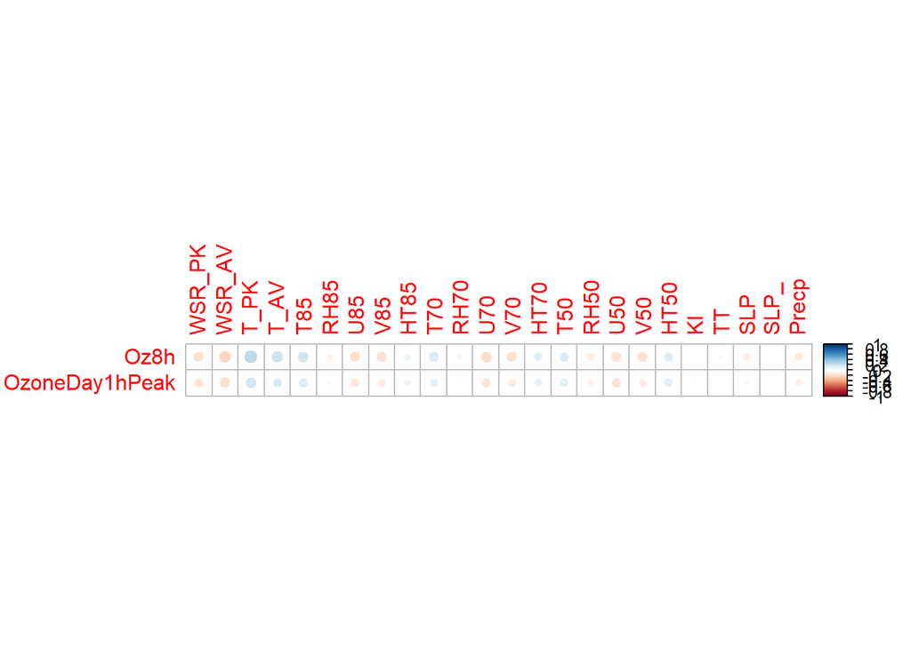

```r
corrplot(Oz_corr_to_dailydata)
```

Arriba podemos ver que la correlación general entre los clases de ozono alto, y los datos diarias, es débil por todos. La falta de un rango razonable de valores de correlación no nos informa ni de la importancia ni redundancia de cualquier dato diario, y por tanto, los conservaremos todos en la continuación.

Si hay unos que podemos considerar para quitar, podremos, por ejemplo, filtrar por correlaciones con valores dentro de (-0.05, 0.05). Eso criterio daría los candidatos:

- RH85, RH70, pero no RH50 (la humedad relativa a tres alturas)
- KI y TT (indicaciones de potencial de tormentas)
- SLP_ (la diferencia de la presión atmosférica desde el día anterior)

Guardamos los candidatos hasta que miramos correlaciones entre los atributos en el paso siguiente (Reduccíón de datos).

### 3.2.2 Contrastes de correlación: Datos diarios vs Ozono

Mirando los mismo datos, pero de punto de vista de un contraste (prueba estadística) de las mismas correlaciones, para determinar si podemos aceptar o rechazar una hipótesis nula, que especifica que las correlaciones individuales son cero. Usaremos corr.test() del paquete psych, con el método *Spearman** dado que los datos no son normales (aunque no les hemos visualizado todavía, no son).

```r
Oz_corr_to_dailydata.test <- corr.test(oz_classes_only, subset(data_tot, select=daily_data_columns_without_classes), use = "pairwise", method="spearman", adjust="holm", alpha=.05, ci=TRUE, minlength=5, normal=FALSE)

print(Oz_corr_to_dailydata.test, short=TRUE)
```

```
## Call:corr.test(x = oz_classes_only, y = subset(data_tot, select = daily_data_columns_without_classes),
##     use = "pairwise", method = "spearman", adjust = "holm", alpha = 0.05,
##     ci = TRUE, minlength = 5, normal = FALSE)
## Correlation matrix
##                WSR_PK WSR_AV T_PK T_AV  T85  RH85   U85   V85 HT85  T70  RH70
## Oz8h            -0.16  -0.21 0.26 0.21 0.18 -0.06 -0.17 -0.16 0.06 0.15 -0.05
## OzoneDay1hPeak  -0.13  -0.17 0.18 0.15 0.13 -0.04 -0.13 -0.09 0.06 0.11 -0.02
##                  U70   V70 HT70  T50  RH50   U50   V50 HT50   KI   TT   SLP
## Oz8h           -0.18 -0.16 0.12 0.15 -0.10 -0.17 -0.16 0.15 0.01 0.02 -0.10
## OzoneDay1hPeak -0.14 -0.10 0.11 0.11 -0.07 -0.14 -0.10 0.12 0.02 0.01 -0.05
##                 SLP_ Precp
## Oz8h            0.00 -0.12
## OzoneDay1hPeak -0.01 -0.09
## Sample Size
##                WSR_PK WSR_AV T_PK T_AV  T85 RH85  U85  V85 HT85  T70 RH70  U70
## Oz8h             2263   2263 2361 2361 2437 2431 2356 2356 2441 2429 2421 2379
## OzoneDay1hPeak   2263   2263 2361 2361 2437 2431 2356 2356 2441 2429 2421 2379
##                 V70 HT70  T50 RH50  U50  V50 HT50   KI   TT  SLP SLP_ Precp
## Oz8h           2379 2436 2421 2411 2326 2326 2424 2400 2411 2441 2377  2534
## OzoneDay1hPeak 2379 2436 2421 2411 2326 2326 2424 2400 2411 2441 2377  2534
## These are the unadjusted probability values.
##   The probability values  adjusted for multiple tests are in the p.adj object.
##                WSR_PK WSR_AV T_PK T_AV T85 RH85 U85 V85 HT85 T70 RH70 U70 V70
## Oz8h                0      0    0    0   0 0.00   0   0    0   0 0.01   0   0
## OzoneDay1hPeak      0      0    0    0   0 0.07   0   0    0   0 0.34   0   0
##                HT70 T50 RH50 U50 V50 HT50   KI   TT  SLP SLP_ Precp
## Oz8h              0   0    0   0   0    0 0.70 0.30 0.00 0.83     0
## OzoneDay1hPeak    0   0    0   0   0    0 0.33 0.49 0.02 0.58     0
##
##  To see confidence intervals of the correlations, print with the short=FALSE option
```

```r
Oz_corr_to_dailydata.test$p.adj
```

```
##                      WSR_PK       WSR_AV         T_PK         T_AV          T85
## Oz8h           1.682474e-13 6.311124e-23 1.087379e-35 7.798859e-23 8.003078e-18
## OzoneDay1hPeak 1.360243e-08 5.557783e-15 8.992779e-18 1.166637e-11 2.974026e-09
##                      RH85          U85          V85       HT85          T70
## Oz8h           0.02915783 3.730574e-15 2.699629e-13 0.02682067 1.367459e-12
## OzoneDay1hPeak 0.54491099 1.716762e-08 9.392840e-05 0.01751215 1.260603e-06
##                      RH70          U70          V70         HT70          T50
## Oz8h           0.07558955 1.457982e-17 2.804328e-14 1.835725e-08 1.984550e-11
## OzoneDay1hPeak 1.00000000 2.219023e-10 1.892618e-05 2.106986e-06 9.887086e-07
##                        RH50          U50          V50         HT50 KI TT
## Oz8h           1.296279e-05 1.033467e-14 1.172544e-12 1.044945e-11  1  1
## OzoneDay1hPeak 9.969251e-03 2.575105e-10 4.005708e-05 8.294522e-08  1  1
##                         SLP SLP_        Precp
## Oz8h           1.894499e-05    1 3.825807e-08
## OzoneDay1hPeak 1.480617e-01    1 1.653031e-04
```

El primer grupo de valores nos dan valores de correlación, los mismos que el paso anterior.

Los dos siguientes grupos son valores $p$ resultantes del contraste. Los contrastes prueba una hipotesis nula diciendo que la correlación es cero, y por tanto, las parejas donde hay un valor $p$ mayor que un nivel de significancia, por ejemplo 0.05 (5%), tenemos que *no rechazar* esa hipótesis. Eso se aplica para:

- RH85, SLP contra Ozono de 1h aguda
- RH70, KI, TT, SLP_ contra ambos Ozono

Por el resto, tiene valores $p$ muy pequeños y tenemos que rechazar el hipótesis y suponer que sí, hay una correlación significativa.

Eso confirma la sustracción de RH70, KI, TT, SLP_ al menos.

### 3.2.3 Cálculos de correlación: Datos horarios vs Ozono

Haremos lo mismo, para ver los datos horarios, separando las temperaturas y las velocidades del viento.

```r
# Prepare two name vectors to be able to subset the hourly variables
hourly_temps <- c("T0","T1","T2","T3","T4","T5","T6","T7","T8","T9","T10","T11","T12","T13","T14","T15","T16","T17","T18","T19","T20","T21","T22","T23")

hourly_wsrs <- c("WSR0","WSR1","WSR2","WSR3","WSR4","WSR5","WSR6","WSR7","WSR8","WSR9","WSR10","WSR11","WSR12","WSR13","WSR14","WSR15","WSR16","WSR17","WSR18","WSR19","WSR20","WSR21","WSR22","WSR23")

# Subset the hourly temperature variables without classes columns and perform correlation between them and the ozone classes.
Oz_corr_to_hourlytemps <- cor(oz_classes_only, subset(data_tot, select=hourly_temps), use = "pairwise.complete.obs", method="spearman")

Oz_corr_to_hourlytemps
```

```
##                       T0         T1        T2         T3         T4         T5
## Oz8h           0.1400865 0.12725736 0.1206351 0.11402155 0.10743379 0.10663579
## OzoneDay1hPeak 0.1018436 0.09272106 0.0875255 0.08200197 0.07782305 0.07788344
##                        T6        T7        T8        T9       T10       T11
## Oz8h           0.11107065 0.1442298 0.1779586 0.2039925 0.2245166 0.2417971
## OzoneDay1hPeak 0.08000093 0.1028467 0.1251062 0.1398469 0.1546397 0.1681963
##                      T12       T13       T14       T15       T16       T17
## Oz8h           0.2547611 0.2658304 0.2724684 0.2732716 0.2698635 0.2617411
## OzoneDay1hPeak 0.1782248 0.1872455 0.1914096 0.1943915 0.1908721 0.1830912
##                      T18       T19       T20       T21       T22       T23
## Oz8h           0.2462206 0.2317161 0.2176449 0.2056898 0.1938025 0.1804909
## OzoneDay1hPeak 0.1739948 0.1677716 0.1586420 0.1485027 0.1402919 0.1324837
```

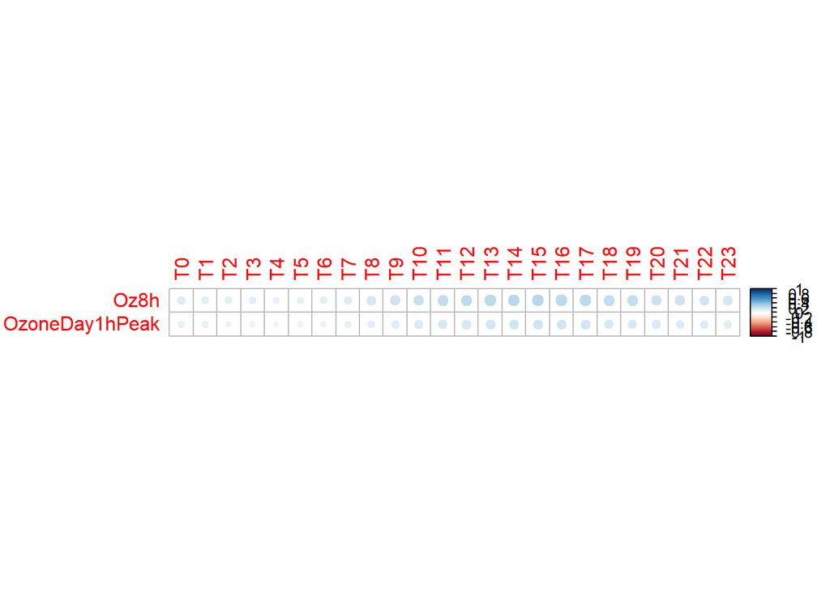

```r
corrplot(Oz_corr_to_hourlytemps)
```

y de nuevo para velocidades del viento, datos horarios:

```r
# Subset the hourly WSR variables without classes columns and perform correlation between them and the ozone classes.
Oz_corr_to_hourlyWSRs <- cor(oz_classes_only, subset(data_tot, select=hourly_wsrs), use = "pairwise.complete.obs", method="spearman")

Oz_corr_to_hourlyWSRs
```

```
##                      WSR0       WSR1       WSR2       WSR3       WSR4
## Oz8h           -0.2028840 -0.2027108 -0.2090380 -0.2018110 -0.1893132
## OzoneDay1hPeak -0.1371694 -0.1476909 -0.1545247 -0.1608243 -0.1467667
##                      WSR5       WSR6       WSR7       WSR8       WSR9
## Oz8h           -0.1808726 -0.1677448 -0.1300161 -0.1402486 -0.1933937
## OzoneDay1hPeak -0.1426154 -0.1459482 -0.1300380 -0.1539047 -0.1884510
##                     WSR10      WSR11      WSR12      WSR13      WSR14
## Oz8h           -0.2265341 -0.2307985 -0.2326949 -0.2086858 -0.1722945
## OzoneDay1hPeak -0.1991446 -0.1981324 -0.2044196 -0.1812443 -0.1493702
##                     WSR15       WSR16        WSR17         WSR18        WSR19
## Oz8h           -0.1324955 -0.08616082 -0.016068908 -0.0090245850 -0.033722407
## OzoneDay1hPeak -0.1047695 -0.05232107 -0.004693092  0.0001250585 -0.009150775
##                      WSR20       WSR21       WSR22       WSR23
## Oz8h           -0.05522913 -0.08940609 -0.10783982 -0.13041900
## OzoneDay1hPeak -0.02732860 -0.05602371 -0.07013075 -0.07792693
```

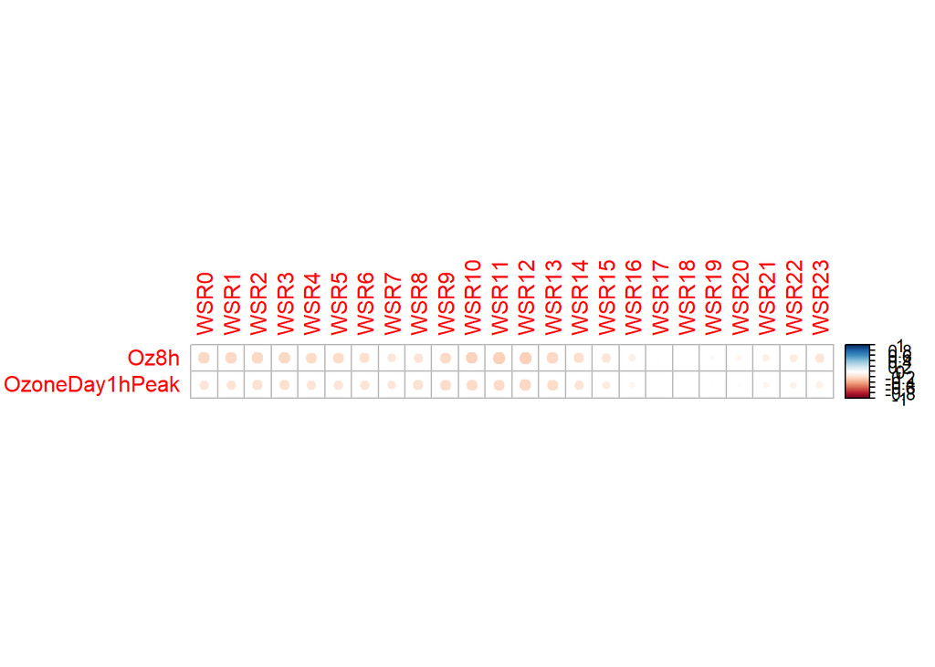

```r
corrplot(Oz_corr_to_hourlyWSRs)
```

Podríamos usar esos resultados para quitar unos, e.g. WSR17-WSR20, donde vemos correlaciones muy bajas, pero hay otra estrategia pensado para reducción de datos, que usara todos las medidas horarias.

No quitaremos los sobrantes, hasta después del siguiente paso.

## 3.3 Reducción de datos

Aquí estudiemos la posibilidad de que algunos atributos están redundantes entre sí, al menos al nivel de correlaciones. Por esos motivos, es irrelevante si tienen correlaciones con los clases, solo entre sí.

Notamos que solo se considera atributos diarios aquí.

```r
# Produce a correlation matrix of the daily attributes
daily_data_correlation <- cor(subset(data_tot, select=daily_data_columns_without_classes), use = "pairwise.complete.obs", method="spearman")

round(daily_data_correlation, 2)
```

```
##        WSR_PK WSR_AV  T_PK  T_AV   T85  RH85   U85   V85  HT85   T70  RH70
## WSR_PK   1.00   0.84 -0.19 -0.15 -0.13 -0.01  0.18  0.38 -0.22 -0.10 -0.06
## WSR_AV   0.84   1.00 -0.25 -0.18 -0.14  0.02  0.22  0.44 -0.24 -0.08 -0.04
## T_PK    -0.19  -0.25  1.00  0.98  0.87  0.18 -0.38  0.15  0.30  0.79  0.17
## T_AV    -0.15  -0.18  0.98  1.00  0.89  0.25 -0.39  0.24  0.30  0.81  0.23
## T85     -0.13  -0.14  0.87  0.89  1.00  0.19 -0.33  0.25  0.24  0.86  0.30
## RH85    -0.01   0.02  0.18  0.25  0.19  1.00 -0.06  0.31 -0.05  0.17  0.53
## U85      0.18   0.22 -0.38 -0.39 -0.33 -0.06  1.00  0.08 -0.43 -0.31 -0.12
## V85      0.38   0.44  0.15  0.24  0.25  0.31  0.08  1.00 -0.08  0.27  0.16
## HT85    -0.22  -0.24  0.30  0.30  0.24 -0.05 -0.43 -0.08  1.00  0.20  0.02
## T70     -0.10  -0.08  0.79  0.81  0.86  0.17 -0.31  0.27  0.20  1.00  0.01
## RH70    -0.06  -0.04  0.17  0.23  0.30  0.53 -0.12  0.16  0.02  0.01  1.00
## U70      0.21   0.26 -0.64 -0.64 -0.57 -0.12  0.79 -0.01 -0.49 -0.53 -0.11
## V70      0.32   0.38 -0.06  0.03  0.11  0.31  0.12  0.80 -0.17  0.12  0.22
## HT70    -0.24  -0.24  0.68  0.70  0.68  0.09 -0.50  0.09  0.84  0.64  0.14
## T50     -0.23  -0.23  0.78  0.80  0.82  0.26 -0.41  0.14  0.28  0.83  0.25
## RH50     0.04   0.06  0.05  0.11  0.17  0.36 -0.01  0.24 -0.01  0.06  0.53
## U50      0.23   0.29 -0.71 -0.72 -0.64 -0.14  0.65 -0.01 -0.48 -0.58 -0.18
## V50      0.21   0.26 -0.22 -0.15 -0.06  0.29  0.18  0.55 -0.26 -0.04  0.24
## HT50    -0.23  -0.23  0.81  0.83  0.83  0.17 -0.49  0.15  0.63  0.83  0.18
## KI      -0.07  -0.06  0.46  0.52  0.57  0.72 -0.18  0.29  0.08  0.31  0.87
## TT       0.03   0.05  0.37  0.42  0.44  0.77 -0.04  0.36 -0.03  0.27  0.53
## SLP     -0.09  -0.07 -0.43 -0.45 -0.53 -0.33 -0.06 -0.28  0.61 -0.45 -0.25
## SLP_    -0.17  -0.17 -0.10 -0.11 -0.07 -0.21 -0.08 -0.40  0.19 -0.08 -0.10
## Precp    0.10   0.07 -0.10 -0.04  0.04  0.36 -0.01  0.35 -0.09 -0.04  0.38
##          U70   V70  HT70   T50  RH50   U50   V50  HT50    KI    TT   SLP  SLP_
## WSR_PK  0.21  0.32 -0.24 -0.23  0.04  0.23  0.21 -0.23 -0.07  0.03 -0.09 -0.17
## WSR_AV  0.26  0.38 -0.24 -0.23  0.06  0.29  0.26 -0.23 -0.06  0.05 -0.07 -0.17
## T_PK   -0.64 -0.06  0.68  0.78  0.05 -0.71 -0.22  0.81  0.46  0.37 -0.43 -0.10
## T_AV   -0.64  0.03  0.70  0.80  0.11 -0.72 -0.15  0.83  0.52  0.42 -0.45 -0.11
## T85    -0.57  0.11  0.68  0.82  0.17 -0.64 -0.06  0.83  0.57  0.44 -0.53 -0.07
## RH85   -0.12  0.31  0.09  0.26  0.36 -0.14  0.29  0.17  0.72  0.77 -0.33 -0.21
## U85     0.79  0.12 -0.50 -0.41 -0.01  0.65  0.18 -0.49 -0.18 -0.04 -0.06 -0.08
## V85    -0.01  0.80  0.09  0.14  0.24 -0.01  0.55  0.15  0.29  0.36 -0.28 -0.40
## HT85   -0.49 -0.17  0.84  0.28 -0.01 -0.48 -0.26  0.63  0.08 -0.03  0.61  0.19
## T70    -0.53  0.12  0.64  0.83  0.06 -0.58 -0.04  0.83  0.31  0.27 -0.45 -0.08
## RH70   -0.11  0.22  0.14  0.25  0.53 -0.18  0.24  0.18  0.87  0.53 -0.25 -0.10
## U70     1.00  0.13 -0.68 -0.62 -0.01  0.89  0.25 -0.71 -0.29 -0.14  0.08  0.04
## V70     0.13  1.00 -0.06  0.06  0.26  0.13  0.79  0.01  0.26  0.29 -0.24 -0.26
## HT70   -0.68 -0.06  1.00  0.66  0.08 -0.71 -0.21  0.93  0.34  0.20  0.16  0.11
```

[output cut: 20 more lines]

```
## T70    -0.04
## RH70    0.38
## U70     0.03
## V70     0.39
## HT70   -0.05
## T50     0.02
## RH50    0.32
## U50     0.04
## V50     0.38
## HT50   -0.03
## KI      0.37
## TT      0.32
## SLP    -0.15
## SLP_   -0.18
## Precp   1.00
```

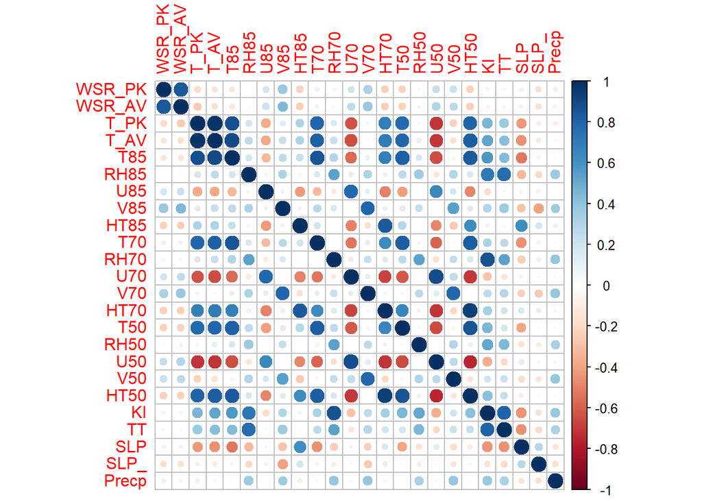

```r
corrplot(daily_data_correlation)
```

Revisamos los puntos de interés aquí:

Entonces, las verificaciones por correlaciones con días de ozono ha producido esos como candidatos a quitar por irrelevancia:

- RH85, RH70, pero no RH50 (la humedad relativa a tres alturas)
- KI y TT (indicaciones de potencial de tormentas)
- SLP_ (la diferencia de la presión atmosférica desde el día anterior)

El contraste de correlación ha confirmado la irrelevancia de: * RH70, KI, TT, SLP_

### 3.3.1 Investigación: SLP

Como que SLP mostraba algo de correlación con Ozono, haremos algunos pruebas antes de elegir definitivamente si quitarlo.

Primero, visualización comparado a Ozono de 8h, con cúal tenía más correlación:

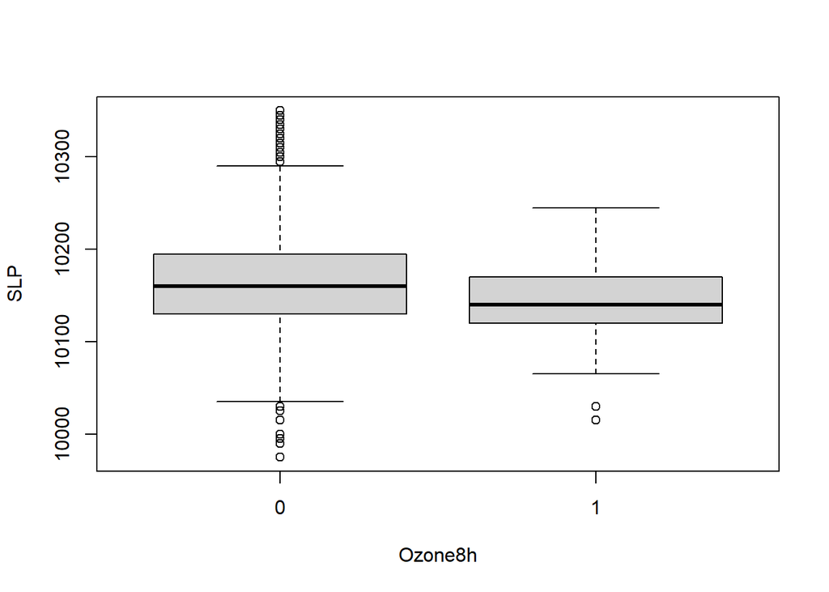

```r
plot(as.factor(data_tot$Oz8h), data_tot$SLP, ylab="SLP", xlab="Ozone8h")
```

Da la impresión de tener una media del SLP diferente por días de ozono 8h.

Contrastamos con una prueba de la media de los dos subconjuntos, uno casos de Ozono8h, y el otro sin ozono alto. Notamos que estaremos tratando medidas del valor medio de SLP, y se puede aplicar el teorem central de limite, como que tenemos muestras con cantidades grandes. El menos es el de Ozono8h, y tiene 160 casos.

```r
SLP_Oz8h <- data_tot$SLP[data_tot$Oz8h == 1]
SLP_not_Oz8h <- data_tot$SLP[data_tot$Oz8h == 0]

t.test(SLP_not_Oz8h, SLP_Oz8h, alternative = "two.sided", var.equal = FALSE, conf.level = 0.95)
```

```
##
##  Welch Two Sample t-test
##
## data:  SLP_not_Oz8h and SLP_Oz8h
## t = 6.5482, df = 200.97, p-value = 4.764e-10
## alternative hypothesis: true difference in means is not equal to 0
## 95 percent confidence interval:
##  14.68314 27.33620
## sample estimates:
## mean of x mean of y
##  10165.53  10144.52
```

Según la prueba, la diferencia de la media de SLP está significativa, entre días de Ozono 8h y no. Eso nos indica que puede ser que tiene suficientemente información para quedar con el atributo.

### 3.3.2 Investigación: uso de HT85, HT70, y HT50, o T85, T70, T50

En las pruebas de correlación de los atributos contra las clases de ozono, se puede constatar que los Txx daban mayor correlación generalmente que los HTxx. Eso indica una preferencia de quedar con los Txx y quitar los HTxx.

Podremos intentar comparar un modelo de regresión usando los Txx con uno usando los HTxx:

```r
Oz8h_Txx_regr <- glm(Oz8h ~ T85 + T70 + T50, data_tot, family = "binomial")
summary(Oz8h_Txx_regr)
```

```
##
## Call:
## glm(formula = Oz8h ~ T85 + T70 + T50, family = "binomial", data = data_tot)
##
## Deviance Residuals:
##     Min       1Q   Median       3Q      Max
## -0.8658  -0.4362  -0.2997  -0.1946   2.9453
##
## Coefficients:
##             Estimate Std. Error z value Pr(>|z|)
## (Intercept) -5.85507    0.87864  -6.664 2.67e-11 ***
## T85          0.24844    0.04473   5.554 2.79e-08 ***
## T70         -0.07456    0.05772  -1.292    0.196
## T50          0.01192    0.04279   0.279    0.781
## ---
## Signif. codes:  0 '***' 0.001 '**' 0.01 '*' 0.05 '.' 0.1 ' ' 1
##
## (Dispersion parameter for binomial family taken to be 1)
##
##     Null deviance: 1139.7  on 2409  degrees of freedom
## Residual deviance: 1046.6  on 2406  degrees of freedom
##   (126 observations deleted due to missingness)
## AIC: 1054.6
##
## Number of Fisher Scoring iterations: 6
```

```r
Oz8h_HTxx_regr <- glm(Oz8h ~ HT85 + HT70 + HT50, data_tot, family = "binomial")
summary(Oz8h_HTxx_regr)
```

```
##
## Call:
## glm(formula = Oz8h ~ HT85 + HT70 + HT50, family = "binomial",
##     data = data_tot)
##
## Deviance Residuals:
##     Min       1Q   Median       3Q      Max
## -0.7507  -0.4292  -0.3248  -0.2145   3.1008
##
## Coefficients:
##               Estimate Std. Error z value Pr(>|z|)
## (Intercept) -59.975339   8.783462  -6.828  8.6e-12 ***
## HT85         -0.031568   0.009646  -3.273  0.00107 **
## HT70          0.039147   0.015169   2.581  0.00986 **
## HT50         -0.003055   0.006304  -0.485  0.62797
## ---
## Signif. codes:  0 '***' 0.001 '**' 0.01 '*' 0.05 '.' 0.1 ' ' 1
##
## (Dispersion parameter for binomial family taken to be 1)
##
##     Null deviance: 1146.9  on 2423  degrees of freedom
## Residual deviance: 1076.8  on 2420  degrees of freedom
##   (112 observations deleted due to missingness)
## AIC: 1084.8
##
## Number of Fisher Scoring iterations: 6
```

Los resultados son interesantes:

- Las medias y varianzas de los residuos del modelo Txx son ligeramente mejores
- Los criterios AIC son un poco mejor en el modelo Txx
- El modelo Txx tiene coeficientes significativos con la intersección y T85 (la del altitud mas baja), mientras que el modelo HTxx tiene ademas un coeficiente significativo con el segundo independiente, HT70. Pero, el coeficiente de HT85 es un grado menos significativo, entre 0.01 y 0.001, mientras que el coeficiente de T85 tiene valor p menor que 0.001, por decir más seguro de no estar cero.

Aunque las diferencias no son muy grandes, mantiene la impresión de que sería mejor quedar con los Txx. Eso dicho, podemos también elegir descartar HT70 y HT50 si HT85 nos mejora el modelo. Probamos:

```r
Oz8h_Txx_HT85_regr <- glm(Oz8h ~ T85 + T70 + T50 + HT85, data_tot, family = "binomial")
summary(Oz8h_Txx_HT85_regr)
```

```
##
## Call:
## glm(formula = Oz8h ~ T85 + T70 + T50 + HT85, family = "binomial",
##     data = data_tot)
##
## Deviance Residuals:
##     Min       1Q   Median       3Q      Max
## -0.8286  -0.4329  -0.3017  -0.1938   2.9346
##
## Coefficients:
##              Estimate Std. Error z value Pr(>|z|)
## (Intercept) -9.309064   4.436762  -2.098   0.0359 *
## T85          0.244913   0.044900   5.455 4.91e-08 ***
## T70         -0.068807   0.058289  -1.180   0.2378
## T50          0.004424   0.044105   0.100   0.9201
## HT85         0.002212   0.002782   0.795   0.4265
## ---
## Signif. codes:  0 '***' 0.001 '**' 0.01 '*' 0.05 '.' 0.1 ' ' 1
##
## (Dispersion parameter for binomial family taken to be 1)
##
##     Null deviance: 1139.7  on 2409  degrees of freedom
## Residual deviance: 1045.9  on 2405  degrees of freedom
##   (126 observations deleted due to missingness)
## AIC: 1055.9
##
## Number of Fisher Scoring iterations: 6
```

### 3.3.3 Sustracción de T_AV, RH70, KI, TT, SLP_

Terminamos el apartado de Selección quitando los atributos identificados como candidatos confirmados:

- RH70 (la humedad relativa de la altura media)
- KI y TT (indicaciones de potencial de tormentas)
- SLP_ (la diferencia de la presión atmosférica desde el día anterior)
- T_AV
- HT85, HT70, y HT50

```r
data_reduced <- subset(data_tot, select= -c(RH70, KI, TT, SLP_, T_AV, HT85, HT70, HT50))
```

En adelante, usaremos el dataframe **data_reduced**.

## 3.4 Conversión

Aquí tenemos dos iniciativas:

- la normalización de los datos en una escala tipo rango (0,1)
- la transformación de los datos horarias en vectores agrupados en *clusters*

### 3.4.1 Verificación por valores extremos - Outliers

Antes de normalizar los datos, haremos un repaso para confirmar que no hay datos no razonables en el conjunto.

Para poder hacer gráficos de los datos de temperatura y velocidad del viento cada hora, funciona mejor si les convertimos en forma “tidy”. Una serie de temperaturas cada hora al final es una combinación de dos variables: temperatura y hora. También, para que ggplot les trata en el orden correcto, hay que convertir la “hora” en “factor” con sus niveles, sino ggplot coge los x en orden alfabético.

```r
# Use tidyverse to pivot WSR and T data such that we have only columns Date, Time, Temp (or WSR)

# Separate out WSR and Temp hourly data into separate files, along with Date column for each.
WSRdata <- data_reduced[1:25]
Tdata <- cbind(data_reduced[1],data_reduced[28:51])

# Create name vectors for the hourly values to provide to pivot_longer
WSRs <- c("WSR0","WSR1","WSR2","WSR3","WSR4","WSR5","WSR6","WSR7","WSR8","WSR9","WSR10","WSR11","WSR12","WSR13","WSR14","WSR15","WSR16","WSR17","WSR18","WSR19","WSR20","WSR21","WSR22","WSR23")

Ts <- c("T0","T1","T2","T3","T4","T5","T6","T7","T8","T9","T10","T11","T12","T13","T14","T15","T16","T17","T18","T19","T20","T21","T22","T23")


# Pivot tables into tidy versions with only 3 columns each.
WSRtidy <- WSRdata %>%
  pivot_longer(all_of(WSRs), names_to = "HourofDay", values_to = "WindSpeed")

Ttidy <- Tdata %>%
  pivot_longer(all_of(Ts), names_to = "HourofDay", values_to = "Temperature")

WSRtidy$HourofDay <- factor(WSRtidy$HourofDay, levels = WSRs)
Ttidy$HourofDay <- factor(Ttidy$HourofDay, levels = Ts)
```

Así, para poder visualizar los valores cada hora, hemos hecho una transformación a los datos de velocidad del viento y temperatura de cada hora. Con esos cambios, hemos hecho primero unas tablas especificas para cada tipo de medida, de Fecha mas las 24 columnas para cada hora. Entendemos que todos esos medidas en principio son la misma variable, y se pueden concatenar todas en la misma columna si modulemos los datos con la hora del dia.

La función pivot_longer() hace exactamente eso, para que podemos ahora producir gráficos que podemos apreciar mejor.

En los gráficos tipo violin, podemos ver el extenso de esos datos y apreciar que son todos razonables.

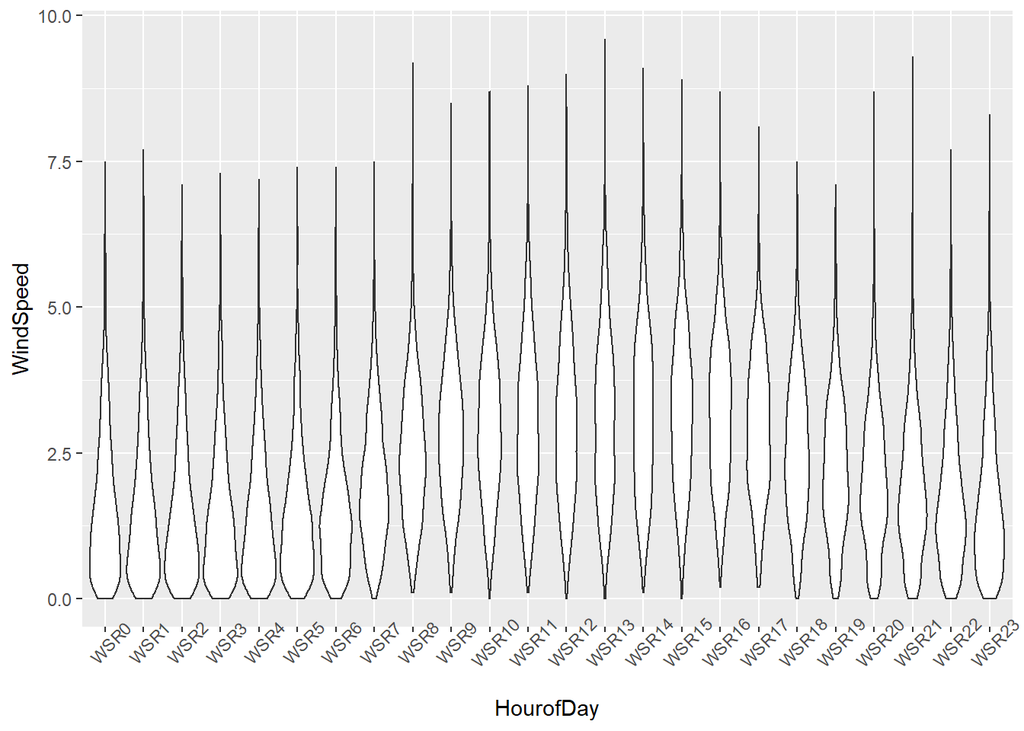

```r
ggplot(WSRtidy, aes(x=HourofDay,y=WindSpeed)) + geom_violin() + geom_smooth(fullrange=TRUE) + theme(axis.text.x = element_text(angle=45))
```

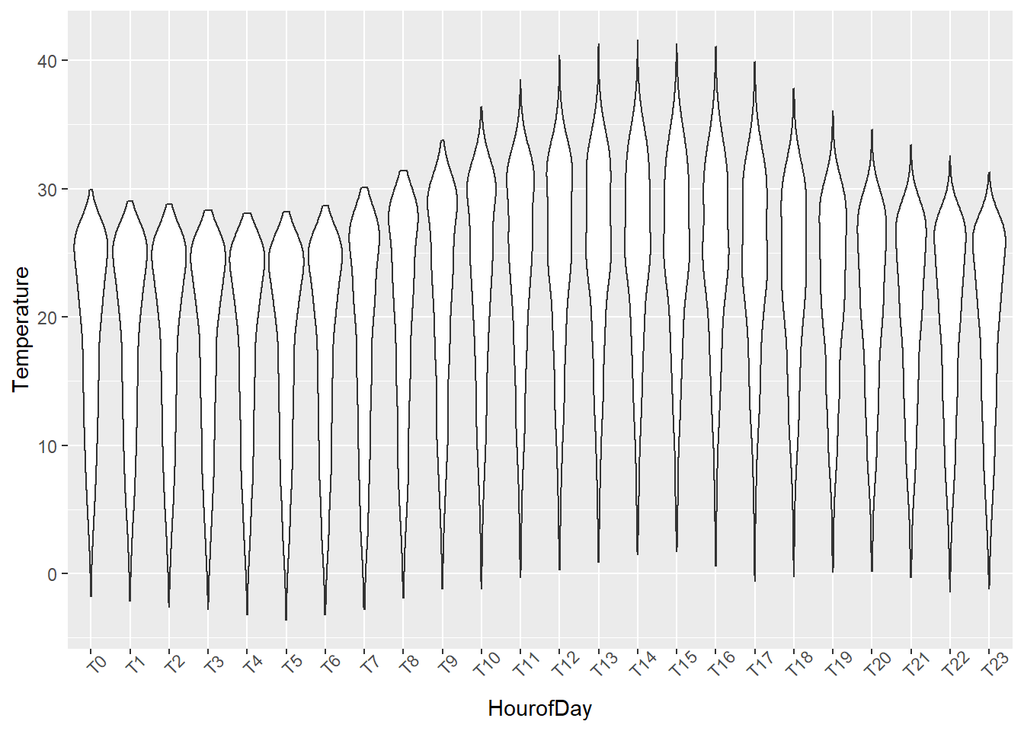

```r
ggplot(Ttidy, aes(x=HourofDay,y=Temperature)) + geom_violin() + geom_smooth(fullrange=TRUE) + theme(axis.text.x = element_text(angle=45))
```

En cuanto al resto de los datos, vamos en partes.

Como se puede ver en los boxplots abajo, todos los valores quedan dentro de un rango razonable para esos atributos físicos, si no consideramos los NA.

Incluso los valores de SLP, la presión atmosférica, si entendemos que falta el punto decimal para que sean en mbar / hPa. [Ref. 10], y los valores de precipitación, se supone en mm, cuadran con los rangos descritos en [Ref. 11]. Allí describan el mes más lluvioso como junio, con lluvia mensual media de 151mm, cosa que hace un máximo de 21mm aquí muy plausible.

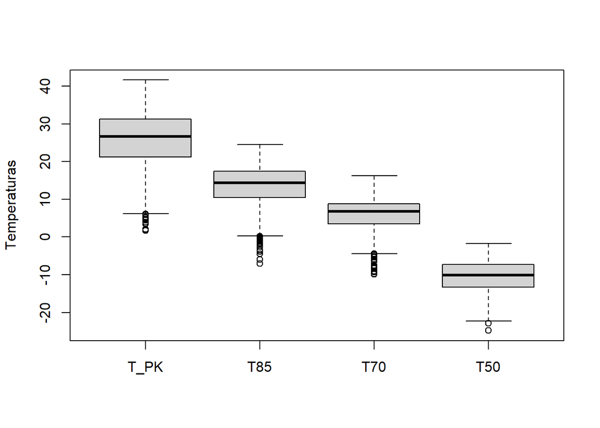

```r
boxplot(subset(data_reduced, select = c(T_PK, T85, T70, T50)), ylab = "Temperaturas")
```

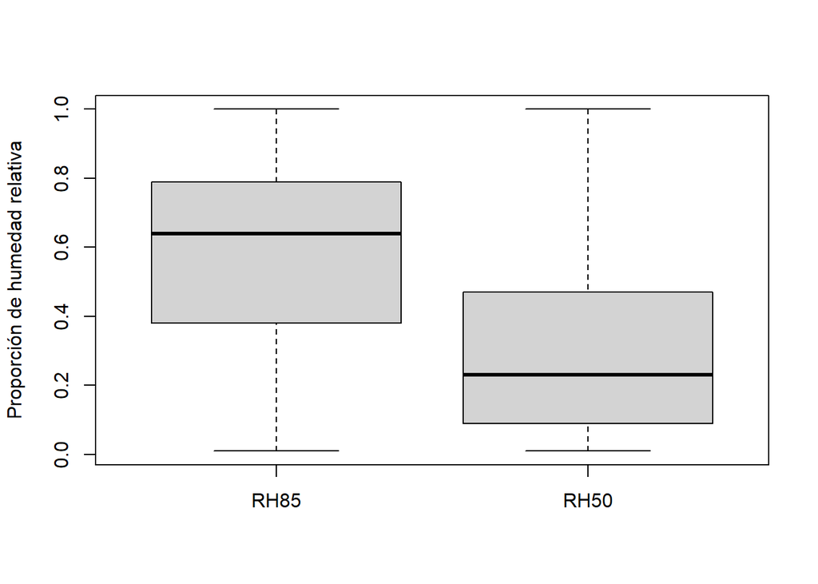

```r
boxplot(subset(data_reduced, select = c(RH85, RH50)), ylab = "Proporción de humedad relativa")
```

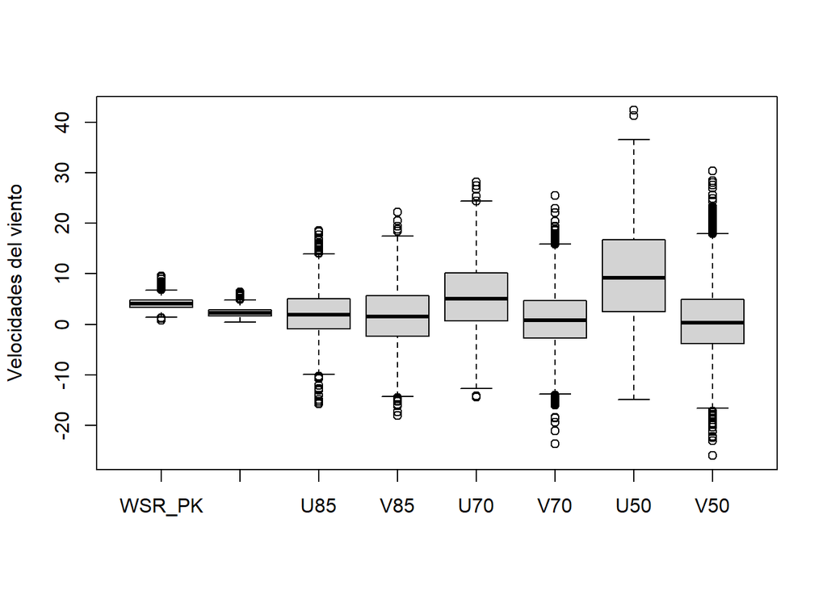

```r
boxplot(subset(data_reduced, select = c(WSR_PK, WSR_AV, U85, V85, U70, V70, U50, V50)), ylab = "Velocidades del viento")
```

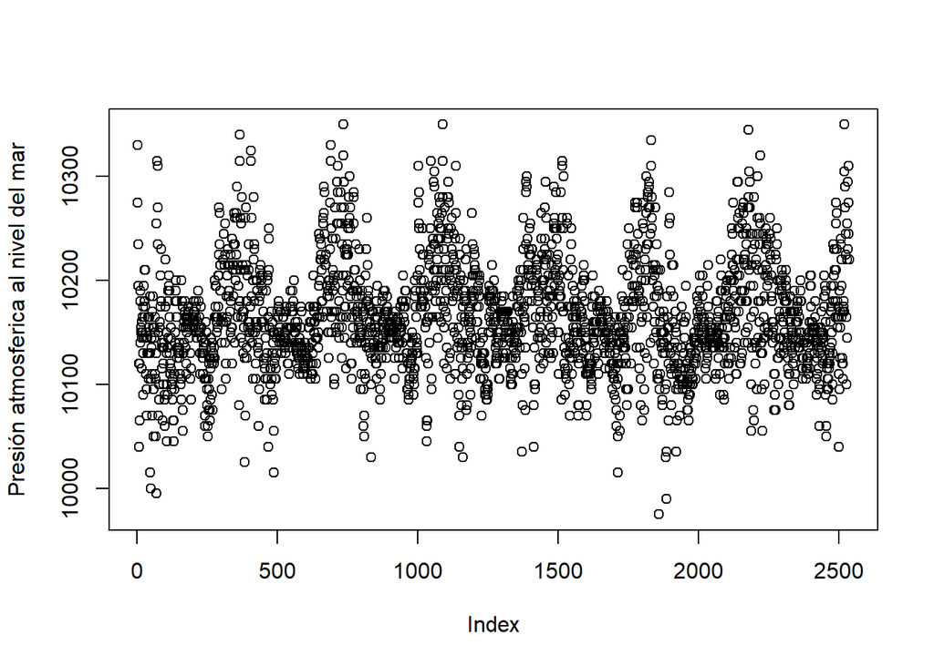

```r
plot(data_reduced$SLP, ylab="Presión atmosferica al nivel del mar")
```

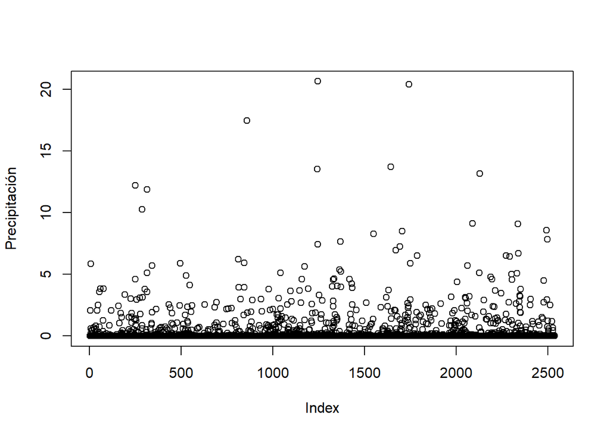

```r
plot(data_reduced$Precp, ylab="Precipitación")
```

Es correcto que en otros circunstancias, se podría considerar la eliminación de unos valores razonables pero extremos para mejorar el análisis, pero en nuestro contexto no hay motivo. Nuestros datos tienen eventos de interés que son poco frecuentes, y atributos poco frecuentes en los datos podrían incluso ayudar a la predicción de los días de ozono. Entonces dejamos todos en el conjunto de datos sin filtración. No obstante, hay valores perdidos, que trataremos posteriormente.

### 3.4.2 Normalización de datos

Los datos nuestros no son normales, y por tanto no tiene sentido considerar normalización z-score, pero no hay problema hacer normalización tipo min-max. Incluso es necesario hacerlo, por evitar problemas con la escala muy distinta de los atributos varios, e.g. 10k para SLP y por debajo de 1 para otros.

Por partes:

- los valores WSR0-23, WSR_AV, WSR_PK pueden ser normalizados todos en un escala común, con un mínimo natural de cero, hasta un máximo de 10, mapeado a 1 normalizado. El máximo actual es 9.6.
- los valores T0-23, T_PK pueden ser normalizados todos en un escala común, con un mínimo de -5 mapeado a cero, hasta un máximo de 45, mapeado a 1 normalizado. El mínimo actual es -3, y el máximo actual es 41.5.

Por la transformación en vectores, es importante que esos valores horarios se encuentran en la misma escala.

Siguiendo:

- los valores T85, T70, T50 tienen rangos de valores que no solapan bien, pero tampoco no es necesario igualar un valor de T85 contra un valor de T70, por ejemplo. Entonces podemos usar una normalización (0,1) individual para cada uno. No es importante mantener el aspecto negativo-positivo.
- los valores RHxx son ya en rango (0,1) por su naturaleza.
- SLP y Precp pueden ser normalizados individualmente en un rango (0,1).
- los valores direccionales del viento Uxx, Vxx, necesitan una normalización que mantengan su signo y su escala comparado a cero, por ser una dirección además de una velocidad. Son componentes de un vector. Tienen máximos actuales de +42 y mínimos de -26. Una transformación dividiendo por 50 les dejaran en un rango de (-0.52, 0.84).

WSR0-23, AV, PK:

```r
# Map WSRxx values to (0,1) from original (0,10), so divide by 10
div10 <- function(wsr) {
  return (wsr/10)
}

# copy reduced data into data_norm to continue
data_norm <- data_reduced

for (xx in (0:23)) {
  data_norm[[glue("WSR{xx}")]] <- sapply(eval(parse(text = glue("data_reduced$WSR{xx}"))), div10)
}

data_norm$WSR_AV <- sapply(data_reduced$WSR_AV, div10)
data_norm$WSR_PK <- sapply(data_reduced$WSR_PK, div10)
```

T0-23, PK:

```r
# Scale -5 to zero, up to 45 scale to 1
temp_norm <- function(t) {
  return ( (t+5)/50 )
}

for (xx in (0:23)) {
  data_norm[[glue("T{xx}")]] <- sapply(eval(parse(text = glue("data_reduced$T{xx}"))), temp_norm)
}

data_norm$T_PK <- sapply(data_reduced$T_PK, temp_norm)
```

Ahora tenemos los datos normalizados en **datos_norm** en adelante.

T85, T70, T50, SLP y Precp:

```r
# Scale (min,max) to (0,1)
min.max.norm <- function(x, min.x, max.x) {
  return ( (x-min.x) / (max.x-min.x))
}

data_norm$T85 <- sapply(data_reduced$T85, min.max.norm, min(data_reduced$T85, na.rm = TRUE), max(data_reduced$T85, na.rm = TRUE))
data_norm$T70 <- sapply(data_reduced$T70, min.max.norm, min(data_reduced$T70, na.rm = TRUE), max(data_reduced$T70, na.rm = TRUE))
data_norm$T50 <- sapply(data_reduced$T50, min.max.norm, min(data_reduced$T50, na.rm = TRUE), max(data_reduced$T50, na.rm = TRUE))

data_norm$SLP <- sapply(data_reduced$SLP, min.max.norm, min(data_reduced$SLP, na.rm = TRUE), max(data_reduced$SLP, na.rm = TRUE))

data_norm$Precp <- sapply(data_reduced$Precp, min.max.norm, min(data_reduced$Precp, na.rm = TRUE), max(data_reduced$Precp, na.rm = TRUE))
```

Uxx, Vxx:

```r
# Map U,Vxx values to approx (-0.52, 0.84) from original, dividing by 50
div50 <- function(wsr) {
  return (wsr/50)
}

data_norm$U85 <- sapply(data_reduced$U85, div50)
data_norm$U70 <- sapply(data_reduced$U70, div50)
data_norm$U50 <- sapply(data_reduced$U50, div50)

data_norm$V85 <- sapply(data_reduced$V85, div50)
data_norm$V70 <- sapply(data_reduced$V70, div50)
data_norm$V50 <- sapply(data_reduced$V50, div50)
```

Confirmamos que tenemos todo normalizado en **data_norm**:

```r
summary(data_norm)
```

```
##       DATE                 WSR0             WSR1             WSR2
##  Min.   :1998-01-01   Min.   :0.0000   Min.   :0.0000   Min.   :0.0000
##  1st Qu.:1999-10-06   1st Qu.:0.0600   1st Qu.:0.0600   1st Qu.:0.0600
##  Median :2001-07-02   Median :0.1300   Median :0.1300   Median :0.1200
##  Mean   :2001-07-03   Mean   :0.1641   Mean   :0.1587   Mean   :0.1547
##  3rd Qu.:2003-04-06   3rd Qu.:0.2400   3rd Qu.:0.2300   3rd Qu.:0.2200
##  Max.   :2004-12-31   Max.   :0.7500   Max.   :0.7700   Max.   :0.7100
##                       NA's   :299      NA's   :292      NA's   :294
##       WSR3             WSR4             WSR5             WSR6
##  Min.   :0.0000   Min.   :0.0000   Min.   :0.0000   Min.   :0.0000
##  1st Qu.:0.0600   1st Qu.:0.0600   1st Qu.:0.0700   1st Qu.:0.0800
##  Median :0.1300   Median :0.1300   Median :0.1300   Median :0.1400
##  Mean   :0.1527   Mean   :0.1523   Mean   :0.1543   Mean   :0.1638
##  3rd Qu.:0.2200   3rd Qu.:0.2200   3rd Qu.:0.2100   3rd Qu.:0.2200
##  Max.   :0.7300   Max.   :0.7200   Max.   :0.7400   Max.   :0.7400
##  NA's   :292      NA's   :293      NA's   :292      NA's   :291
##       WSR7             WSR8            WSR9            WSR10
##  Min.   :0.0000   Min.   :0.010   Min.   :0.0100   Min.   :0.0000
##  1st Qu.:0.1200   1st Qu.:0.170   1st Qu.:0.2000   1st Qu.:0.2100
##  Median :0.1900   Median :0.250   Median :0.2800   Median :0.2900
##  Mean   :0.2048   Mean   :0.254   Mean   :0.2849   Mean   :0.2971
##  3rd Qu.:0.2800   3rd Qu.:0.330   3rd Qu.:0.3700   3rd Qu.:0.3800
##  Max.   :0.7500   Max.   :0.920   Max.   :0.8500   Max.   :0.8700
##  NA's   :289      NA's   :290     NA's   :287      NA's   :288
##      WSR11            WSR12            WSR13            WSR14
##  Min.   :0.0100   Min.   :0.0000   Min.   :0.0000   Min.   :0.0100
##  1st Qu.:0.2000   1st Qu.:0.2000   1st Qu.:0.2000   1st Qu.:0.2100
##  Median :0.2900   Median :0.3000   Median :0.3000   Median :0.3100
##  Mean   :0.3017   Mean   :0.3045   Mean   :0.3108   Mean   :0.3178
##  3rd Qu.:0.3900   3rd Qu.:0.4000   3rd Qu.:0.4100   3rd Qu.:0.4200
##  Max.   :0.8800   Max.   :0.9000   Max.   :0.9600   Max.   :0.9100
##  NA's   :292      NA's   :287      NA's   :288      NA's   :288
##      WSR15            WSR16            WSR17            WSR18
##  Min.   :0.0000   Min.   :0.0200   Min.   :0.0200   Min.   :0.0000
##  1st Qu.:0.2200   1st Qu.:0.2200   1st Qu.:0.2100   1st Qu.:0.1700
##  Median :0.3200   Median :0.3200   Median :0.2900   Median :0.2500
##  Mean   :0.3232   Mean   :0.3194   Mean   :0.2936   Mean   :0.2563
##  3rd Qu.:0.4200   3rd Qu.:0.4100   3rd Qu.:0.3800   3rd Qu.:0.3400
##  Max.   :0.8900   Max.   :0.8700   Max.   :0.8100   Max.   :0.7500
##  NA's   :286      NA's   :284      NA's   :283      NA's   :286
```

[output cut: 81 more lines]

```
##  Min.   :0.0100   Min.   :-0.2984   Min.   :-0.51980   Min.   :0.0000
##  1st Qu.:0.0900   1st Qu.: 0.0492   1st Qu.:-0.07570   1st Qu.:0.4133
##  Median :0.2300   Median : 0.1845   Median : 0.00720   Median :0.4933
##  Mean   :0.3047   Mean   : 0.1973   Mean   : 0.01664   Mean   :0.5045
##  3rd Qu.:0.4700   3rd Qu.: 0.3342   3rd Qu.: 0.09765   3rd Qu.:0.5867
##  Max.   :1.0000   Max.   : 0.8472   Max.   : 0.60840   Max.   :1.0000
##  NA's   :125      NA's   :210       NA's   :210        NA's   :95
##      Precp          OzoneDay1hPeak         Oz8h
##  Min.   :0.000000   Min.   :0.00000   Min.   :0.00000
##  1st Qu.:0.000000   1st Qu.:0.00000   1st Qu.:0.00000
##  Median :0.000000   Median :0.00000   Median :0.00000
##  Mean   :0.018002   Mean   :0.02879   Mean   :0.06309
##  3rd Qu.:0.002421   3rd Qu.:0.00000   3rd Qu.:0.00000
##  Max.   :1.000000   Max.   :1.00000   Max.   :1.00000
##  NA's   :2
```

### 3.4.3 Conversión de datos horarios en vectores agrupados

La iniciativa mayor de reducción de datos bajo consideración es la conversión de las secuencias de datos horarios en vectores clasificados, si es posible. Eso significaría la reducción de 48 datos diarios en 2 datos transformados.

Tenemos unas propuestas de algoritmos para clasificar los vectores, que investigaremos a continuación:

- K-medoids usando PAM
- Model-based clustering usando mclust
- Density-based clustering usando dbscan
- Support-vector machine clustering (el unico supervisado)

#### 3.4.3.1 Investigación: clasificando vectores de temperaturas con PAM (no supervisado)

```r
T_clusters <- pamk(na.omit(data_norm[28:51]), krange = 2:10, criterion = "ch", usepam = TRUE)
```

```r
head(T_clusters$pamobject)
```

```
## $medoids
##        T0    T1    T2    T3    T4    T5    T6   T7    T8    T9   T10   T11
## 752 0.304 0.290 0.278 0.264 0.258 0.260 0.260 0.26 0.276 0.298 0.326 0.348
## 84  0.452 0.448 0.438 0.438 0.438 0.438 0.448 0.47 0.498 0.518 0.554 0.578
## 514 0.604 0.596 0.590 0.584 0.584 0.578 0.598 0.63 0.648 0.666 0.686 0.692
##       T12   T13   T14   T15   T16   T17   T18   T19   T20   T21   T22   T23
## 752 0.364 0.372 0.376 0.378 0.372 0.362 0.348 0.332 0.314 0.316 0.316 0.314
## 84  0.588 0.588 0.588 0.580 0.566 0.552 0.528 0.512 0.496 0.490 0.492 0.502
## 514 0.718 0.722 0.722 0.724 0.712 0.696 0.674 0.648 0.628 0.618 0.612 0.608
##
## $id.med
## [1] 732  84 504
##
## $clustering
##    1    2    3    4    5    6    7    8    9   10   11   12   13   14   15   16
```

[output cut: 300 more lines]

```r
head(T_clusters$crit)
```

```
## [1]    0.000 4540.254 4806.942 4399.370 4191.835 3827.166
```

El algoritmo ha agrupado nuestros vectores diarias en 3 grupos.

Para visualizar la asignación de clusters, pero solo en dos dimensiones, usando una pareja aleatoria de Txx:

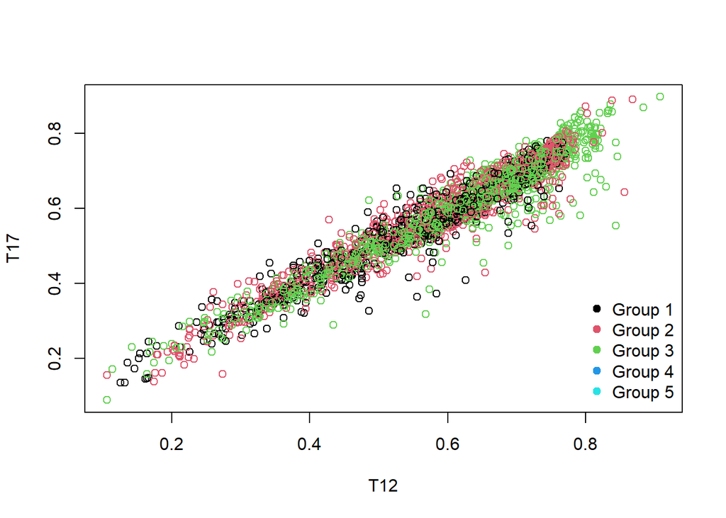

```r
plot(data_norm[c(40,45)], col = T_clusters$pamobject$clustering)

# below assumes 5 groups, needs fixing to check how many.  Seems to have given 3
legend("bottomright", legend = paste("Group", 1:5), col = 1:5, pch = 19, bty = "n")
```

Para poder hacer gráficos de los datos de temperatura y velocidad del viento cada hora, funciona mejor si convertimos eso datos en forma “tidy”, como que una serie de temperaturas cada hora es una combinación de dos variables: temperatura y hora. También, para que ggplot les trata en el orden correcto, hay que convertir la “hora” en “factor” con sus niveles, sino ggplot coge los x en orden alfabético.

Visualizando los vectores “medoid”, resultado del clustering PAM:

```r
medoids_Txx <- as.data.frame(T_clusters$pamobject$medoids)
medoids_Txx
```

```
##        T0    T1    T2    T3    T4    T5    T6   T7    T8    T9   T10   T11
## 752 0.304 0.290 0.278 0.264 0.258 0.260 0.260 0.26 0.276 0.298 0.326 0.348
## 84  0.452 0.448 0.438 0.438 0.438 0.438 0.448 0.47 0.498 0.518 0.554 0.578
## 514 0.604 0.596 0.590 0.584 0.584 0.578 0.598 0.63 0.648 0.666 0.686 0.692
##       T12   T13   T14   T15   T16   T17   T18   T19   T20   T21   T22   T23
## 752 0.364 0.372 0.376 0.378 0.372 0.362 0.348 0.332 0.314 0.316 0.316 0.314
## 84  0.588 0.588 0.588 0.580 0.566 0.552 0.528 0.512 0.496 0.490 0.492 0.502
## 514 0.718 0.722 0.722 0.724 0.712 0.696 0.674 0.648 0.628 0.618 0.612 0.608
```

```r
# Use tidyverse to pivot WSR and T data such that we have only columns Time, Temp (or WSR)


# Create name vectors for the hourly values to provide to pivot_longer
WSRs <- c("WSR0","WSR1","WSR2","WSR3","WSR4","WSR5","WSR6","WSR7","WSR8","WSR9","WSR10","WSR11","WSR12","WSR13","WSR14","WSR15","WSR16","WSR17","WSR18","WSR19","WSR20","WSR21","WSR22","WSR23")

Ts <- c("T0","T1","T2","T3","T4","T5","T6","T7","T8","T9","T10","T11","T12","T13","T14","T15","T16","T17","T18","T19","T20","T21","T22","T23")


# Pivot table into tidy versions with only 2 columns.
#WSRtidy <- WSRdata %>%
#  pivot_longer(all_of(WSRs), names_to = "HourofDay", values_to = "WindSpeed")

# First make the Cluster quantity values explicit as column, and add cluster number
medoids_Txx <- cbind(cluster=c(1,2,3),cluster_quantity=(rownames(medoids_Txx)), medoids_Txx)

medoids_Txx_Tidy <- medoids_Txx %>%
  pivot_longer(all_of(Ts), names_to = "HourofDay", values_to = "Temperature", )

#WSRtidy$HourofDay <- factor(WSRtidy$HourofDay, levels = WSRs)
medoids_Txx_Tidy$HourofDay <- factor(medoids_Txx_Tidy$HourofDay, levels = Ts)
medoids_Txx_Tidy$cluster <- factor(medoids_Txx_Tidy$cluster)
```

Así, para poder visualizar los valores cada hora, hemos hecho una transformación a los datos de velocidad del viento y temperatura de cada hora. Con esos cambios, hemos hecho primero unas tablas especificas para cada tipo de medida, de Fecha mas las 24 columnas para cada hora. Entendemos que todos esos medidas en principio son el mismo variable, y se pueden concatenar todos en la misma columna si modulemos los datos con la hora del día.

La función pivot_longer() hace exactamente eso, para que podemos ahora producir gráficos que podemos apreciar mejor.

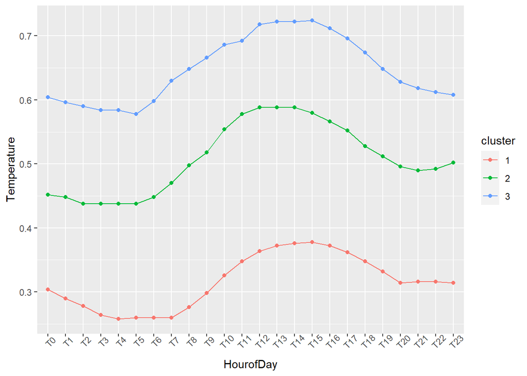

```r
ggplot(as.data.frame(medoids_Txx_Tidy), aes(x=HourofDay, y=Temperature, group=cluster)) + geom_point(aes(col=cluster)) + geom_line(aes(col=cluster)) + theme(axis.text.x = element_text(angle=45))
```

Entonces, **pamk()** nos dan 3 clusters de vectores en ese caso, y claramente se distinguen por ser de diferentes niveles de temperaturas. Es posible que esa categorización cuadra con verano / invierno / primavera y otoño, de hecho.

Para evaluar la utilidad de los clusters, podemos hacer una tabla comparando el numero asignado de cluster y la clase de ozono, para cada una. Pero hay que filtrar los clases según la presencia de NAs en los valores Txx para que se quedan alineados.

```r
# The desired columns including class
cols_indices_8h <- c(28:51, 67)
cols_indices_1h <- c(28:51, 66)

# subset data correctly so the class values are lined up with available non-NA Txx data
Txx_8h_data <- na.omit(data_norm[cols_indices_8h])
Txx_1h_data <- na.omit(data_norm[cols_indices_1h])

# create table for 1h
table(Txx_1h_data$OzoneDay1hPeak, T_clusters$pamobject$clustering)
```

```
##
##       1   2   3
##   0 561 760 893
##   1   1  19  48
```

```r
# create table for 8h
table(Txx_8h_data$Oz8h, T_clusters$pamobject$clustering)
```

```
##
##       1   2   3
##   0 561 739 833
##   1   1  40 108
```

```r
# or a better confusion matrix
CrossTable(Txx_8h_data$Oz8h, T_clusters$pamobject$clustering,prop.chisq  = FALSE, prop.c = FALSE, prop.r =FALSE,dnn = c('Reality', 'Prediction'))
```

```
##
##
##    Cell Contents
## |-------------------------|
## |                       N |
## |         N / Table Total |
## |-------------------------|
##
##
## Total Observations in Table:  2282
##
##
##              | Prediction
##      Reality |         1 |         2 |         3 | Row Total |
## -------------|-----------|-----------|-----------|-----------|
##            0 |       561 |       739 |       833 |      2133 |
##              |     0.246 |     0.324 |     0.365 |           |
## -------------|-----------|-----------|-----------|-----------|
##            1 |         1 |        40 |       108 |       149 |
##              |     0.000 |     0.018 |     0.047 |           |
## -------------|-----------|-----------|-----------|-----------|
## Column Total |       562 |       779 |       941 |      2282 |
## -------------|-----------|-----------|-----------|-----------|
##
##
```

Pues, lo que podemos decir es que el cluster 1 es relativamente bueno para excluir los días de ozono, mientras que si hay ozono, debe ser de un cluster 2 o 3. Eso tiene cierto valor, cuando está integrado con otros variables, supongo. Si referimos al gráfico justo arriba, se nota que el cluster 1 es el de las temperaturas más bajas de los tres, sin sorpresa.

Para sacar el porcentaje, es muy alta si miramos clusters 2 y 3 conjuntamente, contienen 98,5% (1h) y 99.3% (8h) de los días de ozono, pero también 75% de los días sin ozono. Podremos entender eso como un “apalancamiento” de ~ 99/75 = 1.3

Hay que acordar que PAM (y Mclust abajo) están funcionando sin conocimiento de las clases de ozono, entonces queda sorprendente que hay el nivel de información extraído así de forma ciega. Eso dicho, la relación entre cluster 1 y “no ozono” solo nos ayuda en un poco más de un cuarto de los casos.

Hacemos una prueba Kruskal-Wallis para confirmar si piensa que las proporciones de días de ozono son iguales para cada cluster, o no. Suponemos que la distribución vista arriba es significativa.

```r
Txx_PAM_8h <- cbind(Oz8h = Txx_8h_data$Oz8h, pamCl = T_clusters$pamobject$clustering)

kruskal.test(Oz8h ~ pamCl, Txx_PAM_8h)
```

```
##
##  Kruskal-Wallis rank sum test
##
## data:  Oz8h by pamCl
## Kruskal-Wallis chi-squared = 77.342, df = 2, p-value < 2.2e-16
```

Como esperado, queda rechazada la hipótesis nula que las proporciones son iguales.

#### 3.4.3.2 Investigación: clasificando vectores de temperaturas con MCLUST (no supervisado)

También aquí tenemos que dar un rango de número de grupos al algoritmo. Usaremos una selección de modelos con dimensiones-volúmenes desiguales solo, porque ese algoritmo es mucho más lento.

Igual que en el paso anterior, estamos omitiendo los registros con NAs de momento para evaluar cual algoritmo usar definitivamente. Después habrá que investigar si se puede recuperar algunos NAs, antes de hacer la conversión final.

```r
BIC_temp <- mclustBIC(na.omit(data_norm[28:51]), G= 2:10, model=c("VII", "VVI", "VVV"))
```

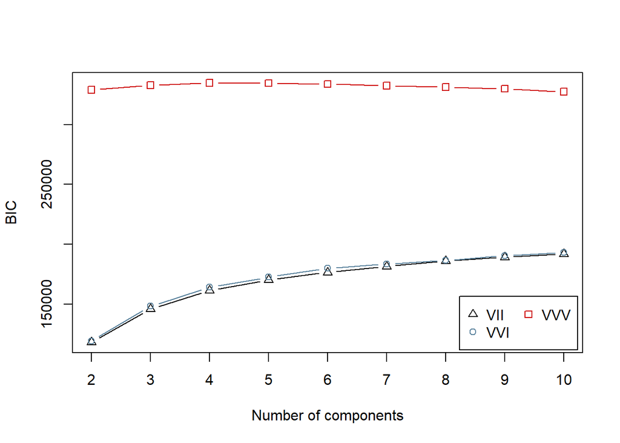

```r
plot(BIC_temp)
```

```r
summary(BIC_temp)
```

```
## Best BIC values:
##             VVV,4       VVV,5      VVV,6
## BIC      334806.1 334618.6603 333829.468
## BIC diff      0.0   -187.4804   -976.673
```

```r
#mclustModelNames("VVE")
```

```r
mclust_temps <- Mclust(na.omit(data_norm[28:51]), G= 2:10, model=c("VII", "VVI", "VVV"))
```

```r
summary(mclust_temps)
```

```
## ----------------------------------------------------
## Gaussian finite mixture model fitted by EM algorithm
## ----------------------------------------------------
##
## Mclust VVV (ellipsoidal, varying volume, shape, and orientation) model with 6
## components:
##
##  log-likelihood    n   df      BIC      ICL
##        174378.2 2282 1949 333685.1 333430.5
##
## Clustering table:
##   1   2   3   4   5   6
## 371 556 469 327 400 159
```

Se puede visualizar los clusters, pero con 24 atributos resulta intensivo para el procesador, por un resultado poco apreciable.

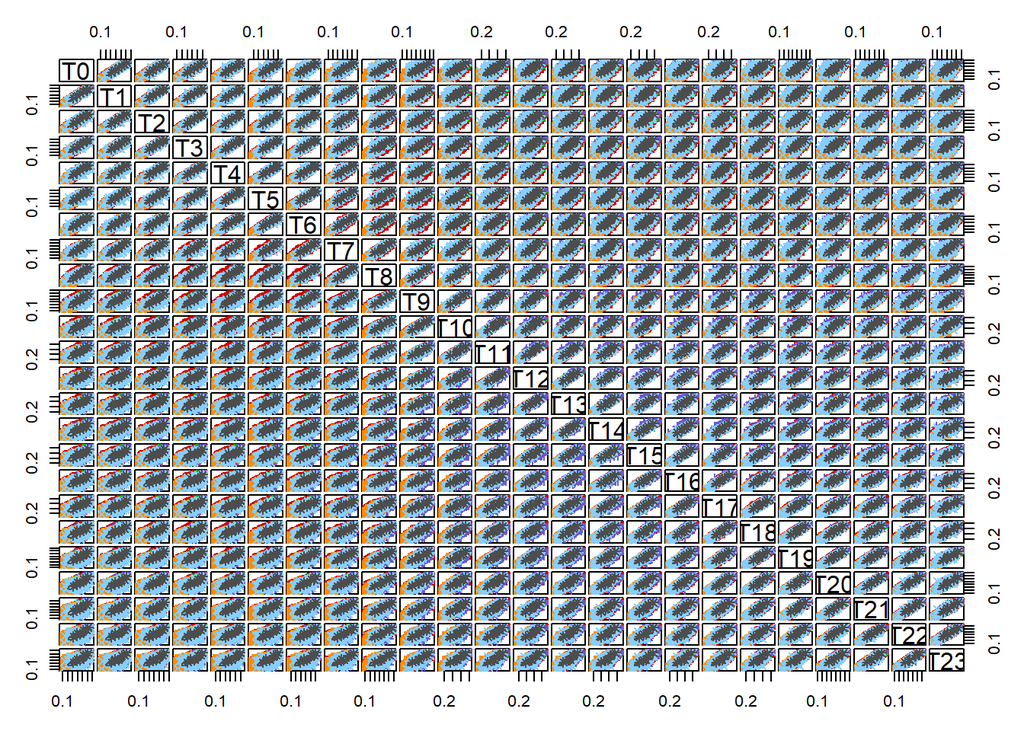

```r
plot(mclust_temps, what="classification")
```

Podemos ver, numéricamente, los centros de cada cluster en términos de cada temperatura:

```r
mclust_temps$parameters$mean
```

```
##          [,1]      [,2]      [,3]      [,4]      [,5]      [,6]
## T0  0.6123525 0.3957347 0.5186836 0.5736964 0.3202730 0.4578137
## T1  0.6061675 0.3857345 0.5147232 0.5696765 0.3134806 0.4514488
## T2  0.6007362 0.3770945 0.5119585 0.5658591 0.3074457 0.4448383
## T3  0.5961223 0.3695608 0.5098154 0.5629086 0.3018697 0.4379189
## T4  0.5917769 0.3632171 0.5087083 0.5605745 0.2967699 0.4307287
## T5  0.5895829 0.3585223 0.5083707 0.5594659 0.2928958 0.4254515
## T6  0.6007248 0.3583722 0.5111060 0.5656857 0.2900745 0.4214765
## T7  0.6314216 0.3790349 0.5256764 0.5863016 0.2903193 0.4274347
## T8  0.6594503 0.4231321 0.5517974 0.6111288 0.3014176 0.4414161
## T9  0.6846823 0.4685511 0.5791722 0.6344790 0.3207889 0.4574507
## T10 0.7074578 0.5033438 0.6022618 0.6530779 0.3432774 0.4764522
## T11 0.7266523 0.5282633 0.6203896 0.6605899 0.3639254 0.4926673
## T12 0.7414367 0.5470201 0.6328816 0.6572327 0.3812261 0.5042249
## T13 0.7512822 0.5611345 0.6384651 0.6528643 0.3939690 0.5147827
## T14 0.7573455 0.5717445 0.6406331 0.6464202 0.4030475 0.5238076
## T15 0.7565127 0.5763222 0.6378439 0.6390581 0.4067709 0.5260796
## T16 0.7483525 0.5714553 0.6292861 0.6308129 0.4034363 0.5192372
## T17 0.7320901 0.5518631 0.6127101 0.6178442 0.3921601 0.5066726
## T18 0.7073960 0.5194266 0.5921355 0.6028335 0.3759558 0.4873930
## T19 0.6806891 0.4892344 0.5755916 0.5857190 0.3614573 0.4671150
## T20 0.6616210 0.4659209 0.5641843 0.5735258 0.3500809 0.4519403
## T21 0.6481782 0.4488133 0.5558716 0.5659342 0.3413032 0.4365637
## T22 0.6369131 0.4345544 0.5493701 0.5587210 0.3337049 0.4197371
## T23 0.6279465 0.4212451 0.5436662 0.5509282 0.3269103 0.4077499
```

y las clasificaciones en clusters:

```r
head(mclust_temps$classification, n=40)
```

```
##  1  2  3  4  5  6  7  8  9 10 11 12 13 14 15 16 17 18 19 20 21 22 23 24 25 26
##  5  5  3  5  5  5  6  5  5  3  3  2  5  2  5  2  5  6  5  6  3  5  5  2  6  5
## 27 28 29 30 31 32 33 34 35 36 37 38 39 40
##  2  2  3  3  3  5  5  5  5  5  5  5  6  4
```

Para intentar evaluar la clasificación y su utilidad hacia la clase de ozono, hacemos una tabla para cada tipo de día de ozono:

```r
table(Txx_1h_data$OzoneDay1hPeak,  mclust_temps$classification)
```

```
##
##       1   2   3   4   5   6
##   0 341 534 460 323 398 158
##   1  30  22   9   4   2   1
```

```r
table(Txx_8h_data$Oz8h,  mclust_temps$classification)
```

```
##
##       1   2   3   4   5   6
##   0 320 499 444 314 399 157
##   1  51  57  25  13   1   2
```

Aquí, tenemos una distribución de días de ozono por todos los clusters, y así no da la impresión de ser útil. Los resultados más sencillas de PAM parecen mejores.

Brevemente:

```r
mclust_VVV4_temps <- Mclust(na.omit(data_norm[28:51]), G= 4, model=c("VVV"))
mclust_VVV6_temps <- Mclust(na.omit(data_norm[28:51]), G= 6, model=c("VVV"))

# Confusion tables for VVV G=4
table(Txx_1h_data$OzoneDay1hPeak,  mclust_VVV4_temps$classification)
```

```
##
##       1   2   3   4
##   0 325 709 813 367
##   1   4  39  21   4
```

```r
table(Txx_8h_data$Oz8h,  mclust_VVV4_temps$classification)
```

```
##
##       1   2   3   4
##   0 324 674 777 358
##   1   5  74  57  13
```

```r
# Confusion tables for VVV G=6
table(Txx_1h_data$OzoneDay1hPeak,  mclust_VVV6_temps$classification)
```

```
##
##       1   2   3   4   5   6
##   0 158 304 474 297 503 478
##   1   1   2  35   4  24   2
```

```r
table(Txx_8h_data$Oz8h,  mclust_VVV6_temps$classification)
```

```
##
##       1   2   3   4   5   6
##   0 157 304 440 289 466 477
##   1   2   2  69  12  61   3
```

- 90% (1h) y 88% (8h)
- 70% de los sin ozono
- “apalancamiento” de 1.27

Se nota que estamos ganando por la segregación mayor cuando tenemos más clusters, no por una mejora en distinción de los casos de ozono. Por decir, que estamos mejorando la *precisión*.

Como que vemos mejores con más grupos, y la curva de BIC es muy plana, probamos con G 7 y 8.

Brevemente:

```r
mclust_VVV7_temps <- Mclust(na.omit(data_norm[28:51]), G= 7, model=c("VVV"))
mclust_VVV8_temps <- Mclust(na.omit(data_norm[28:51]), G= 8, model=c("VVV"))

# Confusion tables for VVV G=7
table(Txx_1h_data$OzoneDay1hPeak,  mclust_VVV7_temps$classification)
```

```
##
##       1   2   3   4   5   6   7
##   0 336 337 335 130 347 441 288
##   1   2   7   1   2  23  30   3
```

```r
table(Txx_8h_data$Oz8h,  mclust_VVV7_temps$classification)
```

```
##
##       1   2   3   4   5   6   7
##   0 336 332 334 129 306 417 279
##   1   2  12   2   3  64  54  12
```

```r
# Confusion tables for VVV G=8
table(Txx_1h_data$OzoneDay1hPeak,  mclust_VVV8_temps$classification)
```

```
##
##       1   2   3   4   5   6   7   8
##   0 104 304 163 311 358 339 257 378
##   1   1  26   1   2   7   2   3  26
```

```r
table(Txx_8h_data$Oz8h,  mclust_VVV8_temps$classification)
```

```
##
##       1   2   3   4   5   6   7   8
##   0 104 292 155 312 355 340 250 325
##   1   1  38   9   1  10   1  10  79
```

- 78% (1h) y 74% (8h)
- 39-41% de los sin ozono
- “apalancamiento” de 1.9

- 76% (1h) y 77% (8h)
- 29-31% de los sin ozono
- “apalancamiento” de 2.5

Seguimos ganando más dividiendo los de sin ozono más que perdemos en la recogida de días de ozono, con más grupos. Ese último con G 8 parece muy bien, principalmente por la distribución de los días de ozono en 2 y no 3 de los clusters.

Para confirmar con una prueba Kruskal-Wallis, G=8:

```r
Txx_MCL_G8_8h <- cbind(Oz8h = Txx_8h_data$Oz8h, MCL_G8_Cl = mclust_VVV8_temps$classification)

kruskal.test(Oz8h ~ MCL_G8_Cl, Txx_MCL_G8_8h)
```

```
##
##  Kruskal-Wallis rank sum test
##
## data:  Oz8h by MCL_G8_Cl
## Kruskal-Wallis chi-squared = 184.47, df = 7, p-value < 2.2e-16
```

Así confirmamos que las proporciones son significativamente distintos a cero.

#### 3.4.3.3 Investigación: clasificando vectores de temperaturas con DBSCAN (no supervisado)

Para usar una clasificación basada en densidad, tenemos que

1. Seleccionar un valor k para cuantos vecinos considerar para medir las distancias.
2. De la curva de distancias, estimamos un punto de maxima eficiencia al “codo” de la curva. Así tenemos un valor de radio epsilon.
3. Finalmente producir el modelo, con los parametros k usado, y el epsilon elegido.

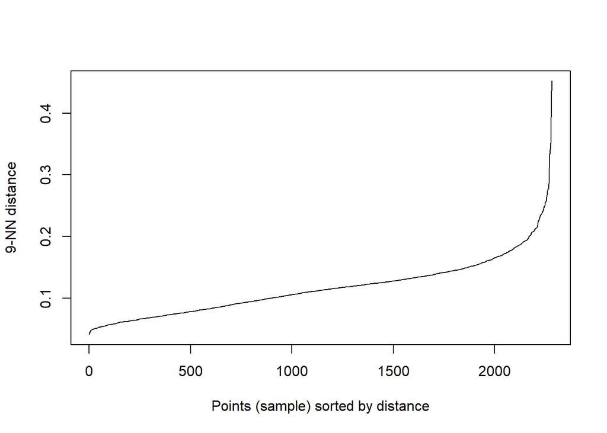

```r
kNNdistplot(na.omit(data_norm[28:51]), k=9)
```

Estimamos un valor epsilon de ~ 0.18 por k=9.

```r
dbscan(na.omit(data_norm[28:51]), eps = 0.18, minPts = 9)
```

```
## DBSCAN clustering for 2282 objects.
## Parameters: eps = 0.18, minPts = 9
## The clustering contains 1 cluster(s) and 46 noise points.
##
##    0    1
##   46 2236
##
## Available fields: cluster, eps, minPts
```

Pues eso no ha funcionado ! Solo considera que tiene un cluster. Cambiamos a un k mayor para probar.

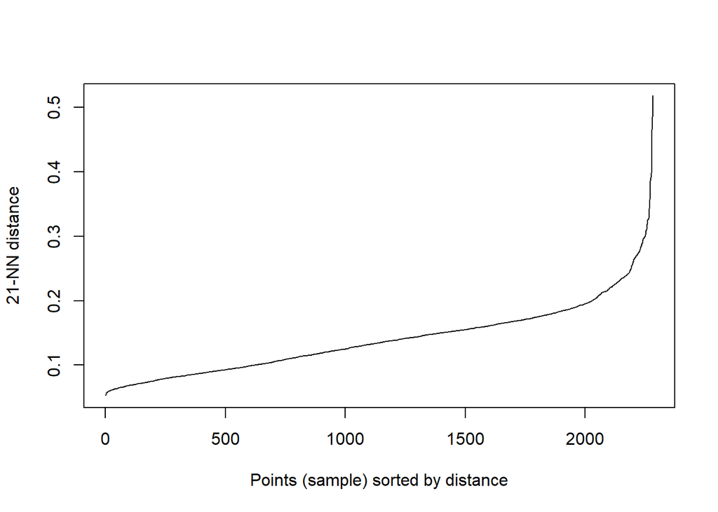

```r
kNNdistplot(na.omit(data_norm[28:51]), k=21)
```

```r
dbscan(na.omit(data_norm[28:51]), eps = 0.22, minPts = 21)
```

```
## DBSCAN clustering for 2282 objects.
## Parameters: eps = 0.22, minPts = 21
## The clustering contains 1 cluster(s) and 30 noise points.
##
##    0    1
##   30 2252
##
## Available fields: cluster, eps, minPts
```

Igualmente, no es de ayuda. Seguramente es sintomático de puntos de observación sin separación visible.

#### 3.4.3.4 Investigación: clasificando vectores de temperaturas con SVM (supervisado)

Ahora probaremos un algoritmo supervisado para usar la información disponible del clase de ozono, para ver si podemos mejorar la clasificación. Usaremos *support-vector machine*. Eso es un experimento, como que la idea original para la vectorización de las temperaturas y velocidades del viento no era de usar la información de los clases y solo basar los clusters en las características de los vectores mismos.

Necesitemos los datos de los vectores de temperatura, solos, más la clase de ozono. Los tenemos ya construidos en Txx_8h_data y Txx_1h_data. Solo tenemos que convertir la clase en factor.

```r
Txx_8h_data$Oz8h <- as.factor(Txx_8h_data$Oz8h)
Txx_1h_data$OzoneDay1hPeak <- as.factor(Txx_1h_data$OzoneDay1hPeak)
```

Probamos ahora a crear el modelo. Hay distintas tipos de tipo de kernel a probar.

```r
svmfit_Txx_8h <- svm(Oz8h ~., data=Txx_8h_data, type="C-classification", kernel="polynomial", cost = 5)
```

```r
print(svmfit_Txx_8h)
```

```
##
## Call:
## svm(formula = Oz8h ~ ., data = Txx_8h_data, type = "C-classification",
##     kernel = "polynomial", cost = 5)
##
##
## Parameters:
##    SVM-Type:  C-classification
##  SVM-Kernel:  polynomial
##        cost:  5
##      degree:  3
##      coef.0:  0
##
## Number of Support Vectors:  319
```

Cuantos clusters ha creado ?

```r
svmfit_Txx_8h$nclasses
```

```
## [1] 2
```

Entonces solo han creado dos clusters… A ver qué dice una tabla de confusiónÑ

```r
table(Txx_8h_data$Oz8h, svmfit_Txx_8h$fitted)
```

```
##
##        0    1
##   0 2133    0
##   1  147    2
```

Entonces, no parece útil, se ha clasificado todos los puntos aparte de 2 en el primer cluster.

De hecho, probando los 4 tipos de kernel resulta que ninguno puede dar un resultado útil.

#### 3.4.3.5 Método elegido para vectores de temperatura

De lo que hemos probado, usando el concepto de cuantos ocasiones de ozono podemos aislar comparado a la porción de días sin ozono que llevamos en los mismos clusters, el MClust queda mejor. Usaremos el modelo VVV con G=8.

#### 3.4.3.6 Investigación: clasificando vectores de velocidades del viento con PAM (no supervisado)

Repetimos el mismo conjunto de investigaciones ahora para los WSRxx, para o confirmar el uso de PAM o otro método.

```r
WSR_clusters <- pamk(na.omit(data_norm[2:25]), krange = 2:10, criterion = "ch", usepam = TRUE)
```

```r
head(WSR_clusters$pamobject)
```

```
## $medoids
##      WSR0 WSR1 WSR2 WSR3 WSR4 WSR5 WSR6 WSR7 WSR8 WSR9 WSR10 WSR11 WSR12 WSR13
## 986  0.28 0.23 0.19 0.16 0.20 0.21 0.24 0.29 0.33 0.44  0.35  0.40  0.40  0.39
## 2371 0.08 0.05 0.07 0.11 0.11 0.11 0.15 0.21 0.19 0.18  0.19  0.21  0.21  0.24
##      WSR14 WSR15 WSR16 WSR17 WSR18 WSR19 WSR20 WSR21 WSR22 WSR23
## 986   0.43  0.45  0.41  0.39  0.34  0.30  0.25  0.26  0.21  0.23
## 2371  0.25  0.28  0.24  0.25  0.23  0.17  0.13  0.12  0.10  0.07
##
## $id.med
## [1]  936 2014
##
## $clustering
##    1    2    3    4    5    6    7    8    9   10   11   12   13   14   15   16
##    1    1    1    1    2    1    1    1    2    2    1    2    2    2    1    1
##   17   18   19   20   21   22   23   24   25   26   27   28   29   30   31   32
```

[output cut: 285 more lines]

```r
head(WSR_clusters$crit)
```

```
## [1]    0.0000 1205.2506  825.6192  737.6779  623.0525  549.9611
```

El algoritmo ha agrupado nuestros vectores diarias en 2 grupos.

Para visualizar la asignación de clusters, pero solo en dos dimensiones, usando una pareja aleatoria de WSRxx:

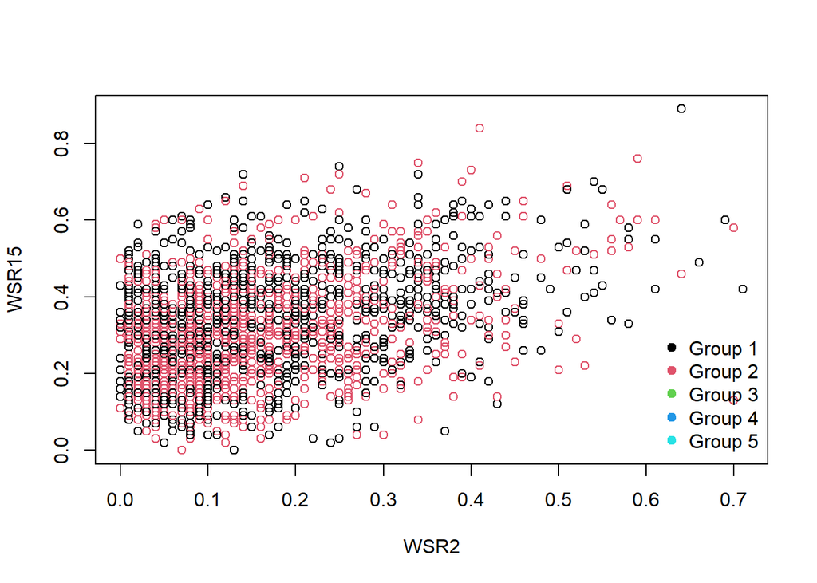

```r
plot(data_norm[c(4,17)], col = WSR_clusters$pamobject$clustering)

# below assumes 5 groups, needs fixing to check how many.  Seems to have given 3
legend("bottomright", legend = paste("Group", 1:5), col = 1:5, pch = 19, bty = "n")
```

Visualizando los vectores “medoid”, resultado del clustering PAM:

```r
medoids_WSRxx <- as.data.frame(WSR_clusters$pamobject$medoids)
medoids_WSRxx
```

```
##      WSR0 WSR1 WSR2 WSR3 WSR4 WSR5 WSR6 WSR7 WSR8 WSR9 WSR10 WSR11 WSR12 WSR13
## 986  0.28 0.23 0.19 0.16 0.20 0.21 0.24 0.29 0.33 0.44  0.35  0.40  0.40  0.39
## 2371 0.08 0.05 0.07 0.11 0.11 0.11 0.15 0.21 0.19 0.18  0.19  0.21  0.21  0.24
##      WSR14 WSR15 WSR16 WSR17 WSR18 WSR19 WSR20 WSR21 WSR22 WSR23
## 986   0.43  0.45  0.41  0.39  0.34  0.30  0.25  0.26  0.21  0.23
## 2371  0.25  0.28  0.24  0.25  0.23  0.17  0.13  0.12  0.10  0.07
```

```r
# Use tidyverse to pivot WSR and T data such that we have only columns Time, Temp (or WSR)

# Create name vectors for the hourly values to provide to pivot_longer
WSRs <- c("WSR0","WSR1","WSR2","WSR3","WSR4","WSR5","WSR6","WSR7","WSR8","WSR9","WSR10","WSR11","WSR12","WSR13","WSR14","WSR15","WSR16","WSR17","WSR18","WSR19","WSR20","WSR21","WSR22","WSR23")

# First make the Cluster quantity values explicit as column, and add cluster number
medoids_WSRxx <- cbind(cluster=c(1,2),cluster_quantity=(rownames(medoids_WSRxx)), medoids_WSRxx)

medoids_WSRxx_Tidy <- medoids_WSRxx %>%
  pivot_longer(all_of(WSRs), names_to = "HourofDay", values_to = "WindSpeeds", )

medoids_WSRxx_Tidy$HourofDay <- factor(medoids_WSRxx_Tidy$HourofDay, levels = WSRs)
medoids_WSRxx_Tidy$cluster <- factor(medoids_WSRxx_Tidy$cluster)
```

Así, para poder visualizar los valores cada hora, hemos hecho una transformación a los datos de velocidad del viento y temperatura de cada hora. Con esos cambios, hemos hecho primero unas tablas especificas para cada tipo de medida, de Fecha mas las 24 columnas para cada hora. Entendemos que todos esos medidas en principio son el mismo variable, y se pueden concatenar todos en la misma columna si modulemos los datos con la hora del día.

La función pivot_longer() hace exactamente eso, para que podemos ahora producir gráficos que podemos apreciar mejor.

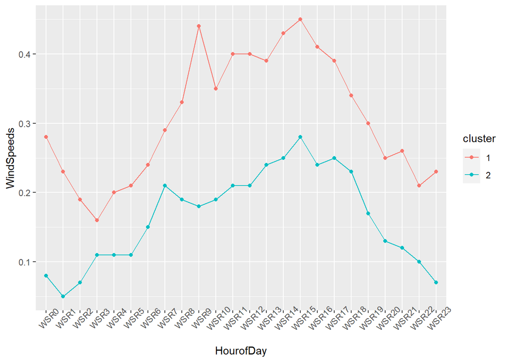

```r
ggplot(as.data.frame(medoids_WSRxx_Tidy), aes(x=HourofDay, y=WindSpeeds, group=cluster)) + geom_point(aes(col=cluster)) + geom_line(aes(col=cluster)) + theme(axis.text.x = element_text(angle=45))
```

Entonces, **pamk()** nos dan 2 clusters de vectores en ese caso, y claramente se distinguen por ser de diferentes niveles de vientos. Es un poco decepcionante que no ha podido identificar más patrones típicas.

Para evaluar la utilidad de los clusters, podemos hacer una tabla comparando el numero asignado de cluster y la clase de ozono, para cada una. Pero hay que filtrar los clases según la presencia de NAs en los valores WSRxx para que se quedan alineados.

```r
# The desired columns including class
cols_indices_8h_WSR <- c(2:25, 67)
cols_indices_1h_WSR <- c(2:25, 66)

# subset data correctly so the class values are lined up with available non-NA Txx data
WSRxx_8h_data <- na.omit(data_norm[cols_indices_8h_WSR])
WSRxx_1h_data <- na.omit(data_norm[cols_indices_1h_WSR])

# create table for 1h
table(WSRxx_1h_data$OzoneDay1hPeak, WSR_clusters$pamobject$clustering)
```

```
##
##        1    2
##   0  934 1177
##   1    2   64
```

```r
# create table for 8h
table(WSRxx_8h_data$Oz8h, WSR_clusters$pamobject$clustering)
```

```
##
##        1    2
##   0  923 1106
##   1   13  135
```

```r
# or a better confusion matrix
CrossTable(WSRxx_8h_data$Oz8h, WSR_clusters$pamobject$clustering,prop.chisq  = FALSE, prop.c = FALSE, prop.r =FALSE,dnn = c('Reality', 'Prediction'))
```

```
##
##
##    Cell Contents
## |-------------------------|
## |                       N |
## |         N / Table Total |
## |-------------------------|
##
##
## Total Observations in Table:  2177
##
##
##              | Prediction
##      Reality |         1 |         2 | Row Total |
## -------------|-----------|-----------|-----------|
##            0 |       923 |      1106 |      2029 |
##              |     0.424 |     0.508 |           |
## -------------|-----------|-----------|-----------|
##            1 |        13 |       135 |       148 |
##              |     0.006 |     0.062 |           |
## -------------|-----------|-----------|-----------|
## Column Total |       936 |      1241 |      2177 |
## -------------|-----------|-----------|-----------|
##
##
```

Quedamos con el hecho que la segunda cluster funciona mejor para incluir los días de ozono.

Tenemos 97% (1h) y 91% (8h) en cluster 2, por una proporción de los sin ozono de 55%, dando un ratio de “apalancamiento” de ~94/55 = 1.7. Se puede notar que el cluster 2 tiene velocidades del viento más bajos, correspondiendo con un entendimiento físico del fenómeno, que debería estar menor cuando el viento dispersa los contaminantes precursores.

Como para las temperaturas, hacemos una prueba Kruskal-Wallis para confirmar si piensa que las proporciones de días de ozono son iguales para cada cluster, o no. Suponemos que la distribución vista arriba es significativa.

```r
WSRxx_PAM_8h <- cbind(Oz8h = WSRxx_8h_data$Oz8h, pamCl = WSR_clusters$pamobject$clustering)

kruskal.test(Oz8h ~ pamCl, WSRxx_PAM_8h)
```

```
##
##  Kruskal-Wallis rank sum test
##
## data:  Oz8h by pamCl
## Kruskal-Wallis chi-squared = 75.796, df = 1, p-value < 2.2e-16
```

Como esperado, queda rechazada la hipótesis nula que las proporciones son iguales. Entonces tenemos algo de información proporcionado con esa clasificación.

#### 3.4.3.7 Investigación: clasificando vectores de vientos con MCLUST (no supervisado)

También aquí tenemos que dar un rango de número de grupos al algoritmo. Usaremos una selección de modelos con dimensiones-volúmenes desiguales solo, porque ese algoritmo es mucho más lento.

Igual que en el paso anterior, estamos omitiendo los registros con NAs de momento para evaluar cual algoritmo usar definitivamente. Después habrá que investigar si se puede recuperar algunos NAs, antes de hacer la conversión final.

```r
BIC_WSR <- mclustBIC(na.omit(data_norm[2:25]), G= 2:10, model=c("VII", "VVI", "VVV"))
```

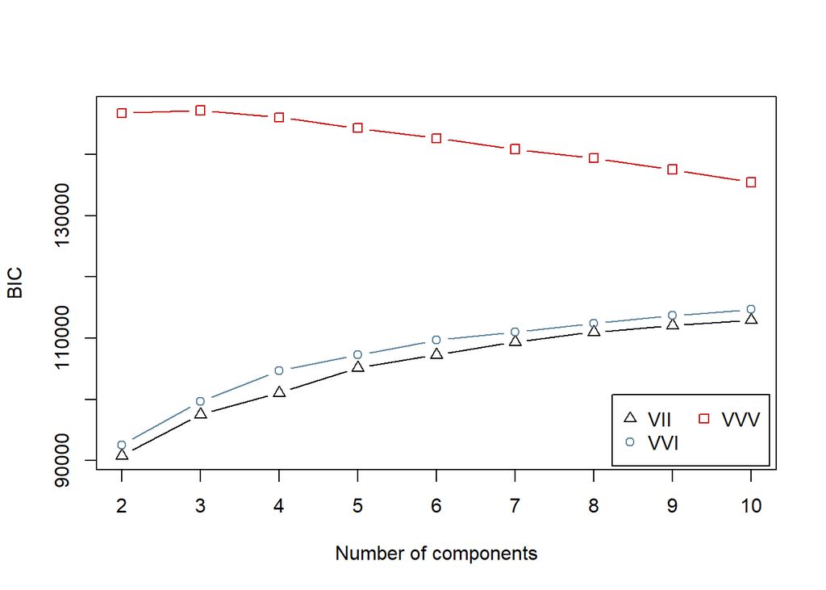

```r
plot(BIC_WSR)
```

```r
summary(BIC_WSR)
```

```
## Best BIC values:
##             VVV,3      VVV,2      VVV,4
## BIC      147190.4 146752.114 146046.784
## BIC diff      0.0   -438.296  -1143.627
```

Comparado a la situación con las temperaturas, tenemos un comportamiento distinto, favoreciendo G´s de 3 solo, y la curva del VVV cae rápidamente. Podemos priorizar un modelo de VVV, y probar G de 2 a 4.

```r
mclust_G3_WSR <- Mclust(na.omit(data_norm[2:25]), G= 3, model=c("VVV"))


mclust_G2_WSR <- Mclust(na.omit(data_norm[2:25]), G= 2, model=c("VVV"))
mclust_G4_WSR <- Mclust(na.omit(data_norm[2:25]), G= 4, model=c("VVV"))
```

```r
summary(mclust_G3_WSR)
```

```
## ----------------------------------------------------
## Gaussian finite mixture model fitted by EM algorithm
## ----------------------------------------------------
##
## Mclust VVV (ellipsoidal, varying volume, shape, and orientation) model with 3
## components:
##
##  log-likelihood    n  df      BIC      ICL
##        77328.25 2177 974 147170.6 146778.2
##
## Clustering table:
##   1   2   3
## 799 989 389
```

Se puede visualizar los clusters, pero con 24 atributos resulta intensivo para el procesador, por un resultado poco apreciable.

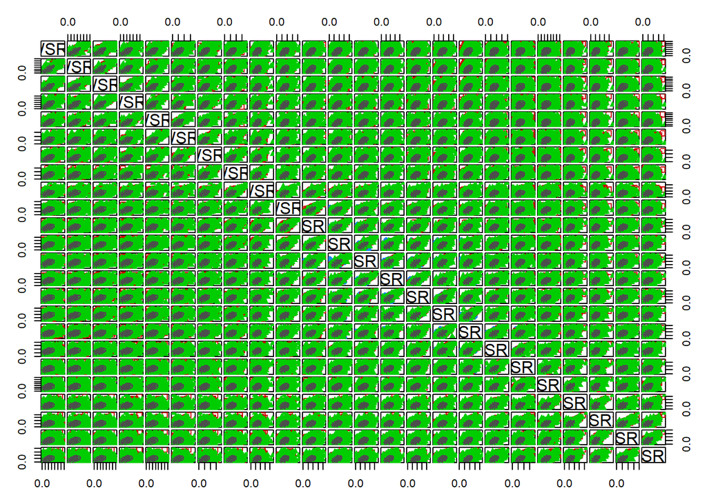

```r
plot(mclust_G3_WSR, what="classification")
```

Podemos ver, numéricamente, los centros de cada cluster en términos de cada velocidad:

```r
mclust_G3_WSR$parameters$mean
```

```
##             [,1]      [,2]      [,3]
## WSR0  0.08106945 0.1963183 0.2444997
## WSR1  0.07519270 0.1905160 0.2405927
## WSR2  0.07031032 0.1886315 0.2333001
## WSR3  0.06708169 0.1868001 0.2321394
## WSR4  0.06745952 0.1854443 0.2322799
## WSR5  0.07218868 0.1880754 0.2281903
## WSR6  0.08619480 0.1970157 0.2307526
## WSR7  0.13298117 0.2389938 0.2580053
## WSR8  0.18402011 0.2927004 0.2923060
## WSR9  0.20666013 0.3293893 0.3248387
## WSR10 0.21347689 0.3441987 0.3436867
## WSR11 0.21244363 0.3514969 0.3527124
## WSR12 0.21740320 0.3520759 0.3561073
## WSR13 0.22689824 0.3559959 0.3604765
## WSR14 0.23860249 0.3620387 0.3631786
## WSR15 0.25281309 0.3602436 0.3682390
## WSR16 0.26163597 0.3509743 0.3530840
## WSR17 0.24504365 0.3200488 0.3243252
## WSR18 0.21133255 0.2802553 0.2865823
## WSR19 0.18110232 0.2517721 0.2635920
## WSR20 0.15579867 0.2332089 0.2534177
## WSR21 0.13591632 0.2196023 0.2443799
## WSR22 0.11672292 0.2084897 0.2375819
## WSR23 0.10217827 0.2028761 0.2285865
```

y las clasificaciones en clusters:

```r
head(mclust_G3_WSR$classification, n=40)
```

```
##  1  2  3  4  5  6  7  8  9 10 11 12 13 14 15 16 17 18 19 20 21 22 23 24 25 26
##  2  2  2  3  2  3  3  3  2  1  2  2  1  2  2  1  2  3  2  2  3  2  2  1  2  2
## 27 28 29 30 31 32 33 34 35 36 37 38 39 40
##  2  1  1  1  2  2  2  2  1  2  2  2  1  2
```

Para intentar evaluar la clasificación y su utilidad hacia la clase de ozono, hacemos una tabla para cada tipo de día de ozono:

```r
# Displaying tables for G=2
table(WSRxx_1h_data$OzoneDay1hPeak,  mclust_G2_WSR$classification)
```

```
##
##        1    2
##   0 1188  923
##   1   60    6
```

```r
table(WSRxx_8h_data$Oz8h,  mclust_G2_WSR$classification)
```

```
##
##        1    2
##   0 1125  904
##   1  123   25
```

```r
# for G=3
table(WSRxx_1h_data$OzoneDay1hPeak,  mclust_G3_WSR$classification)
```

```
##
##       1   2   3
##   0 746 980 385
##   1  53   9   4
```

```r
table(WSRxx_8h_data$Oz8h,  mclust_G3_WSR$classification)
```

```
##
##       1   2   3
##   0 693 958 378
##   1 106  31  11
```

```r
# for G=4
table(WSRxx_1h_data$OzoneDay1hPeak,  mclust_G4_WSR$classification)
```

```
##
##       1   2   3   4
##   0 395 901 253 562
##   1  27   3   1  35
```

```r
table(WSRxx_8h_data$Oz8h,  mclust_G4_WSR$classification)
```

```
##
##       1   2   3   4
##   0 374 882 251 522
##   1  48  22   3  75
```

Aquí, tenemos una distribución de días de ozono mayor en el cluster 1, y de hecho parece funcionar mejor que en el caso de los temperaturas. Tenemos 82% (1h) y 73% (8h) en el cluster 1, comparado con 36% de los sin ozono, por un “apalancamiento” de ~ 2.1.

Parece valer la pena probar con G=5 y 6 antes de proceder, aunque la curva de BIC está bajando:

```r
mclust_G5_WSR <- Mclust(na.omit(data_norm[2:25]), G= 5, model=c("VVV"))
mclust_G6_WSR <- Mclust(na.omit(data_norm[2:25]), G= 6, model=c("VVV"))

# for G=5
table(WSRxx_1h_data$OzoneDay1hPeak,  mclust_G5_WSR$classification)
```

```
##
##       1   2   3   4   5
##   0 470 417 863 140 221
##   1  40  20   4   0   2
```

```r
table(WSRxx_8h_data$Oz8h,  mclust_G5_WSR$classification)
```

```
##
##       1   2   3   4   5
##   0 434 392 844 140 219
##   1  76  45  23   0   4
```

```r
# for G=6
table(WSRxx_1h_data$OzoneDay1hPeak,  mclust_G6_WSR$classification)
```

```
##
##       1   2   3   4   5   6
##   0 186 531 687 225 269 213
##   1   0  39   4  13   8   2
```

```r
table(WSRxx_8h_data$Oz8h,  mclust_G6_WSR$classification)
```

```
##
##       1   2   3   4   5   6
##   0 178 498 675 206 260 212
##   1   8  72  16  32  17   3
```

Aquí es un poco más difícil elegir cuantos clusters considerar en el calculo. Evidentemente, estamos usando nuestro juicio personal aquí evaluando algo que un algoritmo posiblemente no haría igual.

Pero, si contamos clusters 1,2 y 3, estaría peor.

- 83% (1h) y 69% (8h)
- 29-30% de los sin ozono
- “apalancamiento” de 2.53

Seguimos ganando más dividiendo los de sin ozono más que perdemos en la recogida de días de ozono, con más grupos. Ese último con G 6 parece muy bien, principalmente por la distribución de los días de ozono en 2 y no 3 de los clusters. De nuevo es difícil saber cuando parar, pero al menos aquí con los WSRs la curva de la BIC está bajando más fuertemente y no nos impulsa mucho para seguir probando.

Parece que G=6 sería un modelo útil. Probamos de nuevo un test de hipótesis usando Kruskal-Wallis, por G=6:

```r
WSRxx_MCL_G6_8h <- cbind(Oz8h = WSRxx_8h_data$Oz8h, MCL_G6_Cl = mclust_G6_WSR$classification)

kruskal.test(Oz8h ~ MCL_G6_Cl, WSRxx_MCL_G6_8h)
```

```
##
##  Kruskal-Wallis rank sum test
##
## data:  Oz8h by MCL_G6_Cl
## Kruskal-Wallis chi-squared = 81.013, df = 5, p-value = 5.152e-16
```

#### 3.4.3.8 Método elegido para vectores de velocidad

No repetiremos aquí las pruebas con DBSCAN o SVM, por la falta de utilidad que han demostrado con las temperaturas.

Dejando que seguimos las medidas de “apalancamiento”, parece razonable usar MClust con VVV, G=6.

## 3.5 Limpieza de valores NA

Aquí estamos preparados para proceder con trabajos de rescate de todos los valores NA, que podemos tratar de varias maneras.

Como en cada trabajo de limpieza de datos, no es una cosa sencilla elegir como proceder. No se sabe de forma precisa como imputación de valores NA podría influir los resultados posteriores de modelización, si no se hace de forma iterativa.

En el contexto del trabajo actual, el autor tiene esfuerzos anteriores con esos datos, que eran sin imputación, y ha sido difícil producir modelos útiles. La modelización tiene más reto también por la falta de días de ozono alto en los datos, son un resultado escaso y la poca frecuencia da dificultades de apercebir como predecirles.

Entonces, haremos el máximo para imputar valores NA, en un intento de mejorar la modelización.

Según el contexto, usaremos una variedad de métodos:

- kNN con otros atributos específicos, cuando tiene sentido
- sustitución con valores medias
- sustitución con valores aproximativas por una linea entre datos horarios existentes
- distancia mínima de un centro de cluster, para los vectores de datos horarios parciales

El enfoque tiene que ser rescatar la mayor cantidad de registros con ozono alto. Si elegimos eliminar filas, mejor que sean de ozono bajo.

### 3.5.1 Vista general de valores NA

Primero, miramos cuantos valores NA tienen cada fila con una función de búsqueda y un histograma.

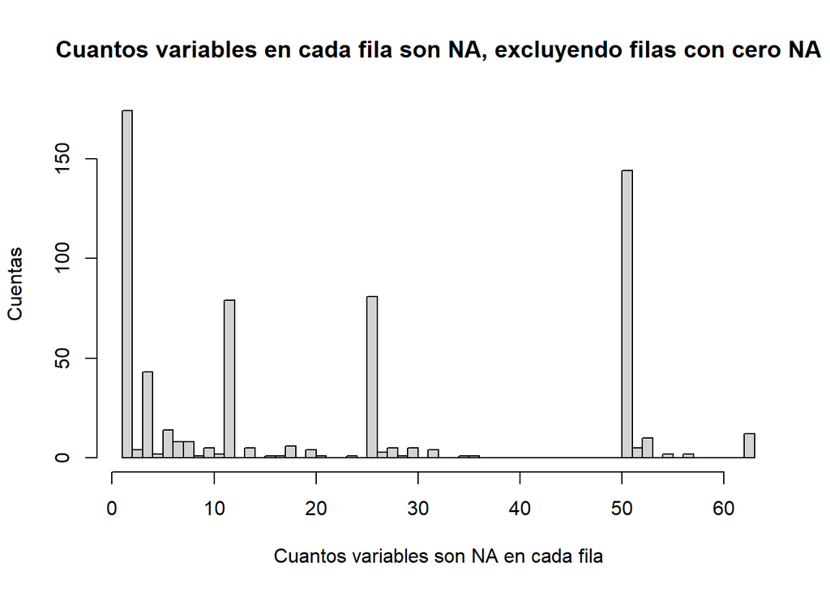

```r
count_nas_in_row <- function(vect){
    n = sum(is.na(vect))
    if (n==0) {
      return (NA)
    }
    else return (n)
}

# sweep by rows (margin = 1)
na_count <- apply(data_norm, MARGIN=1, count_nas_in_row)

# histogram count of NAs per row
# Note, zeros will be excluded because are "NA" instead from function above
hist(na_count, breaks=50, xlab="Cuantos variables son NA en cada fila", ylab="Cuentas", main="Cuantos variables en cada fila son NA, excluyendo filas con cero NA")
```

Vemos que hay muchas filas que faltan 2, 12, 25 o 26, y 51 variables. Entonces el comportamiento es que faltan grupos de variables a la vez, parece ser.

Un ejemplo abajo de una fila que falta 51 variables, y vemos que falta todos los WSR horarios, los T horarios, por consecuencia los valores máximas y medias de cada también. No hay nada que se puede hacer contra eso. Solo es una cuestión de cuantos tales filas afectan filas con ozono, como que son poco frecuente y por tanto, valiosos.

```r
head(na_count[which(na_count == 51)])
```

```
## 1634 1635 1636 1637 1638 1639
##   51   51   51   51   51   51
```

```r
data_norm[1634, ]
```

```
##            DATE WSR0 WSR1 WSR2 WSR3 WSR4 WSR5 WSR6 WSR7 WSR8 WSR9 WSR10 WSR11
## 1634 2002-07-03   NA   NA   NA   NA   NA   NA   NA   NA   NA   NA    NA    NA
##      WSR12 WSR13 WSR14 WSR15 WSR16 WSR17 WSR18 WSR19 WSR20 WSR21 WSR22 WSR23
## 1634    NA    NA    NA    NA    NA    NA    NA    NA    NA    NA    NA    NA
##      WSR_PK WSR_AV T0 T1 T2 T3 T4 T5 T6 T7 T8 T9 T10 T11 T12 T13 T14 T15 T16
## 1634     NA     NA NA NA NA NA NA NA NA NA NA NA  NA  NA  NA  NA  NA  NA  NA
##      T17 T18 T19 T20 T21 T22 T23 T_PK       T85 RH85     U85    V85       T70
## 1634  NA  NA  NA  NA  NA  NA  NA   NA 0.7689873  0.8 -0.0054 0.1128 0.7088123
##         U70    V70       T50 RH50    U50    V50       SLP Precp OzoneDay1hPeak
## 1634 0.0196 0.1024 0.7445887 0.67 0.0854 0.0646 0.4933333     0              0
##      Oz8h
## 1634    0
```

Repetimos la busqueda, pero solo para días de ozono:

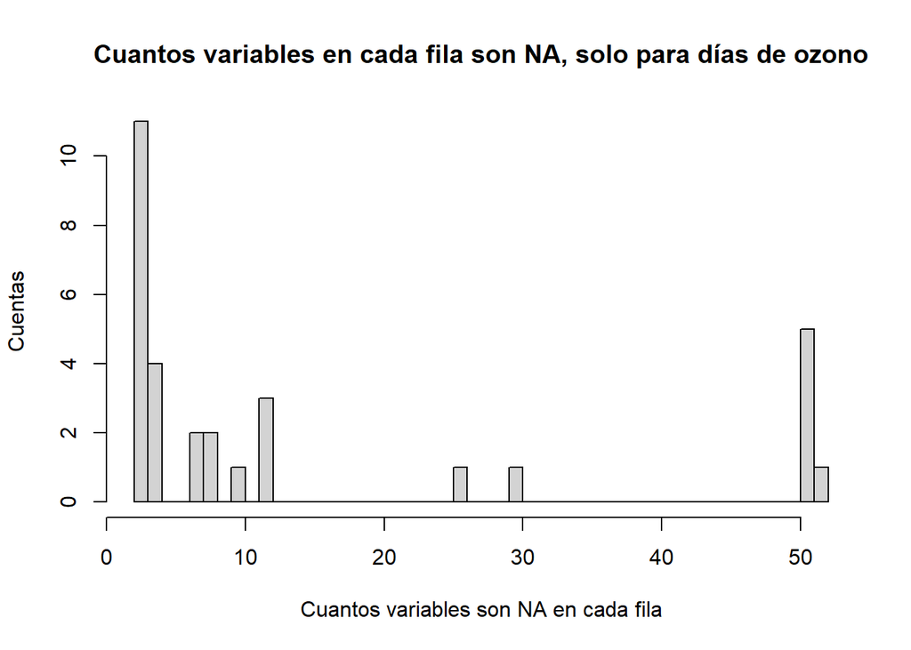

```r
count_nas_in_row_if_Oz <- function(vect){
    if (rev(vect)[1] == 1 | rev(vect)[2] == 1) {
      n = sum(is.na(vect))
      if (n==0) {
        return (NA)
      }
      else return (n)
    }
    else return (NA)
}

# sweep by rows (margin = 1)
na_count_oz <- apply(data_norm, MARGIN=1, count_nas_in_row_if_Oz)

# histogram count of NAs per row
# Note, zeros will be excluded because are "NA" instead from function
hist(na_count_oz, breaks=50, xlab="Cuantos variables son NA en cada fila", ylab="Cuentas", main="Cuantos variables en cada fila son NA, solo para días de ozono")
```

Muchos menos, pero esos son los que necesitan más que los otros esfuerzos de rescate.

Por ejemplo, aquí solo hay un caso de 26 faltando, comparado a muchos (aprox. 80) en los días sin ozono.

Investigamos los casos. Primero, registros de ozono que faltan solo dos campos:

```r
data_norm[which(na_count_oz == 2), ]
```

```
##            DATE WSR0 WSR1 WSR2 WSR3 WSR4 WSR5 WSR6 WSR7 WSR8 WSR9 WSR10 WSR11
## 127  1998-05-07 0.21 0.18 0.14 0.15 0.32 0.26   NA 0.32 0.32 0.28  0.24  0.21
## 128  1998-05-08 0.14 0.17 0.13 0.06 0.08 0.13 0.20 0.24 0.35 0.45  0.44  0.47
## 234  1998-08-26 0.00 0.00 0.02 0.04 0.03 0.07 0.08 0.13 0.15 0.18  0.21  0.24
## 843  2000-05-03 0.11 0.05 0.14 0.14 0.21 0.14 0.13 0.16 0.16 0.08  0.07  0.18
## 1908 2003-04-12 0.04 0.00 0.01 0.00 0.00 0.00 0.01 0.04 0.06 0.04  0.09  0.18
## 1945 2003-05-19 0.10 0.06 0.07 0.07 0.04 0.08 0.09 0.15 0.21 0.16  0.13  0.12
## 2270 2004-04-09 0.04 0.03 0.03 0.02 0.01 0.00 0.01 0.01 0.05 0.06  0.12  0.11
## 2372 2004-07-20 0.06 0.02 0.02 0.03 0.04 0.04 0.13 0.17 0.18 0.14  0.17  0.23
## 2400 2004-08-17 0.04 0.01 0.03 0.05 0.05 0.05 0.05 0.13 0.16 0.16  0.21  0.26
## 2432 2004-09-18 0.02 0.00 0.02 0.02 0.04 0.03 0.01 0.04 0.06 0.05  0.12  0.13
## 2444 2004-09-30 0.04 0.09 0.11 0.10 0.11 0.10 0.13 0.17 0.22 0.25  0.18  0.06
##      WSR12 WSR13 WSR14 WSR15 WSR16 WSR17 WSR18 WSR19 WSR20 WSR21 WSR22 WSR23
## 127   0.16  0.14  0.09  0.09  0.12  0.26  0.21  0.19  0.16  0.14  0.14  0.19
## 128   0.53  0.56  0.62  0.60  0.59  0.59  0.52  0.51  0.42  0.30  0.34  0.29
```

[output cut: 57 more lines]

Esos casos faltan todos una pareja de Uxx, Vxx, de la misma altitud. Esos son direcciones de viento, y no hay manera razonable no logística de remplazarles. Se podría usar inferencia por kNN para crear sustitutos, pero es difícil saber el impacto sobre los modelos posteriores. Lo haremos (para todas las filas) y aceptaremos el riesgo, con el beneficio presunto de rescatar al menos esos 11 casos de ozono.

### 3.5.2 Inferencia valores NA para variables Uxx, Vxx con kNN

Haremos inferencia usando kNN para rellenar valores perdidos Uxx, Vxx. Se podría hacer un argumento de separar las filas en días de ozono y de no ozono, antes de hacer el paso, pero no veo la utilidad, como que no tienen circunstancias totalmente independientes. Usaremos un valor modesto de k = 5, que dará, presuntamente, un rango más amplio de valores imputados, por ser más granular.

Tampoco podemos decir bien cuales otras variables tomar en cuenta cuando hacemos el kNN(). Por defecto usará todos los atributos. Para quedar con una solución mínima, usaré solo las otras variables Uxx, Vxx, y no todas.

Nota: se usara el kNN() del paquete VIM, usando la distancia Gower.

```r
# First copy dataframe into new name for safety
data_cleaned <- data_norm
```

Tenemos de momento 180 en cada U85 y V85, por ejemplo:

```r
summary(data_cleaned$U85)
```

```
##     Min.  1st Qu.   Median     Mean  3rd Qu.     Max.     NA's
## -0.31540 -0.01920  0.03760  0.04277  0.10050  0.37120      180
```

```r
summary(data_cleaned$V85)
```

```
##     Min.  1st Qu.   Median     Mean  3rd Qu.     Max.     NA's
## -0.36200 -0.04720  0.03120  0.03336  0.11445  0.44320      180
```

Cuantos podremos imputar así? Para saber, tenemos que verificamos cuantos filas solo falta una pareja de Uxx, Vxx y no más. Podemos usar la función hecho arriba, ¨count_nas_in_row():

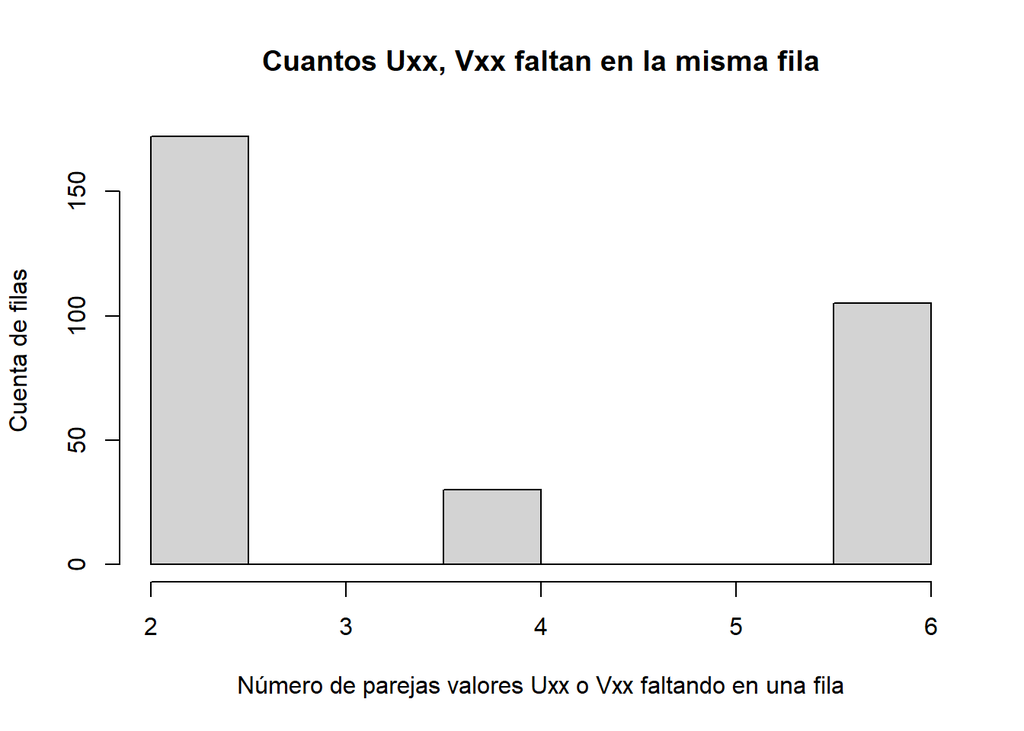

```r
# check how many pairs of Uxx, Vxx are missing
hist(apply(data_norm[,c("U70", "V70", "U50", "V50", "U85", "V85")], MARGIN=1, count_nas_in_row), main="Cuantos Uxx, Vxx faltan en la misma fila", xlab="Número de parejas valores Uxx o Vxx faltando en una fila", ylab = "Cuenta de filas")
```

Entonces, podemos corregir >150 filas de la forma planificada, pero ~ 130 otras filas tienen o 4 o 6 valores NAs en los Uxx/Vxx y no se puede imputar los valores que faltan.

La idea es de imputamos los dos a la vez, haciendo referencia solo a los otros Uxx, Vxx.

Haciendo unas pruebas antes, se nota que kNN() imputa valores incluso cuando no hay otros valores de Uxx, Vxx. Injerta valores que parecen cerca de la media del valor en cuestión, pero no exactamente. Para evitar ese fenomeno, cuyo impacto no se puede determinar, se dará un conjunto reducido a kNN(), de solo las filas que queremos, cada vez. Por decir, cuando imputamos V85, U85, por ejemplo, solo daremos fila que contengan valores reales para el resto de los Uxx, Vxx.

```r
# We wanted to isolate all row indices where we do have all values for U50, V50, U70, V70
# for both missing and not missing U85, V85, to impute these two variables, only when other 4 variables exist.
U85V85.indices.to.impute <- which(!is.na(data_cleaned$U50)
                                  & !is.na(data_cleaned$U70)
                                  & !is.na(data_cleaned$V50)
                                  & !is.na(data_cleaned$V70)
                                  )

U85V85.imputed.values <- kNN(data_cleaned[U85V85.indices.to.impute, c("U70", "V70", "U50", "V50", "U85", "V85")],
                             variable=c("U85", "V85"), k=5)

head(U85V85.imputed.values[U85V85.imputed.values$U85_imp == TRUE, ])
```

```
##         U70     V70     U50     V50     U85     V85 U85_imp V85_imp
## 20   0.2326  0.1726  0.4222  0.2412  0.1284  0.1110    TRUE    TRUE
## 112  0.1306 -0.0462  0.3706 -0.2414  0.0900 -0.0694    TRUE    TRUE
## 115  0.3224  0.0264  0.5000 -0.0456  0.2136  0.0502    TRUE    TRUE
## 198 -0.0448 -0.0594 -0.0338 -0.0674 -0.0174 -0.0434    TRUE    TRUE
## 205 -0.1264 -0.0622 -0.0704  0.0424 -0.0194 -0.0160    TRUE    TRUE
## 226 -0.0674 -0.0576 -0.1032 -0.0722 -0.0174 -0.0560    TRUE    TRUE
```

```r
#data_cleaned_test <- kNN(data_cleaned[,c("U70", "V70", "U50", "V50", "U85", "V85")], variable=c("U85", "V85"), k=5)
#data_cleaned <- kNN(data_cleaned[,c("U70", "V70", "U50", "V50")], variable="V85", k=5)
```

Ahora podemos hacer lo mismo para las otras dos parejas. Al final, incorporaremos los valores imputados usando los indicios respectivos. No lo hacemos antes del próximo imputación, sino estaremos imputamos valores a partir de otros valores también imputados. No estaremos incorporando las columnas añadidas por kNN() que indica cuales son imputados.

```r
# We wanted to isolate all row indices where we do have all values for U50, V50, U85, V85
# for both missing and not missing U70, V70, to impute these two variables, only when other 4 variables exist.
U70V70.indices.to.impute <- which(!is.na(data_cleaned$U50)
                                  & !is.na(data_cleaned$U85)
                                  & !is.na(data_cleaned$V50)
                                  & !is.na(data_cleaned$V85)
                                  )

U70V70.imputed.values <- kNN(data_cleaned[U70V70.indices.to.impute, c("U70", "V70", "U50", "V50", "U85", "V85")],
                             variable=c("U70", "V70"), k=5)

head(U70V70.imputed.values[U70V70.imputed.values$U70_imp == TRUE, ])
```

```
##        U70     V70    U50     V50     U85     V85 U70_imp V70_imp
## 33  0.2580  0.0080 0.4208  0.0454 -0.0092 -0.0500    TRUE    TRUE
## 222 0.0106  0.0190 0.1138 -0.0050 -0.0176  0.0166    TRUE    TRUE
## 309 0.2134  0.2490 0.2690  0.4306  0.2490  0.1388    TRUE    TRUE
## 361 0.1378 -0.2004 0.4036 -0.2134  0.0442 -0.1328    TRUE    TRUE
## 380 0.1474 -0.0680 0.3080 -0.2272  0.0506 -0.0472    TRUE    TRUE
## 399 0.3590  0.0382 0.6592  0.0756  0.1064 -0.0764    TRUE    TRUE
```

```r
#data_cleaned_test <- kNN(data_cleaned[,c("U70", "V70", "U50", "V50", "U85", "V85")], variable=c("U85", "V85"), k=5)
#data_cleaned <- kNN(data_cleaned[,c("U70", "V70", "U50", "V50")], variable="V85", k=5)
```

```r
# We wanted to isolate all row indices where we do have all values for U70, V70, U85, V85
# for both missing and not missing U50, V50, to impute these two variables, only when other 4 variables exist.
U50V50.indices.to.impute <- which(!is.na(data_cleaned$U70)
                                  & !is.na(data_cleaned$U85)
                                  & !is.na(data_cleaned$V70)
                                  & !is.na(data_cleaned$V85)
                                  )

U50V50.imputed.values <- kNN(data_cleaned[U50V50.indices.to.impute, c("U70", "V70", "U50", "V50", "U85", "V85")],
                             variable=c("U50", "V50"), k=5)

head(U50V50.imputed.values[U50V50.imputed.values$U50_imp == TRUE, ])
```

```
##       U70     V70    U50     V50    U85     V85 U50_imp V50_imp
## 8  0.3050 -0.1156 0.4688 -0.0990 0.2608 -0.0846    TRUE    TRUE
## 39 0.4808  0.0930 0.6342  0.3230 0.3712 -0.1070    TRUE    TRUE
## 46 0.3970 -0.0214 0.4942  0.0196 0.2394 -0.0780    TRUE    TRUE
## 57 0.3714  0.0364 0.4500  0.0518 0.2288 -0.0120    TRUE    TRUE
## 65 0.4422 -0.1402 0.6342 -0.1500 0.2650 -0.2392    TRUE    TRUE
## 92 0.5078  0.0176 0.6342  0.1326 0.2130 -0.1786    TRUE    TRUE
```

Ahora incorporamos los valores imputados remplazados las parejas de NAs.

```r
data_cleaned[U85V85.indices.to.impute, c("U85", "V85")] <- U85V85.imputed.values[, c("U85", "V85")]

data_cleaned[U70V70.indices.to.impute, c("U70", "V70")] <- U70V70.imputed.values[, c("U70", "V70")]

data_cleaned[U50V50.indices.to.impute, c("U50", "V50")] <- U50V50.imputed.values[, c("U50", "V50")]
```

Y verifiquemos ahora como estamos de cantidades NA en esos variables Uxx, Vxx:

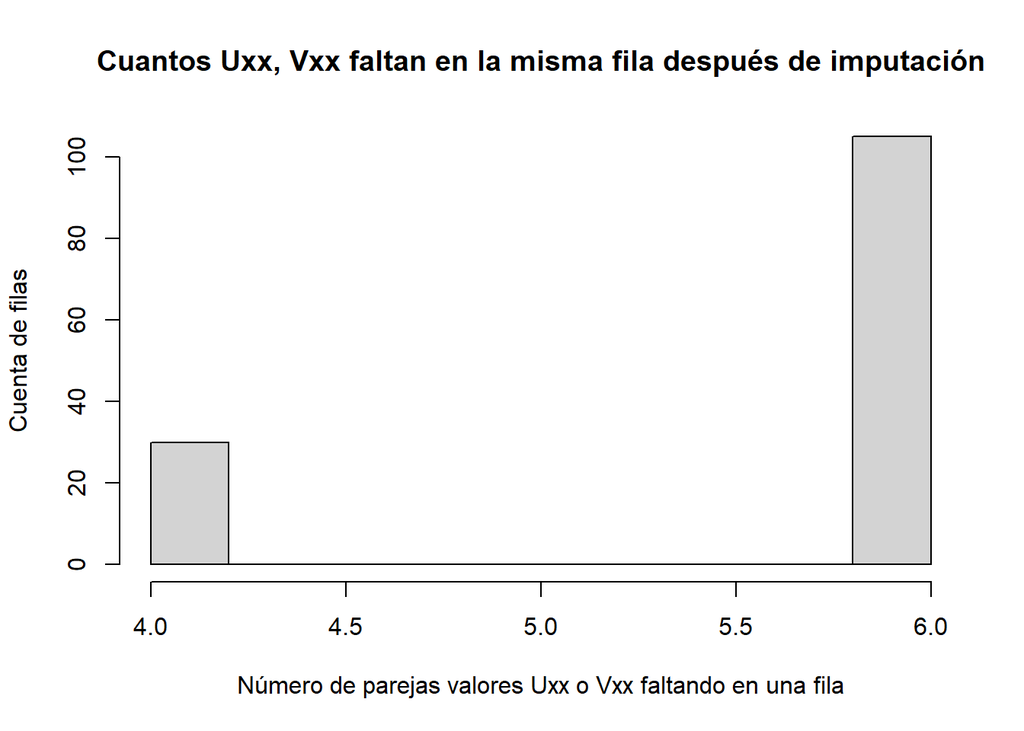

```r
# check how many pairs of Uxx, Vxx are missing after imputation with kNN
hist(apply(data_cleaned[,c("U70", "V70", "U50", "V50", "U85", "V85")], MARGIN=1, count_nas_in_row), main="Cuantos Uxx, Vxx faltan en la misma fila después de imputación", xlab="Número de parejas valores Uxx o Vxx faltando en una fila", ylab = "Cuenta de filas")
```

Entonces, hemos arreglado todos las parejas de dos que faltaban, como esperado. Nos quedamos con filas que tienen o 4 o 6 valores NAs en lo Uxx, Vxx, por tener menos apoyo en valores reales para imputar los que faltan.

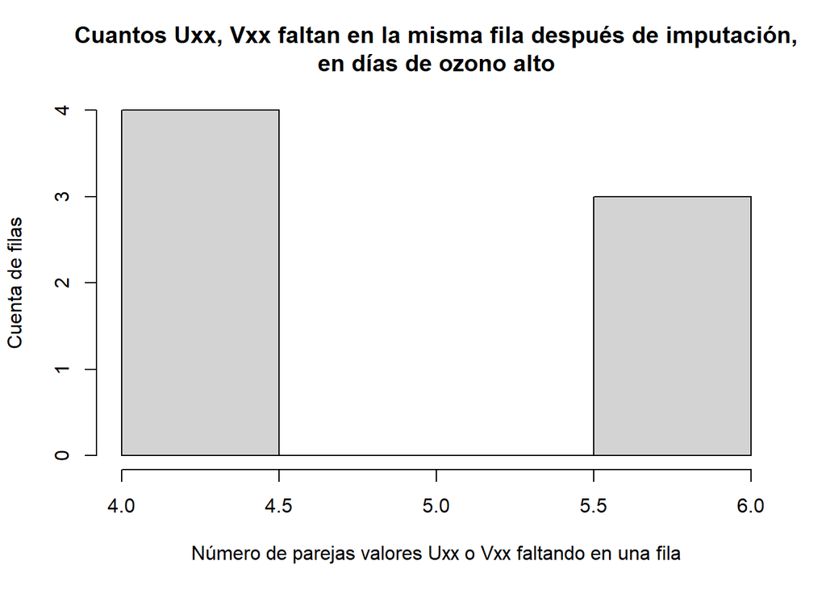

```r
# check how many pairs of Uxx, Vxx are missing after imputation with kNN
hist(apply(data_cleaned[,c("U70", "V70", "U50", "V50", "U85", "V85", "OzoneDay1hPeak", "Oz8h")], MARGIN=1, count_nas_in_row_if_Oz), main="Cuantos Uxx, Vxx faltan en la misma fila después de imputación,\nen días de ozono alto", xlab="Número de parejas valores Uxx o Vxx faltando en una fila", ylab = "Cuenta de filas")
```

Entonces tenemos 7 casos así en días de ozono. No olvidamos que puede ser que más que esos variables faltan además que los Uxx, Vxx.

### 3.5.3 Inferencia valores NA para variables WSRxx, Txx por funciones

Repetimos la verificación de cuantos NAs existen ahora en filas de días de ozono, para planificar los próximos pasos:

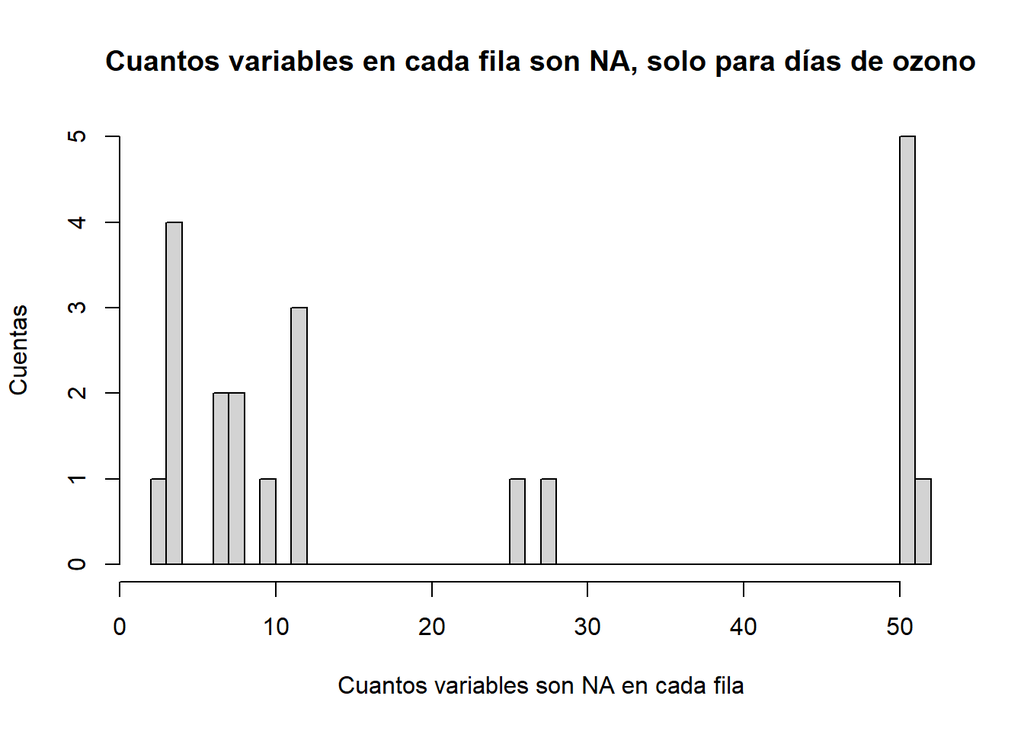

```r
# sweep by rows (margin = 1) on Cleaned data frame
na_count_oz <- apply(data_cleaned, MARGIN=1, count_nas_in_row_if_Oz)

# histogram count of NAs per row
# Note, zeros will be excluded because are "NA" instead from function
hist(na_count_oz, breaks=50, xlab="Cuantos variables son NA en cada fila", ylab="Cuentas", main="Cuantos variables en cada fila son NA, solo para días de ozono")
```

Cuales variables faltan por el caso de 2, 4, 7, o 8 NAs?

```r
table(na_count_oz)
```

```
## na_count_oz
##  2  4  7  8 10 12 26 28 51 52
##  1  4  2  2  1  3  1  1  5  1
```

```r
data_cleaned[which(na_count_oz == 2), ]
```

```
##           DATE WSR0 WSR1 WSR2 WSR3 WSR4 WSR5 WSR6 WSR7 WSR8 WSR9 WSR10 WSR11
## 127 1998-05-07 0.21 0.18 0.14 0.15 0.32 0.26   NA 0.32 0.32 0.28  0.24  0.21
##     WSR12 WSR13 WSR14 WSR15 WSR16 WSR17 WSR18 WSR19 WSR20 WSR21 WSR22 WSR23
## 127  0.16  0.14  0.09  0.09  0.12  0.26  0.21  0.19  0.16  0.14  0.14  0.19
##     WSR_PK WSR_AV    T0   T1    T2    T3    T4    T5 T6    T7    T8    T9   T10
## 127   0.32    0.2 0.544 0.54 0.538 0.544 0.558 0.564 NA 0.584 0.606 0.634 0.666
##       T11   T12   T13  T14   T15  T16   T17   T18   T19   T20   T21   T22   T23
## 127 0.706 0.736 0.754 0.78 0.798 0.81 0.762 0.702 0.678 0.654 0.626 0.602 0.578
##     T_PK       T85 RH85    U85   V85       T70    U70     V70       T50 RH50
## 127 0.81 0.9651899 0.28 0.1526 0.074 0.8007663 0.2354 -0.0932 0.7878788 0.18
##        U50     V50  SLP Precp OzoneDay1hPeak Oz8h
## 127 0.4318 -0.1352 0.24     0              1    1
```

```r
data_cleaned[which(na_count_oz == 4), ]
```

```
##            DATE WSR0 WSR1 WSR2 WSR3 WSR4 WSR5 WSR6 WSR7 WSR8 WSR9 WSR10 WSR11
## 922  2000-07-21 0.17 0.26 0.16 0.10 0.17 0.21 0.32 0.31 0.25   NA    NA  0.25
## 925  2000-07-24 0.09 0.10 0.12 0.09 0.05 0.04 0.10 0.09 0.13 0.12  0.21  0.15
## 1319 2001-08-22 0.07 0.14 0.13 0.07 0.09 0.08 0.08 0.20 0.30 0.33  0.35  0.34
## 2387 2004-08-04 0.06 0.12 0.08 0.04 0.04 0.04 0.05 0.24 0.27 0.23  0.17  0.13
##      WSR12 WSR13 WSR14 WSR15 WSR16 WSR17 WSR18 WSR19 WSR20 WSR21 WSR22 WSR23
## 922   0.11  0.09  0.14  0.20  0.17  0.25  0.43  0.29  0.25  0.24  0.19  0.19
## 925   0.13  0.09  0.10  0.21  0.14  0.15  0.14  0.09  0.15  0.17  0.15  0.11
## 1319  0.34  0.34  0.37  0.46  0.43  0.41  0.33    NA    NA  0.12  0.09  0.11
## 2387  0.05  0.07  0.10  0.11  0.15  0.18  0.19  0.23  0.17  0.12  0.14  0.12
##      WSR_PK WSR_AV    T0    T1    T2    T3    T4    T5    T6    T7    T8    T9
## 922    0.43   0.22 0.644 0.638 0.632 0.622 0.612 0.612 0.622 0.636 0.656    NA
## 925    0.21   0.12 0.564 0.556 0.554 0.554 0.552 0.552 0.566 0.582 0.596 0.622
## 1319   0.46   0.24 0.618 0.618 0.616 0.610 0.598 0.602 0.612 0.652 0.686 0.716
## 2387   0.27   0.13 0.654 0.646 0.642 0.634 0.634 0.638 0.636 0.656 0.680 0.708
##        T10   T11   T12   T13   T14   T15   T16   T17   T18   T19   T20   T21
## 922     NA 0.750 0.784 0.806 0.818 0.822 0.834 0.822 0.766 0.740 0.712 0.688
## 925  0.660 0.684 0.704 0.724 0.742 0.758 0.762 0.764 0.752 0.718 0.676 0.654
## 1319 0.738 0.750 0.772 0.778 0.778 0.768 0.758 0.738 0.710    NA    NA 0.646
## 2387 0.728 0.750 0.762 0.778 0.786 0.794 0.798 0.790 0.762 0.724 0.702 0.686
##        T22   T23  T_PK       T85 RH85     U85   V85       T70    U70   V70
## 922  0.664 0.650 0.834 0.9240506 0.36 -0.0198 0.003 0.7701149 -0.036 0.034
## 925  0.640 0.630 0.764 0.7626582 0.68      NA    NA 0.6475096     NA    NA
## 1319 0.634 0.626 0.778 0.8386076 0.49 -0.0594 0.103 0.6858238 -0.114 0.056
## 2387 0.674 0.662 0.798 0.8575949 0.38      NA    NA 0.7011494     NA    NA
##            T50 RH50     U50     V50       SLP Precp OzoneDay1hPeak Oz8h
## 922  0.7792208 0.18  0.0016  0.0354 0.4266667     0              1    1
## 925  0.6796537 0.40  0.2004 -0.2098 0.4800000     0              0    1
## 1319 0.8441558 0.11 -0.0656 -0.0580 0.5200000     0              0    1
## 2387 0.8831169 0.13 -0.1798 -0.1648 0.3733333     0              0    1
```

```r
data_cleaned[which(na_count_oz == 7), ]
```

```
##           DATE WSR0 WSR1 WSR2 WSR3 WSR4 WSR5 WSR6 WSR7 WSR8 WSR9 WSR10 WSR11
## 236 1998-08-28 0.11 0.12 0.08 0.05 0.08 0.10 0.10 0.21 0.27 0.21  0.19  0.08
## 572 1999-08-05 0.02 0.07 0.08 0.06 0.07 0.11 0.08 0.10 0.21 0.18  0.17  0.13
##     WSR12 WSR13 WSR14 WSR15 WSR16 WSR17 WSR18 WSR19 WSR20 WSR21 WSR22 WSR23
## 236  0.02  0.08  0.06  0.12  0.16  0.19  0.11  0.15  0.13  0.12  0.15  0.15
## 572  0.20  0.24  0.30  0.35  0.30  0.28  0.23  0.16  0.18  0.16  0.12  0.05
##     WSR_PK WSR_AV    T0    T1    T2    T3    T4    T5    T6    T7    T8    T9
## 236   0.27   0.13 0.646 0.634 0.618 0.612 0.610 0.610 0.612 0.646 0.692 0.724
## 572   0.35   0.16 0.632 0.624 0.624 0.620 0.616 0.612 0.610 0.652 0.688 0.726
##       T10   T11   T12   T13   T14   T15   T16   T17   T18   T19   T20   T21
## 236 0.752 0.780 0.796 0.806 0.814 0.822 0.822 0.806 0.766 0.734 0.710 0.692
## 572 0.766 0.788 0.808 0.816 0.826 0.828 0.818 0.806 0.778 0.744 0.722 0.698
##       T22   T23  T_PK       T85 RH85     U85     V85 T70 U70 V70 T50 RH50 U50
## 236 0.682 0.674 0.822 0.8607595 0.66 -0.0954 -0.0256  NA  NA  NA  NA   NA  NA
## 572 0.690 0.662 0.828 0.8765823 0.34 -0.0826 -0.1180  NA  NA  NA  NA   NA  NA
##     V50  SLP Precp OzoneDay1hPeak Oz8h
## 236  NA 0.44     0              0    1
## 572  NA 0.40     0              0    1
```

```r
data_cleaned[which(na_count_oz == 8), ]
```

```
##           DATE WSR0 WSR1 WSR2 WSR3 WSR4 WSR5 WSR6 WSR7 WSR8 WSR9 WSR10 WSR11
## 270 1998-10-01   NA   NA   NA   NA   NA   NA   NA   NA 0.14 0.13  0.04  0.17
## 480 1999-04-29 0.08 0.01 0.03 0.02 0.02  0.1  0.1 0.06 0.20 0.23  0.21  0.21
##     WSR12 WSR13 WSR14 WSR15 WSR16 WSR17 WSR18 WSR19 WSR20 WSR21 WSR22 WSR23
## 270  0.20  0.20  0.25  0.32  0.34  0.26  0.13  0.11  0.04  0.04  0.04  0.04
## 480  0.21  0.25  0.27  0.22  0.24  0.27  0.22  0.13  0.16  0.14  0.27  0.39
##     WSR_PK WSR_AV    T0    T1    T2    T3    T4    T5    T6   T7    T8    T9
## 270   0.34   0.15 0.602 0.594 0.588 0.578 0.574 0.572 0.576 0.61 0.666 0.694
## 480   0.39   0.17    NA    NA    NA    NA    NA    NA    NA   NA 0.442 0.528
##       T10   T11   T12   T13   T14   T15   T16   T17   T18   T19   T20   T21
## 270 0.728 0.756 0.766 0.772 0.764 0.760 0.744 0.718 0.674 0.650 0.628 0.614
## 480 0.612 0.656 0.698 0.708 0.722 0.734 0.720 0.700 0.668 0.628 0.606 0.588
##       T22   T23  T_PK       T85 RH85     U85     V85       T70     U70     V70
## 270 0.598 0.590 0.772 0.8291139 0.55 -0.0306 -0.0160 0.7701149 -0.1326 -0.0472
## 480 0.578 0.566 0.734 0.7373418 0.56 -0.0310  0.0308 0.5593870  0.0732 -0.1752
##           T50 RH50    U50     V50       SLP Precp OzoneDay1hPeak Oz8h
## 270 0.8398268 0.07 0.0142  0.0388 0.4000000     0              1    1
## 480 0.5497835 0.37 0.2858 -0.1506 0.3466667     0              0    1
```

Aquí tenemos:

- 2NAs: un caso con un valor de WSR6 y T6 que faltan
- 4NAs: dos casos de dos parejas de Uxx, Vxx, pero también dos casos de dos horas de WSR o T que faltan.
- 7NAs: dos casos de datos diarios T70, U70, V70, T50, RH50, U50, V50 que faltan
- 8NAs: un caso que falta T0-T7, y otro que falta WSR0-WSR7

Que podemos hacer:

- Para imputar valores horarios de velocidad del viento (WSR), podremos remplazarlo, por ejemplo, por la media del WSR del día, el WSR_AV. Notamos que (verificado por separado), los valores WSR_AV solo se basan en los valores disponibles en los datos. Por tanto, si hay 22 WSRxx, el valor de WSR_AV es la media de esos 22 valores, no tiene ninguna información sobre los valores que faltan.
- Para imputar valores horarios de las temperaturas, que faltan en horas intermedias del día, podremos hacer una linea recta de regresión (no estadística), entre los valores que existen a los margenes del hueco donde falta. Pero, para que sea razonable, no debemos imputar así a través un hueco que incluye los valores más altos del día, digamos desde las T13 hasta las T16. Sino, estaremos cortando la parte alta de la curva presunta de temperatura para ese día. Para tratar huecos allí, podremos en lugar repetir el valor más alto de los margenes. Por ejemplo, si falta T14, T15, usamos el más alto de T13, T16. Tendremos que escribir una función para hacer esos cálculos. Tenemos la temperatura máxima todavía pero no la media, entonces no hay que actualizarla. Igualmente, si tenemos un hueco que ya empieza con T00 o acaba con T23, con la lógica aquí, no hay manera de tratarlo (sin hacer referencia a datos del día previa).
- Valores de temperaturas horarias que faltan desde T0 o hasta T23, solo podemos tratar después de crear los clusters de vectores de temperatura, si se puede medir la distancias hacía los centros de cada cluster, por los atributos que tenemos a disposición. Eso haremos en pasos posteriores.

#### 3.5.3.1 Imputación de WSRxx

```r
# Process WSR hourly data, per register, to overwrite NAs with average daily WSR
wsr_inference <- function(register) {
  # Step through all WSRxx values
  for (xx in (0:23)) {
    # If a WSRxx is NA, replace with WSR_AV
    if (is.na(register[[glue("WSR{xx}")]])) {
      register[[glue("WSR{xx}")]] <- register[["WSR_AV"]]
    }
  }
  return (register)
}
```

Notamos que la función usará WSR_AV de valor NA en el caso de una fila sin ninguna información de WSR, y por tanto, no lo cambiará.

```r
# Example row with missing WSR00-WSR07
data_cleaned[270, ]
```

```
##           DATE WSR0 WSR1 WSR2 WSR3 WSR4 WSR5 WSR6 WSR7 WSR8 WSR9 WSR10 WSR11
## 270 1998-10-01   NA   NA   NA   NA   NA   NA   NA   NA 0.14 0.13  0.04  0.17
##     WSR12 WSR13 WSR14 WSR15 WSR16 WSR17 WSR18 WSR19 WSR20 WSR21 WSR22 WSR23
## 270   0.2   0.2  0.25  0.32  0.34  0.26  0.13  0.11  0.04  0.04  0.04  0.04
##     WSR_PK WSR_AV    T0    T1    T2    T3    T4    T5    T6   T7    T8    T9
## 270   0.34   0.15 0.602 0.594 0.588 0.578 0.574 0.572 0.576 0.61 0.666 0.694
##       T10   T11   T12   T13   T14  T15   T16   T17   T18  T19   T20   T21   T22
## 270 0.728 0.756 0.766 0.772 0.764 0.76 0.744 0.718 0.674 0.65 0.628 0.614 0.598
##      T23  T_PK       T85 RH85     U85    V85       T70     U70     V70
## 270 0.59 0.772 0.8291139 0.55 -0.0306 -0.016 0.7701149 -0.1326 -0.0472
##           T50 RH50    U50    V50 SLP Precp OzoneDay1hPeak Oz8h
## 270 0.8398268 0.07 0.0142 0.0388 0.4     0              1    1
```

```r
# Apply WSR function per row, overwriting each row with inferred WSR data when NAs exist
for (i in (1: nrow(data_cleaned))) {
  data_cleaned[i, ] <- wsr_inference(data_cleaned[i, ])
}
```

```r
# Confirm values replaced with WSR_AV
data_cleaned[270, ]
```

```
##           DATE WSR0 WSR1 WSR2 WSR3 WSR4 WSR5 WSR6 WSR7 WSR8 WSR9 WSR10 WSR11
## 270 1998-10-01 0.15 0.15 0.15 0.15 0.15 0.15 0.15 0.15 0.14 0.13  0.04  0.17
##     WSR12 WSR13 WSR14 WSR15 WSR16 WSR17 WSR18 WSR19 WSR20 WSR21 WSR22 WSR23
## 270   0.2   0.2  0.25  0.32  0.34  0.26  0.13  0.11  0.04  0.04  0.04  0.04
##     WSR_PK WSR_AV    T0    T1    T2    T3    T4    T5    T6   T7    T8    T9
## 270   0.34   0.15 0.602 0.594 0.588 0.578 0.574 0.572 0.576 0.61 0.666 0.694
##       T10   T11   T12   T13   T14  T15   T16   T17   T18  T19   T20   T21   T22
## 270 0.728 0.756 0.766 0.772 0.764 0.76 0.744 0.718 0.674 0.65 0.628 0.614 0.598
##      T23  T_PK       T85 RH85     U85    V85       T70     U70     V70
## 270 0.59 0.772 0.8291139 0.55 -0.0306 -0.016 0.7701149 -0.1326 -0.0472
##           T50 RH50    U50    V50 SLP Precp OzoneDay1hPeak Oz8h
## 270 0.8398268 0.07 0.0142 0.0388 0.4     0              1    1
```

#### 3.5.3.2 Imputación Txx

Ahora creamos la función para procesar los valores Txx según lo que hemos descrito antes.

```r
temp_inference <- function(register) {
  left <- c(NA,NA)      # Ongoing possible left side of hole
  right <- c(NA,NA)     # Confirmed right side of hole
  hole <- FALSE   # Does current register contain a hole
  to.be.fixed <- FALSE  # Can current register's hole be remedied

  # Exploratory for loop, to look for valid holes
  for (xx in (0:23)) {
    label <- glue("T{xx}")
    # store current value as tuple of position and value
    current <- as.numeric(c(xx, register[[label]]))

    if (is.na(current[2])) {
      if (!hole & xx != 0 & xx != 23) {
        # if current is NA, hole is not previously flagged,
        # and hole is not at T00 or T23, we've found the start of a possibly treatable hole
        if (!is.na(left[2])) {
          # However, don't recognize as hole unless we've already identified a valid left side
          hole <- TRUE
        }
      }
      # If NAs starting at T00 or going to T23, don't recognize as hole
    }
    else {
      # If Txx not NA, check if possible left or right side of a hole
      if (hole) {
        if (is.na(right[2])) {
          # if we'd been in a hole and no right value found yet, we've found the right side of hole
          right <- current
          # mark treatable hole
          to.be.fixed <- TRUE
        }
        # In case right is not NA, it means we've already found the right side of the hole.
      }
      else {
        # if no hole yet identified, then drag along current value as possible left side of hole
        left <- current
      }
    }
  }  # end of exploratory for loop

  # Loop to fix identified hole to be fixed.
  if (to.be.fixed) {
    # how many points to bridge
    gap.size = right[1] - left[1] - 1
    temp.fill.step = round((right[2] - left[2]) / (gap.size+1), 3)
    left.edge <- left[1]
    right.edge <- right[1]

    if (right.edge<14 | left.edge>15) {
      # if gap does not cover any of T13-T16 inclusive, then use linear model
      for (i in (1:gap.size)) {
        xx <- ((left.edge+1):(right.edge-1))[i]
        label <- glue("T{xx}")
        register[[label]] <- as.numeric(left[2] + i*temp.fill.step)
      }
    }
    else if (left.edge>=12 & right.edge<=17) {
      # if gap is only in 13;16 inclusive, fill with T_PK value
      for (i in (1:gap.size)) {
        xx <- ((left.edge+1):(right.edge-1))[i]
        label <- glue("T{xx}")
        register[[label]] <- as.numeric(register[["T_PK"]])
      }
    }
    else if (left.edge>=12 & right.edge>17) {
      # if gap includes 13;16 plus more after, fill with T_PK value in 13:16 then linear after
      # no compensation for larger step size needed is coded (yet)
      for (i in (1:gap.size)) {
        xx <- ((left.edge+1):(right.edge-1))[i]
        label <- glue("T{xx}")
        if (xx<=16) {
          register[[label]] <- as.numeric(register[["T_PK"]])
        }
        else {
          # remaining Txx values are filled in using linear model as if T_PK not used at all
          register[[label]] <- as.numeric(left[2] + i*temp.fill.step)
        }
      }
    }
    else if (left.edge<12 & right.edge<=17) {
      # if gap includes 13:16 but starts to the left, fill 13:16 with T_PK value and linear before
      # But linear on left side needs to go UP to T_PK value
      temp.fill.to.PK <- (as.numeric(register[["T_PK"]]) - left[2]) / (13-left.edge)
      for (i in (1:gap.size)) {
        xx <- ((left.edge+1):(right.edge-1))[i]
        label <- glue("T{xx}")
        if (xx>12) {
          register[[label]] <- as.numeric(register[["T_PK"]])
        }
        else {
          # remaining Txx values are filled in using linear model as if T_PK not used at all
          register[[label]] <- as.numeric(left[2] + i*temp.fill.to.PK)
        }
      }
    }
    else if (left.edge<12 & right.edge>17) {
      # if gap is wide and starts before 13:16 and ends after it, just replace all with T_PK
      for (i in (1:gap.size)) {
        xx <- ((left.edge+1):(right.edge-1))[i]
        label <- glue("T{xx}")
        register[[label]] <- as.numeric(register[["T_PK"]])
      }
    }
  }
  return (register)
}
```

Probamos para ver que funciona a la continuación, sin cambiar los datos todavía.

Buscando unos ejemplos donde tenemos NA en T0:

```r
head(data_cleaned[is.na(data_cleaned$T0), 28:52])
```

```
##      T0    T1    T2    T3    T4    T5    T6   T7    T8    T9   T10   T11   T12
## 479  NA    NA    NA    NA    NA    NA    NA   NA 0.578 0.642 0.684 0.706 0.722
## 480  NA    NA    NA    NA    NA    NA    NA   NA 0.442 0.528 0.612 0.656 0.698
## 485  NA    NA    NA    NA    NA    NA    NA   NA    NA    NA    NA    NA    NA
## 559  NA    NA    NA    NA    NA    NA    NA 0.62 0.650 0.672 0.688 0.708 0.726
## 627  NA    NA    NA    NA    NA    NA    NA   NA    NA 0.444 0.454 0.474 0.512
## 1307 NA 0.624 0.622 0.616 0.604 0.606 0.612 0.66 0.688 0.698 0.726 0.746 0.762
##        T13   T14   T15   T16   T17   T18   T19   T20   T21   T22   T23  T_PK
## 479  0.726 0.734 0.726 0.722 0.692 0.648 0.606 0.578 0.556    NA    NA 0.734
## 480  0.708 0.722 0.734 0.720 0.700 0.668 0.628 0.606 0.588 0.578 0.566 0.734
## 485  0.622 0.666 0.684 0.688 0.684 0.656 0.616 0.572 0.536 0.508 0.508 0.688
## 559  0.744 0.758 0.770 0.774 0.772 0.746 0.718 0.692 0.666 0.650 0.642 0.774
## 627  0.516 0.528 0.536 0.542 0.522 0.500 0.478 0.472 0.456 0.442 0.418 0.542
## 1307    NA    NA 0.710 0.730 0.726 0.714 0.696 0.680 0.668 0.658 0.648 0.762
```

Podemos ver que la linea 1307, aparte de faltar T0 - un tipo de agujero en los datos que no podemos tratar con la lógica anterior - falta T13, T14.

```r
temp_inference(data_cleaned[1307, 28:52])
```

```
##      T0    T1    T2    T3    T4    T5    T6   T7    T8    T9   T10   T11   T12
## 1307 NA 0.624 0.622 0.616 0.604 0.606 0.612 0.66 0.688 0.698 0.726 0.746 0.762
##        T13   T14  T15  T16   T17   T18   T19  T20   T21   T22   T23  T_PK
## 1307 0.762 0.762 0.71 0.73 0.726 0.714 0.696 0.68 0.668 0.658 0.648 0.762
```

Ahora después de llamar la función solo en esa fila, vemos que se han remplazado T13 y T14 con valores imputados según la lógica, pero T0 sigue NA.

Pero, aparte de señalar que la función es adecuado, subraya que tenemos muchas filas que faltan datos empezando con T0, cosa que no manejamos con la función. Si podríamos imputar un valor para T0 en esos casos, podremos usar la función después para rellenar el agujero. Una prueba no incluida aquí ha constatado que la función sin más solo puede corregir 58 filas.

Si imputamos T0 con kNN, solo haciendo referencia al campo DATE, puede ser que podremos tener un valor T0 razonable de fechas cercanas. Pero, después de unos experimentos, parece que VIM::kNN() no acepta fechas como tal, y, por consecuencia, no puede identificar las fechas cercanas. Se podría hacer una función para hacerlo, pero la complicación es que estamos implicando datos de varias filas a la vez. Dado que estamos solo mirando valores de T0, podremos hacerlo en dos pasos, primero haciendo un dataframe a medida para incluir más columnas para los T0 de, por ejemplo, dos fechas por adelante y dos siguientes, y segundo, tomando la media de los otros T0 cuando tenemos NA.

```r
# Create temp dataframe with blanks for two previous and two following T0 values
data_T0s <- cbind(data_cleaned[, c("DATE", "T0")], T_2=NA, T_1=NA, T.1=NA, T.2=NA)

T0s.before.after.add <- function(df)  {
  # For each row, fill in T0 from previous 2 and following 2 rows
  for (i in (1:nrow(df))) {
    if (i-2>0) {
      df$T_2[i] <- df$T0[i-2]
    }
    if (i-1>0) {
      df$T_1[i] <- df$T0[i-1]
    }
    if (i+1<=nrow(df)) {
      df$T.1[i] <- df$T0[i+1]
    }
    if (i+2<=nrow(df)) {
      df$T.2[i] <- df$T0[i+2]
    }
  }
  return (df)
}

# Process the temporary T0 data
data_T0s <- T0s.before.after.add(data_T0s)
head(data_T0s)
```

```
##         DATE    T0   T_2   T_1   T.1   T.2
## 1 1998-01-01 0.204    NA    NA 0.402 0.432
## 2 1998-01-02 0.402    NA 0.204 0.432 0.466
## 3 1998-01-03 0.432 0.204 0.402 0.466 0.476
## 4 1998-01-04 0.466 0.402 0.432 0.476 0.478
## 5 1998-01-05 0.476 0.432 0.466 0.478 0.412
## 6 1998-01-06 0.478 0.466 0.476 0.412 0.210
```

Verificamos cuantos casos tenemos de datos que faltan en su totalidad, que no dejaremos imputar un valor para T0:

```r
nrow(data_T0s[is.na(data_T0s$T0)
              & is.na(data_T0s$T_2)
              & is.na(data_T0s$T_1)
              & is.na(data_T0s$T.1)
              & is.na(data_T0s$T.2), ])
```

```
## [1] 171
```

```r
nrow(data_cleaned[is.na(data_cleaned$T0), ])
```

```
## [1] 190
```

Pues, resulta decepcionante, por que, de los casos en que falta el valor de T0, tendremos 171 de los 190 en que no hay valor T0 para los días vecinos [por que faltan en un bloque grande contiguo]. Aún así, continuamos con lo que se puede. Acabaremos teniendo que borrar más registros por falta de Txx que nos gustaría.

```r
# Function to average the other T0 values when T0 for current row is NA
avg.T0s.inference <- function(register) {
  if (is.na(register[2])) {
    mean.calc <- as.numeric(mean(as.numeric(register[3:6]), na.rm=TRUE))
    if (!is.nan(mean.calc)) {
      register[2] <- mean.calc
    }
  }
  return (register)
}

# Process the temporary T0 data to impute the NA values by averaging
data_T0s <- as.data.frame(t(apply(data_T0s, MARGIN=1, avg.T0s.inference)))
```

Ahora que tenemos la imputación por función, remplazamos los valores originales de T0 con los imputados.

```r
data_cleaned$T0 <- as.numeric(data_T0s$T0)
nrow(data_cleaned[is.na(data_cleaned$T0), ])
```

```
## [1] 171
```

Como esperado, nos quedamos con 171 casos de T0=NA sin poder corregirles.

Un ejemplo resuelto es la fila 1307 visto arriba:

```r
data_cleaned[1306:1308, 28:52]
```

```
##         T0    T1    T2    T3    T4    T5    T6    T7    T8    T9   T10   T11
## 1306 0.634 0.624 0.624 0.622 0.622 0.618 0.624 0.656 0.678 0.702 0.716 0.742
## 1307 0.637 0.624 0.622 0.616 0.604 0.606 0.612 0.660 0.688 0.698 0.726 0.746
## 1308 0.640    NA    NA 0.622 0.614 0.612 0.614 0.654 0.686 0.710 0.726 0.744
##        T12   T13   T14   T15   T16   T17   T18   T19   T20   T21   T22   T23
## 1306 0.762 0.764 0.742 0.642 0.656 0.668 0.674 0.674 0.666 0.656    NA    NA
## 1307 0.762    NA    NA 0.710 0.730 0.726 0.714 0.696 0.680 0.668 0.658 0.648
## 1308 0.758 0.774 0.790 0.796 0.780 0.752 0.722 0.704    NA 0.678    NA 0.658
##       T_PK
## 1306 0.764
## 1307 0.762
## 1308 0.796
```

Lógicamente, si tratamos de permitir el máximo de imputación por el modelo lineal, tendremos que hacer lo mismo con T23, el otro extremo, que hemos hecho con T0 anteriormente.

```r
# Create temp dataframe with blanks for two previous and two following T23 values
data_T23s <- cbind(data_cleaned[, c("DATE", "T23")], T_2=NA, T_1=NA, T.1=NA, T.2=NA)

T23s.before.after.add <- function(df)  {
  # For each row, fill in T23 from previous 2 and following 2 rows
  for (i in (1:nrow(df))) {
    if (i-2>0) {
      df$T_2[i] <- df$T23[i-2]
    }
    if (i-1>0) {
      df$T_1[i] <- df$T23[i-1]
    }
    if (i+1<=nrow(df)) {
      df$T.1[i] <- df$T23[i+1]
    }
    if (i+2<=nrow(df)) {
      df$T.2[i] <- df$T23[i+2]
    }
  }
  return (df)
}

# Process the temporary T23 data
data_T23s <- T23s.before.after.add(data_T23s)
head(data_T23s)
```

```
##         DATE   T23   T_2   T_1   T.1   T.2
## 1 1998-01-01 0.400    NA    NA 0.424 0.468
## 2 1998-01-02 0.424    NA 0.400 0.468 0.478
## 3 1998-01-03 0.468 0.400 0.424 0.478 0.482
## 4 1998-01-04 0.478 0.424 0.468 0.482 0.416
## 5 1998-01-05 0.482 0.468 0.478 0.416 0.214
## 6 1998-01-06 0.416 0.478 0.482 0.214 0.222
```

Verificamos cuantos casos tenemos de datos que faltan en su totalidad, que no dejaremos imputar un valor para T23:

```r
nrow(data_T23s[is.na(data_T23s$T23)
              & is.na(data_T23s$T_2)
              & is.na(data_T23s$T_1)
              & is.na(data_T23s$T.1)
              & is.na(data_T23s$T.2), ])
```

```
## [1] 171
```

```r
nrow(data_cleaned[is.na(data_cleaned$T23), ])
```

```
## [1] 189
```

Parecido a la situación con T0, resulta decepcionante, por que, de los casos en que falta el valor de T23, tendremos 171 de los 189 en que no hay valor T23 para los días vecinos [por que faltan en un bloque grande contiguo]. Aún así, continuamos con lo que se puede. Acabaremos teniendo que borrar más registros por falta de Txx que nos gustaría.

```r
# Function to average the other T23 values when T23 for current row is NA
avg.T23s.inference <- function(register) {
  if (is.na(register[2])) {
    mean.calc <- as.numeric(mean(as.numeric(register[3:6]), na.rm=TRUE))
    if (!is.nan(mean.calc)) {
      register[2] <- mean.calc
    }
  }
  return (register)
}

# Process the temporary T0 data to impute the NA values by averaging
data_T23s <- as.data.frame(t(apply(data_T23s, MARGIN=1, avg.T23s.inference)))
```

Ahora que tenemos la imputación por función, remplazamos los valores originales de T23 con los imputados.

```r
data_cleaned$T23 <- as.numeric(data_T23s$T23)
nrow(data_cleaned[is.na(data_cleaned$T23), ])
```

```
## [1] 171
```

Un ejemplo de bloques grandes de registros en que faltan datos horarios totalmente:

```r
data_cleaned[1634:1643, 1:52]
```

```
##            DATE WSR0 WSR1 WSR2 WSR3 WSR4 WSR5 WSR6 WSR7 WSR8 WSR9 WSR10 WSR11
## 1634 2002-07-03   NA   NA   NA   NA   NA   NA   NA   NA   NA   NA    NA    NA
## 1635 2002-07-04   NA   NA   NA   NA   NA   NA   NA   NA   NA   NA    NA    NA
## 1636 2002-07-05   NA   NA   NA   NA   NA   NA   NA   NA   NA   NA    NA    NA
## 1637 2002-07-08   NA   NA   NA   NA   NA   NA   NA   NA   NA   NA    NA    NA
## 1638 2002-07-09   NA   NA   NA   NA   NA   NA   NA   NA   NA   NA    NA    NA
## 1639 2002-07-10   NA   NA   NA   NA   NA   NA   NA   NA   NA   NA    NA    NA
## 1640 2002-07-11   NA   NA   NA   NA   NA   NA   NA   NA   NA   NA    NA    NA
## 1641 2002-07-12   NA   NA   NA   NA   NA   NA   NA   NA   NA   NA    NA    NA
## 1642 2002-07-13   NA   NA   NA   NA   NA   NA   NA   NA   NA   NA    NA    NA
## 1643 2002-07-14   NA   NA   NA   NA   NA   NA   NA   NA   NA   NA    NA    NA
##      WSR12 WSR13 WSR14 WSR15 WSR16 WSR17 WSR18 WSR19 WSR20 WSR21 WSR22 WSR23
## 1634    NA    NA    NA    NA    NA    NA    NA    NA    NA    NA    NA    NA
## 1635    NA    NA    NA    NA    NA    NA    NA    NA    NA    NA    NA    NA
## 1636    NA    NA    NA    NA    NA    NA    NA    NA    NA    NA    NA    NA
```

[output cut: 29 more lines]

Y podemos proceder a usar la función temp_inference() para tratar a lo máximo posible los huecos de valores NA de los Txx:

```r
data_cleaned[1, 28:52]
```

```
##      T0    T1    T2    T3    T4    T5    T6    T7    T8    T9  T10   T11   T12
## 1 0.204 0.222 0.222 0.222 0.222 0.212 0.204 0.208 0.244 0.312 0.39 0.444 0.466
##     T13   T14   T15   T16   T17   T18   T19   T20   T21   T22 T23  T_PK
## 1 0.478 0.482 0.478 0.466 0.446 0.436 0.422 0.408 0.398 0.396 0.4 0.482
```

```r
data_cleaned_Txxs <- as.data.frame(t(apply(data_cleaned[ , 28:52], MARGIN=1, temp_inference)))

head(data_cleaned_Txxs)
```

```
##      T0    T1    T2    T3    T4    T5    T6    T7    T8    T9   T10   T11   T12
## 1 0.204 0.222 0.222 0.222 0.222 0.212 0.204 0.208 0.244 0.312 0.390 0.444 0.466
## 2 0.402 0.406 0.412 0.412 0.418 0.424 0.424 0.424 0.432 0.456 0.488 0.512 0.524
## 3 0.432 0.434 0.434 0.436 0.436 0.436 0.438 0.438 0.442 0.452 0.482 0.526 0.536
## 4 0.466 0.464 0.466 0.468 0.472 0.472 0.470 0.474 0.472 0.476 0.480 0.480 0.486
## 5 0.476 0.472 0.470 0.470 0.472 0.478 0.484 0.488 0.496 0.510 0.522 0.538 0.576
## 6 0.478 0.490 0.492 0.490 0.490 0.490 0.488 0.484 0.482 0.490 0.492 0.472 0.472
##     T13   T14   T15   T16   T17   T18   T19   T20   T21   T22   T23  T_PK
## 1 0.478 0.482 0.478 0.466 0.446 0.436 0.422 0.408 0.398 0.396 0.400 0.482
## 2 0.536 0.548 0.542 0.516 0.482 0.462 0.444 0.430 0.422 0.420 0.424 0.548
## 3 0.540 0.542 0.544 0.526 0.496 0.472 0.460 0.460 0.464 0.466 0.468 0.544
## 4 0.488 0.492 0.484 0.478 0.476 0.472 0.470 0.466 0.470 0.476 0.478 0.492
## 5 0.602 0.616 0.620 0.612 0.584 0.558 0.532 0.500 0.490 0.482 0.482 0.620
## 6 0.478 0.484 0.486 0.484 0.476 0.452 0.438 0.412 0.408 0.418 0.416 0.492
```

La función temp_inference, como escrito, tiene la debilidad de solo tratar un solo agujero en los Txx, no más.

Por tanto, tenemos que verificar si hay filas en data_cleaned_Txxs donde hay NAs, aparte de las filas donde hay 24 o 23 o 22 NAs - los sin ninguna valor Txx, o los con un valor T0 y/o T23 imputado arriba. Podemos usar la función hecho anteriormente para contar los NAs por fila y un histograma después. Si tenemos cantidades de NAs menor que 22, tenemos que **repetir** el uso de la función.

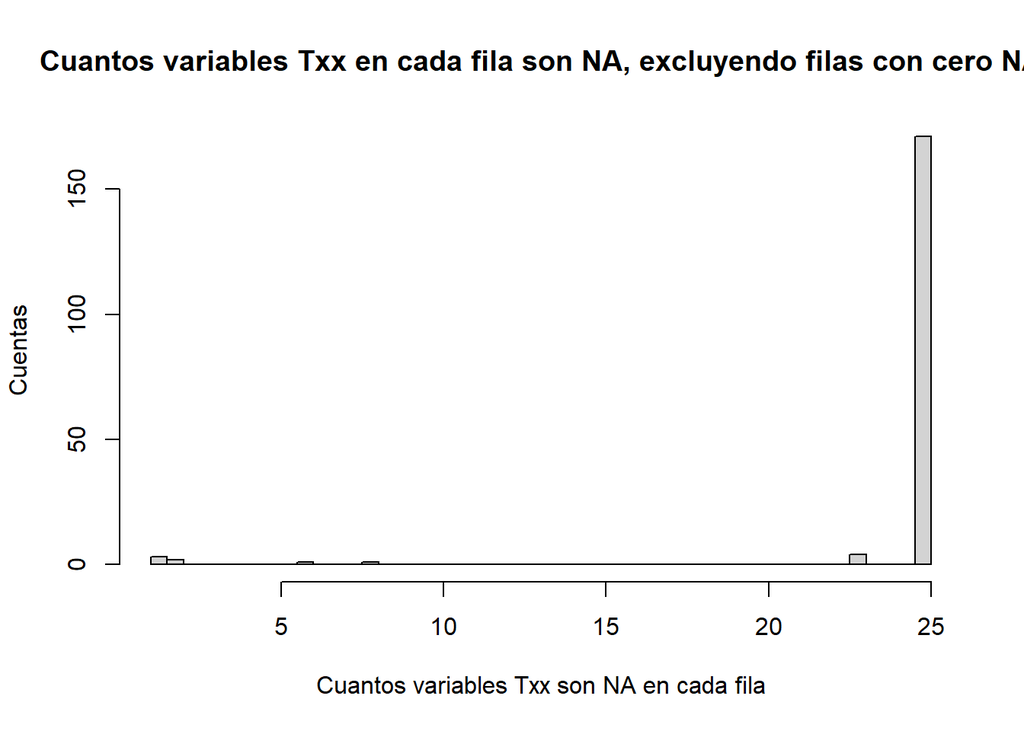

```r
# sweep by rows (margin = 1)
na_count_Txxs <- apply(data_cleaned_Txxs, MARGIN=1, count_nas_in_row)

# histogram count of NAs per row
# Note, zeros will be excluded because are "NA" instead from function above
hist(na_count_Txxs, breaks=50, xlab="Cuantos variables Txx son NA en cada fila", ylab="Cuentas", main="Cuantos variables Txx en cada fila son NA, excluyendo filas con cero NA")
```

Vemos que hay unos <22, y hay que repetir la función.

```r
data_cleaned_Txxs <- as.data.frame(t(apply(data_cleaned_Txxs, MARGIN=1, temp_inference)))
```

Ahora contamos los NAs de nuevo:

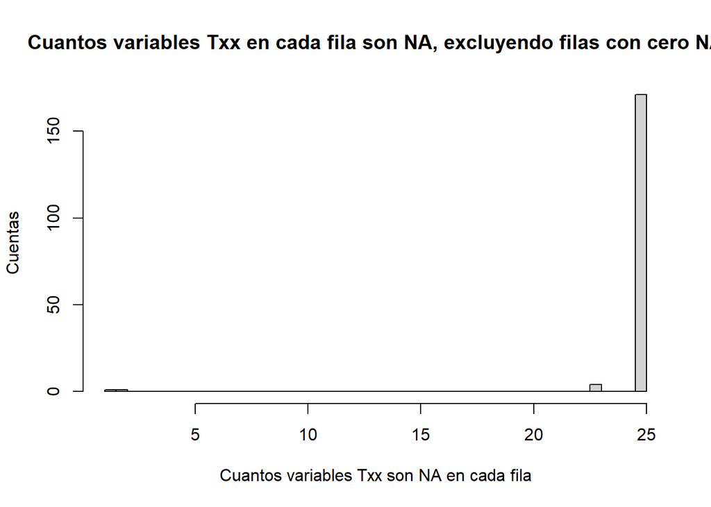

```r
# sweep by rows (margin = 1)
na_count_Txxs <- apply(data_cleaned_Txxs, MARGIN=1, count_nas_in_row)

# histogram count of NAs per row
# Note, zeros will be excluded because are "NA" instead from function above
hist(na_count_Txxs, breaks=50, xlab="Cuantos variables Txx son NA en cada fila", ylab="Cuentas", main="Cuantos variables Txx en cada fila son NA, excluyendo filas con cero NA")
```

Parece que hay unos pocos todavía, repetimos una segunda vez.

```r
data_cleaned_Txxs <- as.data.frame(t(apply(data_cleaned_Txxs, MARGIN=1, temp_inference)))
```

Ahora contamos los NAs de nuevo:

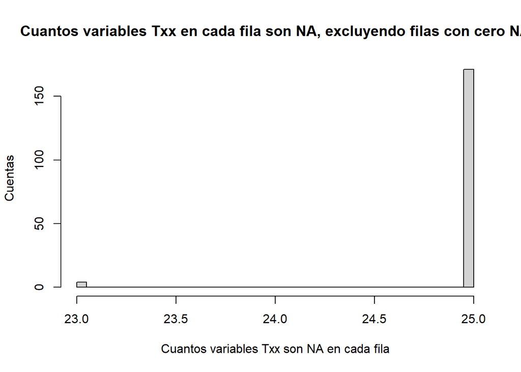

```r
# sweep by rows (margin = 1)
na_count_Txxs <- apply(data_cleaned_Txxs, MARGIN=1, count_nas_in_row)

# histogram count of NAs per row
# Note, zeros will be excluded because are "NA" instead from function above
hist(na_count_Txxs, breaks=50, xlab="Cuantos variables Txx son NA en cada fila", ylab="Cuentas", main="Cuantos variables Txx en cada fila son NA, excluyendo filas con cero NA")
```

Ahora, si, vemos que no tenemos más huecos sin tratar.